# Thesis: Safety perception in urban spaces, an ABM approach

Sara Cristina Herranz Amado

2025-06-19

```r
pacman::p_load(tidyverse, skimr, DataExplorer, labelled,
               stringr, dplyr, tidyr, forcats, haven,
               memisc, DataExplorer, caret, FactoMineR,
               factoextra, mice, missMDA, cowplot, cv,
               janitor, pdftools, Gifi, olsrr, car, MVN,
               sandwich, lmtest, boot, sf)
```

```r
# Survey and crime data
pamplona_spss <- as.data.frame(read_sav("23-085 - Ayuntamiento de Navarra (SPSS01).sav"))
```

# PAMPLONA SURVEY DATA

## Data cleaning and preprocessing

First, values such as `98`, `99`, and `999` in `pamplona_spss` represent missing responses and are converted to `NA` to standardize missing data representation.

```r
# Converting values 98 and 99 into NA
pamplona_spss[pamplona_spss == 98 | pamplona_spss == 99 | pamplona_spss == 999] <- NA
```

The Pamplona dataset, originally imported from SPSS, contains variables with labelled values. Labelled variables hold both numeric codes and descriptive labels, with codes representing categories (e.g., “1 = Male”, “2 = Female”). Using `mutate` with `across(where(is.labelled), ~ as_factor(.))`, these labelled variables are converted to R factors, allowing us to retain their descriptive labels. Converting labelled variables in this way ensures that categorical data is treated appropriately in analysis and allows for descriptive interpretation.

```r
# Convertir variables etiquetadas a factores con etiquetas descriptivas
pamplona <- pamplona_spss |>
  mutate(across(where(is.labelled),
                ~ as_factor(.)))
```

Converting all variable names to lowercase to ensure uniformity and reduce the risk of errors.

```r
# Converting variable names to lower case
names(pamplona) <- tolower(names(pamplona))
```

SPSS datasets often include additional metadata, such as variable labels or formatting attributes, which can clutter the R environment. To clean the dataset, I define a function, `remove_attributes`, which removes labels that contain the full survey question text and SPSS formatting metadata.

```r
# Removing unnecessary attributes from the variables (the description containing the question itself, keeping just the variable code)
remove_attributes <- function(df) {
  for (col in names(df)) {
    attr(df[[col]],
         "label") <- NULL
    attr(df[[col]],
         "format.spss") <- NULL
    # Mantener las etiquetas (labels)
  }
  return(df)
}

pamplona <- remove_attributes(pamplona)
```

To facilitate specific analyses, it may be necessary to work with numeric representations of categorical variables. The function `convert_to_numeric_factor` is applied to convert factor levels back into their original numeric codes. For each factor, the function reassigns levels to their numeric order, converting each level to a corresponding integer. This process is essential for analyses that require numeric input, such as regression models that operate on quantitative values rather than categorical labels.

```r
# Converting the variables to numeric factors, as in the original database, so we can work with the numeric values of the categories
convert_to_numeric_factor <- function(column) {
  if (is.factor(column)) {
    levels(column) <- as.character(1:length(levels(column)))
    factor(as.numeric(column))
  } else {
    column
  }
}

pamplona <- pamplona |>
  mutate(across(where(is.factor),
                convert_to_numeric_factor))

# in case i want to go back to the numeric values i just have to use themutate(across(where(is.labelled), ~ as_factor(.))), as at the beggining of this section
```

- **1** for individuals born in Spain (as represented by certain values in `p4`),
- **2** for individuals born outside Spain (identified by specific content in `p4_otros`),
- The numeric value of `p4` if neither of the above conditions is met.

Regarding `p17_otros`, values represented as `"-"` are converted to `NA`, enhancing data clarity by standardizing missing or irrelevant responses. Further investigation is warranted to assess the relationship between `p17_otros` and `p17`, particularly if `p17` is categorical. It may be necessary to reclassify `p17` to ensure alignment with the objectives of this analysis if additional granularity in response categories proves beneficial.

```r
# creating nP4
pamplona <- pamplona |>
  mutate(nationality = case_when(
           p4 %in% c(1, 2, 3) ~ 1,
           !is.na(p4_otros) & p4_otros != "-" ~ 2, #
           TRUE ~ as.numeric(as.character(p4))  # mantener otros valores P4 si hay
         ),
    p17_otros = na_if(p17_otros,
                      "-")) |> # convertir "-" en NA en p17_otros
  relocate(nationality,
           .before = p4)
```

## Feature selection

Feature selection is a crucial step in preparing the data for analysis. By selectively retaining relevant variables, I aim to reduce noise, improve interpretability, and enhance model performance. First, I remove specific columns from the dataset `pamplona`, variables that either provide redundant information or are not essential for the analysis, reducing dimensionality. Then, i rename columns aiming to improve clarity and readability, making it easier to interpret results.

```r
pamplona <- pamplona |>
  dplyr::select(-c("estudio",
                   "registro",
                   "p1",
                   "zona",
                   "p3_cod", # esto es rango de edad, a lo mejor me interesa.
                   "p4",
                   "p4_otros")) |>
  dplyr::rename(barrio = p1a,
                gender = p2,
                age = p3,
                employment = p20,
                education = p21,
                income = p22)
```

Then I convert each variable to its appropriate data type—binary, ordinal, categorical, or numeric—based on its nature. We convert binary variables to factors, allowing for easier interpretation, categorical encoding, and use in models that handle categorical data differently from continuous data.

First I check the levels of each variable using **`as.character(pamplona[[var]])`**, which converts each variable’s values to characters, ensuring that levels are shown as labels instead of factor levels. Then, by using **`paste(cat$categories, collapse = ", ")`** I combine categories into a comma-separated string for easy reading. This will output each variable name followed by its categories in a more readable, line-by-line format, like this:

```r
# Get unique categories for each variable in pamplona
categories <- lapply(names(pamplona), function(var) {
  unique_values <- unique(as.character(pamplona[[var]]))
  list(variable = var,
       categories = unique_values)
})

# Display the results in a cleaner format
for (cat in categories) {
  cat("\nVariable:", cat$variable, "\nCategories:", paste(cat$categories, collapse = ", "), "\n")
}
```

```
##
## Variable: barrio
## Categories: 5, 4, 3, 6, 10, 13, 8, 11, 9, 2, 1, 7, 12, 14
##
## Variable: gender
## Categories: 2, 1
##
## Variable: age
## Categories: 50, 54, 29, 40, 38, 59, 58, 75, 60, 89, 41, 31, 35, 79, 44, 42, 55, 76, 48, 47, 46, 51, 43, 66, 33, 82, 45, 53, 61, 74, 36, 56, 20, 52, 28, 26, 77, 23, 68, 39, 70, 49, 71, 37, 62, 67, 72, 86, 30, 85, 63, 34, 69, 57, 65, 22, 27, 24, 64, 73, 80, 81, 84, 83, 88, 78, 21, 87, 32, 25, 19, 9…
##
## Variable: nationality
## Categories: 1, 2
##
## Variable: p5_1
## Categories: 1, 2, NA
##
## Variable: p5_2
## Categories: 2, 1
##
## Variable: p5_3
## Categories: 2, 1
##
## Variable: p5_4
## Categories: 2, 1
##
## Variable: p5_5
## Categories: 2, NA, 1
##
## Variable: p5_6
## Categories: 2, 1, NA
##
## Variable: p5_7
## Categories: 1, 2
##
## Variable: p5_8
## Categories: 1, 2, NA
##
## Variable: p6_1
## Categories: 2, 1, NA
##
```

[output cut: 86 more lines]

```
##
## Variable: p18
## Categories: 2, 5, 6, 3, 4, 1, 7, NA
##
## Variable: p19
## Categories: 1, 4, 3, 2, 5, NA, 6
##
## Variable: employment
## Categories: 3, 6, 5, 2, 1, 8, 4, 7, NA
##
## Variable: education
## Categories: 5, 2, 4, 3, 1, NA
##
## Variable: income
## Categories: 5, 8, 3, 1, 7, 2, 4, 9, NA, 6, 10
```

Binary variables represent categories with only two options. Ordinal variables capture data on a ranked scale, and by converting them to ordered factors, I retain their hierarchical nature, which helps statistical methods recognize that certain values represent higher or lower positions in an ordered sequence. Categorical variables have distinct categories with no inherent ordering, and I convert these to nominal factors, ensuring that each category is treated as unique without implying a sequence. Variables representing quantities are converted to numeric type to enable accurate quantitative analysis. Numeric representation allows these variables to participate in arithmetic operations, summaries, and models that require continuous data.

```r
# Binary variables
binary_vars <- c("gender",
                 "nationality",
                 "p5_1", "p5_2", "p5_3",
                 "p5_4", "p5_5", "p5_6",
                 "p5_7", "p5_8",
                 "p6_1", "p6_2", "p6_3",
                 "p8",
                 "p9",
                 "p16")

pamplona[binary_vars] <- lapply(pamplona[binary_vars],
                                as.factor)

# Ordinal variables (trabajando con números)
ordinal_vars <- c("p7_1", "p7_2", "p7_3",
                  "p7_4", "p7_5", "p7_6",
                  "p7_7", "p7_8",
                  "p10_1", "p10_2", "p10_3",
                  "p10_4", "p10_5", "p10_6",
                  "p10_7",
                  "p12",
                  "p15",
                  "p19",
                  "education",
                  "income")

pamplona[ordinal_vars] <- lapply(pamplona[ordinal_vars],
                                 function(x) factor(x,
                                                    ordered = TRUE))

# Categorical variables
categorical_vars <- c("barrio",
                      "p13a", "p13b",
                      "p18",
                      "employment")

pamplona[categorical_vars] <- lapply(pamplona[categorical_vars],
                                     as.factor)

# Numeric variables
numeric_vars <- c("age",
                  "p11_1", "p11_2",
                  "p14")

pamplona[numeric_vars] <- lapply(pamplona[numeric_vars],
                                 as.numeric)
```

## Missing values

To assess the completeness and reliability of the dataset, we began by calculating the percentage of missing values for each variable. High levels of missing data can undermine the integrity of any statistical analysis, as they may introduce bias or diminish the power of inferential results. Thus, assessing missingness is a critical first step toward understanding which variables may be robust enough for reliable analysis.

Setting a threshold of 40% for missing values is a deliberate decision grounded in both statistical and practical considerations. Retaining variables with excessive missingness could skew insights or complicate downstream methods like imputation, which becomes increasingly challenging as missingness grows. The 40% threshold represents a balance between maximizing available data and ensuring that variables included in the analysis offer a meaningful representation of the underlying population. This cutoff is chosen to mitigate potential biases that high-missingness variables could introduce, ensuring a solid foundation for subsequent analyses.

By preemptively removing variables that exceed this threshold, we are upholding analytical rigor and setting a baseline for data quality, thereby reducing the likelihood of distorted or misleading results due to poor data coverage.

```r
# See % of missing values per variable
sapply(pamplona,
       function(x) sum(is.na(x))*100/nrow(pamplona))
```

```
##      barrio      gender         age nationality        p5_1        p5_2
##   0.0000000   0.0000000   0.1207729   0.0000000   0.1207729   0.0000000
##        p5_3        p5_4        p5_5        p5_6        p5_7        p5_8
##   0.0000000   0.0000000   0.6038647   0.2415459   0.0000000   0.2415459
##        p6_1        p6_2        p6_3        p7_1        p7_2        p7_3
##   0.1207729   0.0000000   0.0000000   0.1207729   6.1594203   1.2077295
##        p7_4        p7_5        p7_6        p7_7        p7_8          p8
##   5.7971014  17.8743961   4.1062802   1.5700483   6.5217391   0.7246377
##          p9       p10_1       p10_2       p10_3       p10_4       p10_5
##   0.2415459   3.7439614   3.1400966   3.3816425   2.0531401   0.9661836
##       p10_6       p10_7       p11_1       p11_2         p12        p13a
##   1.6908213  10.1449275   0.0000000   0.0000000   1.6908213  32.9710145
##        p13b         p14         p15         p16         p17   p17_otros
##  28.3816425   0.0000000   0.1207729   0.3623188  85.0241546  94.9275362
##         p18         p19  employment   education      income
##   0.8454106   2.1739130   0.1207729   0.2415459  24.2753623
```

```r
# Remove variables with more than 40% NA
pamplona <- pamplona |>
  dplyr::select(-c("p17",
                   "p17_otros"))
```

### Assessing CART with just one variable

To address missing values, I carefully considered the structure of the dataset, which includes binary, ordinal, categorical (with multiple categories), and discrete numerical variables. Imputation with a mix of variable types poses a unique challenge, as different imputation methods are typically better suited to specific variable types, and attempting to apply multiple methods simultaneously often resulted in errors. Many imputation methods require homogeneity in variable types to avoid incompatibility issues during processing.

I initially aimed to test at least two imputation methods for each type of variable to compare their performance. However, due to the variable diversity and associated errors, I ultimately opted for the CART (Classification and Regression Trees) method, implemented via the `mice` package, which can handle all variable types simultaneously. CART’s flexibility with categorical, ordinal, and numeric data simplifies the process without requiring separate treatment for each variable type, allowing me to sidestep the errors caused by mixing methods.

First, we isolate categorical variables in `pamplona` by excluding numeric columns. This step is crucial for later imputing missing values in these. Next, I use multiple imputation on `vars_cat`, focusing on the categorical variables `p18` and `p6_3`. The we do the same with the numerical variables and choose age for the multiple imputation. We use the `mice` package, which leverages “multiple imputations by chained equations,” appropriate for handling missing data systematically across variables. Setting `m = 2` creates two imputed datasets, and a fixed seed enhances reproducibility.

```r
# Select categorical variables (non-numeric) for imputation
vars_cat <- pamplona |> dplyr::select(-c(where(is.numeric)))

# Impute missing values for categorical variable 'p18' using CART method
mice_imputed_p18 <- data.frame(
  original = vars_cat$p18,
  imputed_cart = complete(mice(vars_cat,
                               m = 2,
                               method = "cart",
                               seed = 123))$p18)
# Impute missing values for dichotomous variable 'p6_3' using CART method
mice_imputed_p6_3 <- data.frame(
  original = vars_cat$p6_3,
  imputed_cart = complete(mice(vars_cat,
                               m = 2,
                               method = "cart",
                               seed = 123))$p6_3)
# Select numeric variables for imputation
vars_num <- pamplona |> dplyr::select(where(is.numeric))

# Impute missing values for numeric variable 'age' using CART method
mice_imputed_age <- data.frame(
  original = vars_num$age,
  imputed_cart = complete(mice(vars_num,
                               m = 2,
                               method = "cart",
                               seed = 123))$age)
# List of imputed data frames for each variable
imputed_data <- list(p18 = mice_imputed_p18,
                     p6_3 = mice_imputed_p6_3,
                     age = mice_imputed_age)
```

The following visualization step compares the distributions of the original and imputed values for each variable. By plotting, I aim to visually assess whether the CART imputation accurately reflects the original distribution’s shape and variability, helping validate the imputed results. This visual side-by-side layout provides an intuitive sense of how closely the imputed data aligns with the original, a step essential in determining whether the imputation effectively preserves the distributional properties of the original dataset. This comparison serves as a validation step, ensuring that the imputed values are not introducing systematic distortions or biases.

Attending the plot results, the CART imputation performs well across both categorical and continuous variables, preserving original distributions with minimal distortion, thus being a robust method for handling our missing data.

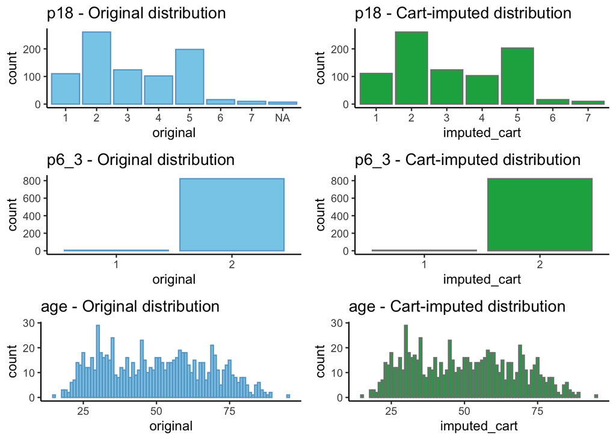

```r
# Define parameters for visual comparison of original vs. imputed data
variables <- c("original", "imputed_cart")
titles <- c("Original distribution", "Cart-imputed distribution")
colors_fill <- c("skyblue", "#15ad4f")
colors_border <- c("skyblue3", "#808080")

# Initialize an empty plot list
plots <- list()

# Loop through each variable and create the original and imputed plots
for (var_name in names(imputed_data)) {
  for (i in 1:2) {
    plot <- ggplot(imputed_data[[var_name]],
                   aes(x = .data[[variables[i]]])) +
      geom_bar(fill = colors_fill[i],
               color = colors_border[i],
               position = "identity") +
      ggtitle(paste(var_name, "-", titles[i])) +
      theme_classic()
    plots <- c(plots, list(plot))
  }
}

# Combine all six plots into a grid
plot_grid(plotlist = plots,
          nrow = 3,
          ncol = 2)
```

### Validating CART with cross-validation

To rigorously validate the imputation quality in this analysis, I implemented cross-validation specifically for the `mice` imputation process. Cross-validation is an essential tool in evaluating imputation methods, allowing me to observe how well the imputed values align with actual values in a controlled manner. By partitioning the data into training and test sets, cross-validation enables testing of imputed values against withheld data, providing an evidence-based assessment of imputation accuracy and robustness.

The function `cv_mice` takes the dataset, imputation method, and other parameters to apply a k-fold cross-validation process. Here, I use a 5-fold cross-validation (`n_folds = 5`) for a balanced approach that provides sufficient variability without over-splitting the data. Each fold serves as a test set in one iteration, while the remaining data acts as a training set for imputation. By setting a seed (`seed = 123`), I ensure that the fold splits are reproducible, maintaining consistency in the evaluation.

Inside each fold iteration, I perform the following steps:

1. **Data Splitting**: I partition the data into training (`train_data`) and test (`test_data`) sets based on the fold structure. Excluding the test set during imputation ensures that I can evaluate how well the method generalizes to unseen data, an essential aspect of imputation validation.
2. **Imputation on Training Data**: I apply `mice` to the training data only, using the specified `method` (in this case, “cart”). Here, I impute two versions of the data (`m = 2`), then select the first imputed dataset (`complete(imputed_train, 1)`) as the final training set for evaluation. Limiting to a single completed dataset keeps the process manageable while allowing multiple imputations to inform the model.
3. **Result Storage**: Each fold iteration outputs a list containing the fully imputed training data (`complete_train`) and the unaltered test data (`test_data`). This format provides the necessary data for comparing imputed and actual values in the test set without contaminating the test data with imputation artifacts, thereby preserving the validity of the evaluation.

After creating this cross-validation setup, I apply the function to the dataset `pamplona` using the `cart` method (`method = "cart"`). The result is a list of imputed and test datasets across the folds, which provides a comprehensive foundation for assessing the imputation quality of CART across different data segments.

In summary, this cross-validation approach helps ensure that the CART method is rigorously evaluated across various data splits. By systematically assessing imputation on independent subsets, I can ascertain the stability and generalizability of the method, thus strengthening the statistical reliability of the entire imputation process.

```r
# Function for cross-validation using MICE
cv_mice <- function(data, method, n_folds = 5, seed = 123) {
  set.seed(seed)
  folds <- createFolds(seq_len(nrow(data)),
                       k = n_folds)

  results <- lapply(folds, function(fold) {
    train_data <- data[-fold, ]
    test_data <- data[fold, ]

    imputed_train <- mice(train_data,
                          m = 2,
                          method = method,
                          seed = seed)
    complete_train <- complete(imputed_train,
                               1)  # Use the first imputed dataset

    list(train = complete_train,
         test = test_data)
  })

  results
}

# Apply cross-validation for `cart` method
cv_results_cart <- cv_mice(pamplona,
                           method = "cart")
```

After completing cross-validation on the imputed data, in order to compare the resulting distributions…

1. **Assess the consistency and reliability of the imputed values by comparing their distributions across the various folds.**

Since each fold in the cross-validation process represents a different subset of the data, this approach provides insight into how consistently CART performs under varying data conditions. A robust imputation method should yield similar distributions across folds, suggesting that the method generalizes well and is less sensitive to specific data partitions.

The imputed datasets from each fold, stored in `cv_results_cart`, are accessed with `lapply`, extracting the training data (`res$train`) for each fold. This extraction isolates the fully imputed datasets, ensuring that only the imputed training sets are compared, as the test data remains unaltered to maintain the integrity of cross-validation. By focusing on the training datasets, I am directly evaluating the consistency of the imputation process itself, rather than its interaction with withheld data.

Once the imputed datasets for each fold are extracted, I merge them into a single dataset (`combined_imputed_data`) using `do.call(rbind, ...)`. This combined dataset facilitates a unified analysis, allowing for a direct comparison of the distributions of imputed values across folds. By combining the data, I can leverage standard distributional checks (e.g., density plots, boxplots) or statistical tests to quantitatively and visually assess the consistency of imputed values.

The logic behind combining imputed values from each fold lies in assessing the imputation method’s stability across different training sets. If CART produces similar distributions across folds, it implies that the method captures the underlying patterns of the missing data effectively, regardless of data partitioning. Conversely, large variations might indicate sensitivity to specific data subsets, suggesting potential instability or limitations of the method.

By organizing the imputed values this way, I set a strong foundation for statistically validating the imputation method’s performance, thus ensuring that the chosen approach is both reliable and reproducible across different data segments.

```r
# Extract imputed values from each fold
imputed_datasets <- lapply(cv_results_cart,
                           function(res) res$train)

# Combine imputed data into one data frame for analysis
  # Note: Ensure the imputed datasets have the same structure
combined_imputed_data <- do.call(rbind,
                                 imputed_datasets)
```

2. **Calculate Variability Across Imputed Values**

Assessing variability is essential because it provides insight into how stable the imputed values are under varying data conditions. To rigorously evaluate the consistency of the imputed values across folds, I employ different metrics tailored to numeric and categorical variables. For a robust imputation method, we expect minimal variability across folds, suggesting that the imputed values are not overly influenced by the data partitioning in cross-validation.

For **numeric variables** the consistency of imputed values across folds is evaluated by calculating summary statistics, specifically the mean and standard deviation, which help to identify if imputed values exhibit stability across folds.

The function `analyze_variability` targets a specific variable (`variable_name`) in `combined_imputed_data`, which contains all imputed values across folds. The mean (`mean_value`) and standard deviation (`sd_value`) are computed for the selected variable, ignoring missing values with `na.rm = TRUE`. The mean provides an average imputed value, while the standard deviation quantifies the spread, indicating how much the imputed values fluctuate across folds. Consistent imputation would yield a small standard deviation, implying that the imputed values converge around a stable mean across different folds.

Then, we compare the mean and standard deviation of `age` in the original and imputed datasets. The imputed values are close to the original statistics, suggesting that the imputation method has maintained the underlying distribution characteristics effectively.

```r
# Analyzing variability for a specific variable
analyze_variability <- function(original_data, imputed_data, variable_name) {
  # Extract the specific variable in both original and imputed datasets
  original_values <- original_data[[variable_name]]
  imputed_values <- imputed_data[[variable_name]]

  # Calculate mean and standard deviation for original data
  original_mean <- mean(original_values,
                        na.rm = TRUE)
  original_sd <- sd(original_values,
                    na.rm = TRUE)

  # Calculate mean and standard deviation for imputed data
  imputed_mean <- mean(imputed_values,
                       na.rm = TRUE)
  imputed_sd <- sd(imputed_values,
                   na.rm = TRUE)

  # Return both original and imputed statistics for comparison
  list(original = list(mean = original_mean,
                       sd = original_sd),
       imputed = list(mean = imputed_mean,
                      sd = imputed_sd))
}

# Analyzing variability for the "age" variable as an example
variability_age <- analyze_variability(pamplona,
                                       combined_imputed_data, "age")
print(variability_age)
```

```
## $original
## $original$mean
## [1] 49.99879
##
## $original$sd
## [1] 17.698
##
##
## $imputed
## $imputed$mean
## [1] 50.0314
##
## $imputed$sd
## [1] 17.7059
```

For **categorical variables**, variability is assessed by examining frequency distributions. In `compare_frequency_distributions`, I generate normalized frequency tables (proportions) for both the original and imputed data for each category of `variable_name`. This normalization facilitates direct comparison by ensuring that both distributions are on the same scale, regardless of the absolute number of observations. Then, by comparing the proportions, I can visually and numerically assess how closely the imputed distributions align with the original ones. Variable “p18” exhibits similar distributions in both original and imputed data, sugggesting that CART, again, is effectively capturing and replicating the original distribution patterns.

```r
# Function to calculate and compare frequency distributions
compare_frequency_distributions <- function(original_data, imputed_data, variable_name) {
  # Frequency table for original data
  original_freq <- table(original_data[[variable_name]],
                         useNA = "ifany")
  original_freq <- original_freq / sum(original_freq)  # Convert to proportions

  # Frequency table for imputed data
  imputed_freq <- table(imputed_data[[variable_name]],
                        useNA = "ifany")
  imputed_freq <- imputed_freq / sum(imputed_freq)  # Convert to proportions

  list(original = original_freq,
       imputed = imputed_freq)
}

# Example for variable "p18" which is categorical
freq_distributions_p18 <- compare_frequency_distributions(pamplona,
                                                          combined_imputed_data,
                                                          "p18")
print(freq_distributions_p18)
```

```
## $original
##
##           1           2           3           4           5           6
## 0.132850242 0.315217391 0.149758454 0.123188406 0.239130435 0.019323671
##           7        <NA>
## 0.012077295 0.008454106
##
## $imputed
##
##          1          2          3          4          5          6          7
## 0.13375604 0.31763285 0.15157005 0.12469807 0.24064010 0.01932367 0.01237923
```

3. **Visualize Distribution of Imputed Values to see if there are any significant differences across folds.**

To thoroughly assess the quality of the imputed values, I visualize the normalized distributions for both numeric and categorical variables, comparing these distributions within the imputed dataset and against the original data. By doing this, I get to detect any significant deviations or inconsistencies, which helps validate the imputation method’s effectiveness in preserving the original data’s characteristics.

For **numeric variables**, the function `plot_imputed_distribution_normalized` takes the imputed dataset (`imputed_data`) and a specified variable (`variable_name`) and plots its density-normalized distribution using a histogram. By normalizing to density (`..density..`), I focus on the distribution shape rather than the frequency, allowing a clear comparison of spread and central tendency across imputed values.

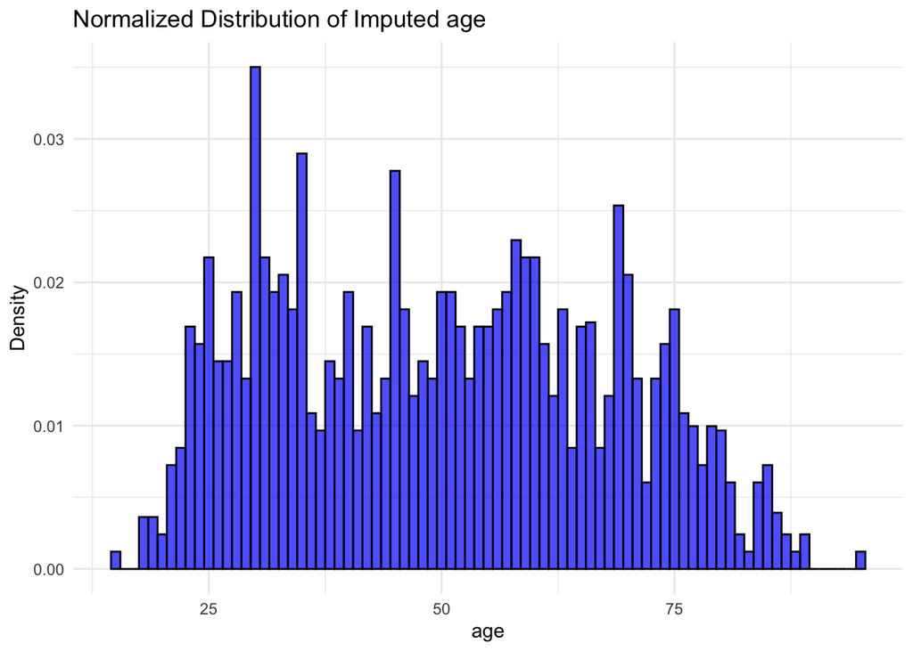

```r
# Visualize normalized distribution of imputed values for a specific variable
plot_imputed_distribution_normalized <- function(imputed_data, variable_name) {
  ggplot(imputed_data, aes_string(x = variable_name)) +
    geom_histogram(aes(y = ..density..),  # Use density for normalization
                   binwidth = 1,
                   fill = "blue",
                   color = "black",
                   alpha = 0.7) +
    labs(title = paste("Normalized Distribution of Imputed",
                       variable_name),
         x = variable_name,
         y = "Density") +
    theme_minimal()
}

# Plot for the "age" variable as an example
plot_imputed_distribution_normalized(combined_imputed_data,
                                     "age")
```

I use `compare_original_imputed_normalized` to plot overlapping histograms for the original and imputed datasets, so I can evaluate whether the imputed values accurately reflect the original data. Normalizing both distributions ensures that differences in sample sizes do not skew the comparison, providing a visual representation of how closely the imputed values replicate the original data distribution.

Attending to the results of the plot, the distributions of both the original data and the imputed one is almost the same, with slight differences, indicating that CART effectively preserves statistical characteristics of the data.

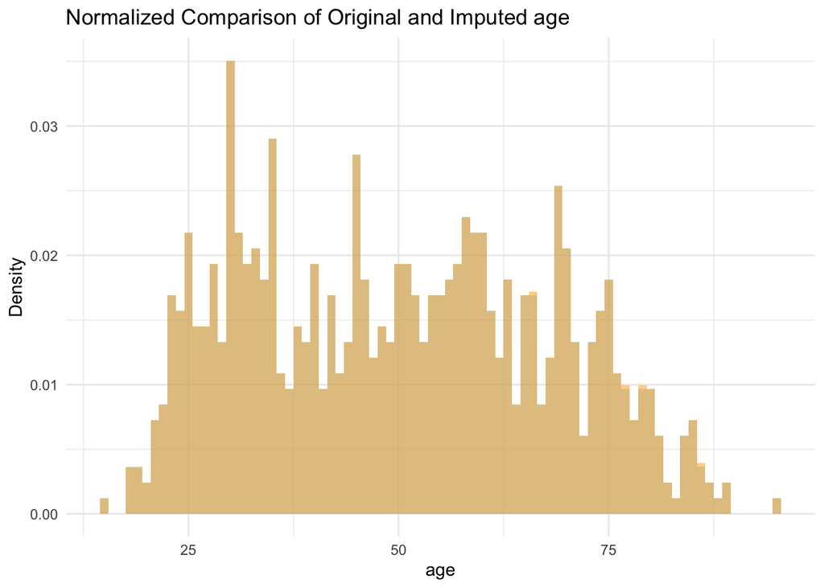

```r
# Compare original vs imputed data for a variable with normalized values
compare_original_imputed_normalized <- function(original_data, imputed_data, variable_name) {
  original_values <- original_data[[variable_name]]
  imputed_values <- imputed_data[[variable_name]]

  # Plot comparison using density for normalization
  ggplot() +
    geom_histogram(aes(x = original_values,
                       y = ..density..),
                   fill = "skyblue",
                   alpha = 0.5,
                   binwidth = 1) +
    geom_histogram(aes(x = imputed_values,
                       y = ..density..),
                   fill = "orange",
                   alpha = 0.5,
                   binwidth = 1) +
    labs(title = paste("Normalized Comparison of Original and Imputed",
                       variable_name),
         x = variable_name,
         y = "Density") +
    theme_minimal()
}

# Comparing for the "age" variable as an example
compare_original_imputed_normalized(pamplona,
                                    combined_imputed_data,
                                    "age")
```

For **categorical variables**, as they lack numerical spread, I compare proportional frequency distributions. The function `plot_categorical_distribution_normalized` calculates the normalized frequency (proportion) of each category in both the original and imputed datasets, converting these counts to proportions and allowing for direct comparison, removing any bias from different sample sizes. The bar plot then overlays the proportions of categories in both the original and imputed datasets, facilitating a side-by-side comparison. Once again, the imputed distribution mirrors the original distribution, so the imputation bias is minimal.

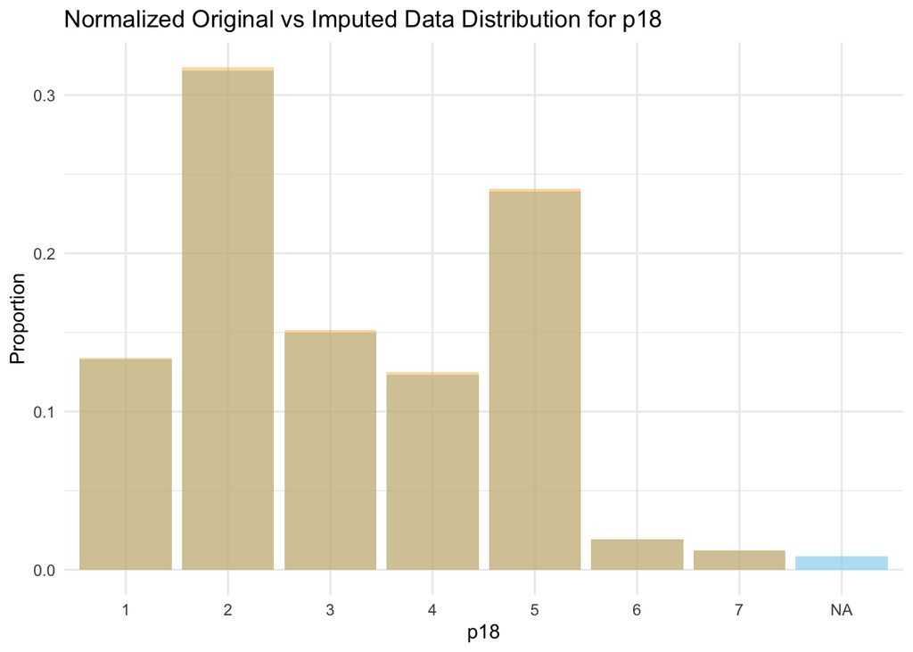

```r
# Normalize the frequency counts to proportions
plot_categorical_distribution_normalized <- function(original_data, imputed_data, variable_name) {
  # Frequency tables
  original_freq <- table(original_data[[variable_name]],
                         useNA = "ifany")
  imputed_freq <- table(imputed_data[[variable_name]],
                        useNA = "ifany")

  # Convert to data frames for ggplot
  original_df <- as.data.frame(prop.table(original_freq))
  imputed_df <- as.data.frame(prop.table(imputed_freq))
  colnames(original_df) <- c("Category",
                             "Proportion")
  colnames(imputed_df) <- c("Category",
                            "Proportion")

  # Plotting
  ggplot() +
    geom_bar(data = original_df,
             aes(x = Category,
                 y = Proportion),
             stat = "identity",
             fill = "skyblue",
             alpha = 0.6) +
    geom_bar(data = imputed_df,
             aes(x = Category,
                 y = Proportion),
             stat = "identity",
             fill = "orange",
             alpha = 0.4) +
    labs(title = paste("Normalized Original vs Imputed Data Distribution for",
                       variable_name),
         x = variable_name,
         y = "Proportion") +
    theme_minimal()
}

# Plot for the "p18" variable
plot_categorical_distribution_normalized(pamplona,
                                         combined_imputed_data,
                                         "p18")
```

4. **Imputation of missing values with CART**

Cross-validation helped validate that the CART method effectively preserved the original distribution’s characteristics, both for numeric and categorical variables. Given this initial validation, I now apply CART imputation to the full dataset, treating the missing values directly and creating a complete, imputed dataset.

The `mice` function applies CART-based imputation across all variables in the dataset with missing values. Specifying `m = 2` creates two imputed versions, while `complete(imputed_data, 1)` extracts one of these versions as the final complete dataset (`pamplonaf`). The `seed = 123` ensures reproducibility, so the imputed values remain consistent across runs.

```r
# Imputing based on cart
pamplonaf <- complete(mice(pamplona,
                           m = 2,
                           method = "cart",
                           seed = 123))
```

# Exploratory analysis

## Descriptive analysis function

Univariate descriptive analysis is essential as a first approach before any type of modeling, as it provides foundational insights by summarizing each variable independently, allowing us to examine the distribution, central tendency, and spread of each variable. This analysis is conducted separately for all variables in the dataset, and is structured to generate statistical summaries and visualizations for both numerical and categorical variables.

I defined a function, `univariate analysis`, to automate this process, adapting to both numeric and categorical variables, with tailored summaries and visualizations for each type:

If a variable type is unrecognized, the function displays a message, ensuring that all potential issues with variable types are flagged without interrupting the analysis.

```r
# Function to generate univariate analysis
univariate_analysis <- function(data) {
  for (col in colnames(data)) {
   cat("Analysis for", col, "\n")
    # Check if the column is numeric
    if (is.numeric(data[[col]])) {
      summary_stats <- summary(data[[col]])
      print(summary_stats)

      # Set binwidth based on the variable
      if (col == "age") {
        bin_width <- 5  # Adjust bin width for the 'age' variable
      } else {
        num_unique_values <- length(unique(data[[col]]))
        bin_width <- ifelse(num_unique_values <= 10, 1, 30 / num_unique_values)
      }

      # Plot histogram
      p <- ggplot(data, aes_string(x = col)) +
        geom_histogram(binwidth = bin_width,
                       fill = "blue",
                       color = "black") +
        theme_minimal() +
        labs(title = paste("Histogram of", col),
             x = col,
             y = "Frequency")
      print(p)

    } else if (is.factor(data[[col]]) || is.character(data[[col]])) {
      # Convert character to factor if necessary
      data[[col]] <- as.factor(data[[col]])

      # Frequency table
      freq_table <- table(data[[col]])
      print(freq_table)

      # Plot bar chart
      p <- ggplot(data, aes_string(x = col)) +
        geom_bar(fill = "blue") +
        theme_minimal() +
        labs(title = paste("Bar Plot of", col),
             x = col,
             y = "Count")
      print(p)

    } else {
      cat("Variable type not recognized or not supported.\n")
    }
    cat("\n\n")
  }
}
```

Instead of applying the function to the whole dataset at the same time, specific subsets of variables are analyzed to focus on particular themes within the dataset. This allows for an organized examination of conceptually related variables.

# Feature engineering

## Building the crime index

To account for not just the frequency but the *severity* of different types of offences reported in Pamplona, I constructed a **Crime Severity Index (CSI)**. This approach draws inspiration from internationally recognized indices, such as the **Canadian Crime Severity Index** (Statistics Canada, 2022) and the **Cambridge Crime Harm Index** (Sherman et al., 2016). These models use judicial sentencing guidelines as proxies for crime seriousness, under the rationale that **the more severe the punishment assigned by courts, the greater the societal harm attributed to the offence**.

The construction of this Crime Severity Index also draws from the foundational work of **Sellin and Wolfgang**, who emphasized the importance of assigning **ratio-scaled seriousness weights** to criminal events (Sellin & Wolfgang, 1964). Unlike approaches that classify only the most serious offence within a criminal event, their method allows each component of the event to be weighted and summed, preserving the **cumulative impact of crime**. This framework assumes that an offence with twice the weight reflects a crime twice as serious, enabling more accurate scaling. Moreover, seriousness was not viewed as a fixed legal classification but as a **measurable dimension based on social harm**, typically assessed via representative judgments or empirical proxies such as sentencing guidelines.

Given that individual sentencing data is not available for the context of Pamplona, the index is constructed using **legal sentencing ranges** from the Spanish Penal Code. This provides a principled way to estimate crime severity weights even in the absence of empirical conviction data.

```r
delitos <- pdf_text("PDF/BALANCE-CRIMINALIDAD-CUARTO-TRIMESTRE-2024.pdf")[468]
```

```r
# Cleaning crime data
lines <- strsplit(delitos,
                  "\n")[[1]]

lines <- lines[lines != "" & !grepl("^\\s+$",
                                    lines)]
split_lines <- strsplit(lines,
                        "\\s{2,}")

data <- do.call(rbind,
                split_lines[7:length(split_lines)])
delitos <- data.frame(data[, c(2, 3)])
colnames(delitos) <- c("tipo_penal", "n")


delitosf <- delitos |>
  mutate(tipo_penal = str_remove(tipo_penal,
                                 "^\\d+\\.\\s*-?\\s*"),
         year = "2023") |>
  filter(!tipo_penal %in% c("Municipio de Pamplona/Iruña",
                            "TIPOLOGÍA PENAL",
                            "I. CRIMINALIDAD CONVENCIONAL",
                            "II. CIBERCRIMINALIDAD (infracciones penales cometidas en/por medio ciber)",
                            "Estafas informáticas",
                            "Otros ciberdelitos",
                            "III. TOTAL CRIMINALIDAD"),
         !str_detect(tipo_penal,
                     "^(5\\.1|5\\.2|7\\.1)\\.-"),
         !str_detect(tipo_penal,
                     "[0-9].*[A-Za-z]|[A-Za-z].*[0-9]"),
         !str_detect(n,
                     "[A-Za-z]"),
         !n == "0") |>


  mutate(n = as.numeric(str_replace_all(n,
                                        "[,\\.]", "")))|>
  group_by(tipo_penal) |>
  summarise(n = sum(n,
                    na.rm = TRUE),
            .groups = 'drop') |>
  mutate(year = 2023)
```

### Weighting strategy

#### Developing midpoint approach

For each offence, I consulted the Penal Code to identify the minimum and maximum **prison sentences**, or the **financial penalty range** (*multas*) where applicable. To estimate the expected sentence, I used the **midpoint approach**, which provides an approximation of the typical judicial response to each offense and is a standard technique in the absence of distributional data (e.g., StatCan, 2024):

$$\text{Expected
Sentence}=\frac{\text{Minimum Sentence +
Maximum Sentence}}{2}$$

To compare fines with prison terms, we assume **relative harm equivalence**, inspired by the Cambridge model: a **1-month prison sentence** is treated as more severe than a **1-month fine**. However, to maintain scale comparability, fines are assigned **lower weights** across the board.

#### Computing weights

Now, divide each **expected sentence length** by **0.25** (reference crime):

$$wi=\frac{\text{Expected Sentence Length
for Offence } i}{0.25 \text{ years}}$$

[output not shown]

```r
# Harm-adjusted fine conversion factor
fine_factor <- 0.25

# Function to compute expected severity
weighted_severity <- function(prison_min, prison_max, fine_min = NA, fine_max = NA, fine_weight = 0.6, prison_weight = 0.4) {
  prison_mid <- (prison_min + prison_max) / 2
  fine_mid <- if (!is.na(fine_min) && !is.na(fine_max)) (fine_min + fine_max) / 2 else 0

  fine_adjusted <- fine_mid * fine_factor

  expected <- fine_weight * fine_adjusted + prison_weight * prison_mid
  return(expected)
}

# Compute weights relative to reference (0.25 years)
reference_sentence <- 0.25

# Apply to mixed-sentence crimes
lesiones_expected <- weighted_severity(prison_min = 0.25, prison_max = 1,
                                       fine_min = 0.5, fine_max = 2)  # fine in years

hurtos_expected <- weighted_severity(prison_min = 0.5, prison_max = 1.5,
                                     fine_min = 1/12, fine_max = 3/12)  # months to years

# Compute weights
lesiones_weight <- lesiones_expected / reference_sentence
hurtos_weight <- hurtos_expected / reference_sentence
```

```r
ponderaciones <- c(
  "Homicidios dolosos y asesinatos consumados" = 50,
  "Homicidios dolosos y asesinatos en grado tentativa" = 80,
  "Delitos graves y menos graves de lesiones y riña tumultuaria" = lesiones_weight,
  "Delitos contra la libertad sexual" = 10,
  "Robos con violencia e intimidación" = 14,
  "Robos con fuerza en domicilios, establecimientos y otras instalaciones" = 8,
  "Hurtos" = hurtos_weight,
  "Sustracciones de vehículos" = 1.3,
  "Tráfico de drogas" = 18,
  "Resto de criminalidad CONVENCIONAL" = 0.25
)
```

Now, these **weights** can be used to compute the **Crime Severity Index (CSI)** by using the standard formula and applying the weights to the relative values of the crimes:

```r
# Apply the weights to the relative values of the crimes:
crime <- delitosf %>%
  mutate(n = as.numeric(n))   |>
  mutate(total_n = sum(n, na.rm = TRUE),
    num_relativo = n / total_n,  # getting relative number
    ponderacion = num_relativo * ponderaciones[tipo_penal]) |>
  # applying weights
    summarise(crime_index = sum(ponderacion))
```

Finally, we add the resulting index to our `pamplona` database.

```r
# Extract crime index value
crime_value <- crime$crime_index[1]

# Add the crime_index column to pamplonaf
pamplonaf <- pamplonaf %>%
  mutate(crime_index = crime_value)
```

—…—-…—…—-

### Problema

NOTA: aunque no se pueda hacer por barrios por los crímenes, sí que podríamos hacer un índice general para todo pamplona de criminalidad, pero luego hacer el safety perception diferente para cada barrio. por qué sería diferente? aparte de porque varía por barrio, porque podríamos usar self defense strategies de forma diferente en función del barrio que diga cada persona (una persona suele pensar más en lo que conoce cuando se le pregunta por lo que tiene miedo que no. bueno esto me lo acabo de inventar pero si busco literatura seguro que hay algo que diga algo así).

[figure not shown]

https://www.statista.com/statistics/525603/crime-severity-index-in-canada/#:~:text=In%20the%20calculation%20of%20the,on%20changes%20in%20the%20index. The Crime Severity Index (CSI) takes into account both the volume and the seriousness of crime. In the calculation of the CSI, each offence is assigned a weight, derived from average sentences handed down by criminal courts. The more serious the average sentence, the higher the weight for that offence. As a result, more serious offences have a greater impact on changes in the index. All police-reported Criminal Code offences are included in the CSI. Adapted from Statistics Canada, statcan.gc.ca, 2001 to 2022. This does not constitute an endorsement by Statistics Canada of this product.

https://www150.statcan.gc.ca/n1/daily-quotidien/240725/dq240725b-eng.htm?indid=4751-1&indgeo=0 To determine severity, each crime is assigned a weight. CSI weights are based on the crime’s incarceration rate, as well as the average length of prison sentences handed down by criminal courts. More serious crimes are assigned higher weights, while less serious crimes are assigned lower weights. As a result, relative to their volume, more serious crimes have a greater impact on the index.

## Past victimisation

Due to a significant class imbalance in the data, I created a synthetic index to capture whether any form of victimization has ever occurred.

```r
pvictimisation_vars  <- pamplonaf |>
  dplyr::select(p5_1, p5_2, p5_3,
                p5_4, p5_5, p5_6,
                p5_7, p5_8,
                p6_1, p6_2, p6_3)

# Descriptive analysis
univariate_analysis(pvictimisation_vars)
```

```
## Analysis for p5_1
##
##   1   2
##  40 788
```

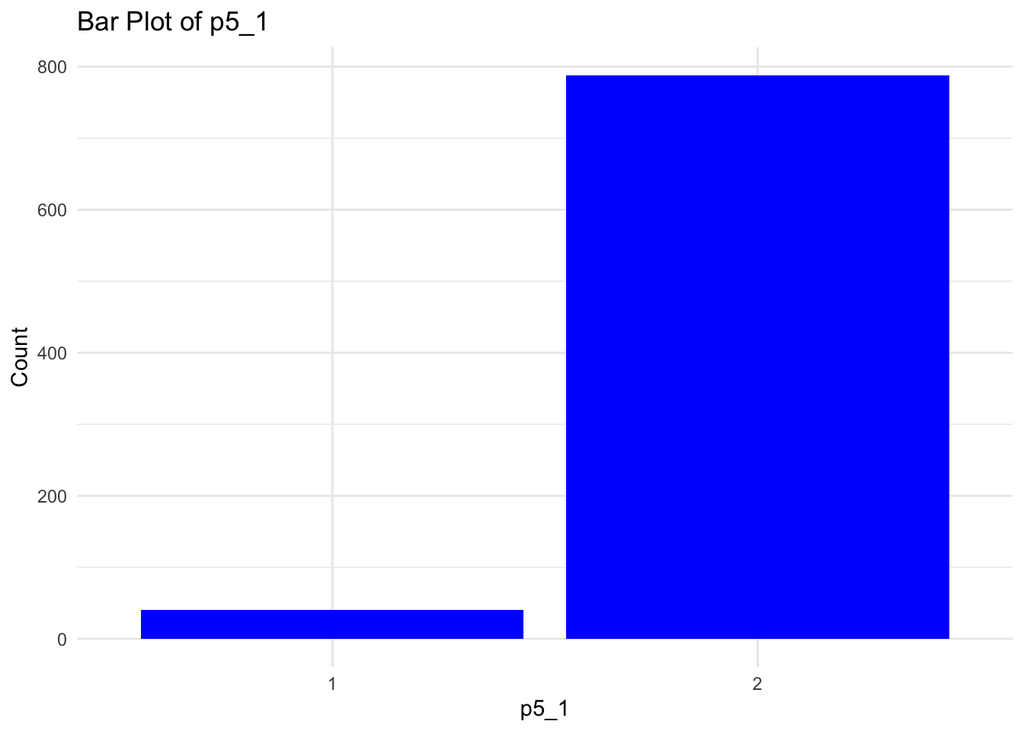

```
##
##
## Analysis for p5_2
##
##   1   2
##  10 818
```

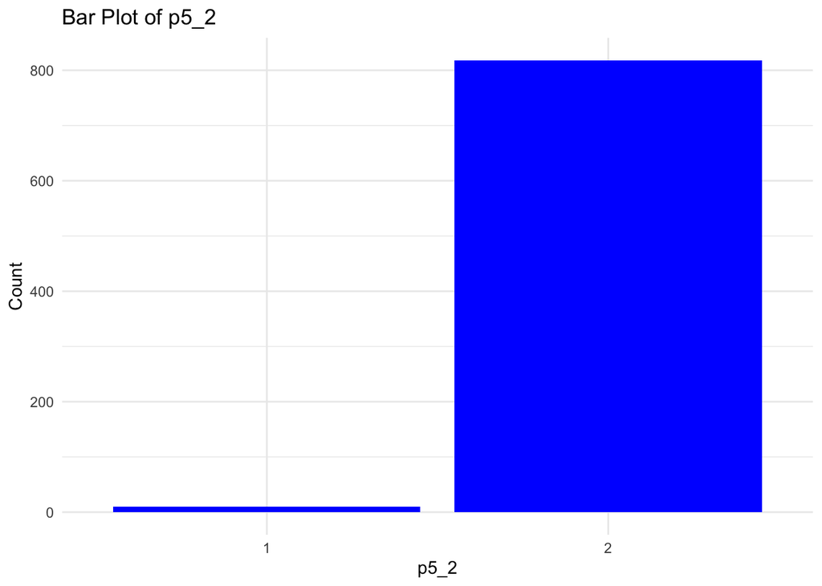

```
##
##
## Analysis for p5_3
##
##   1   2
##   7 821
```

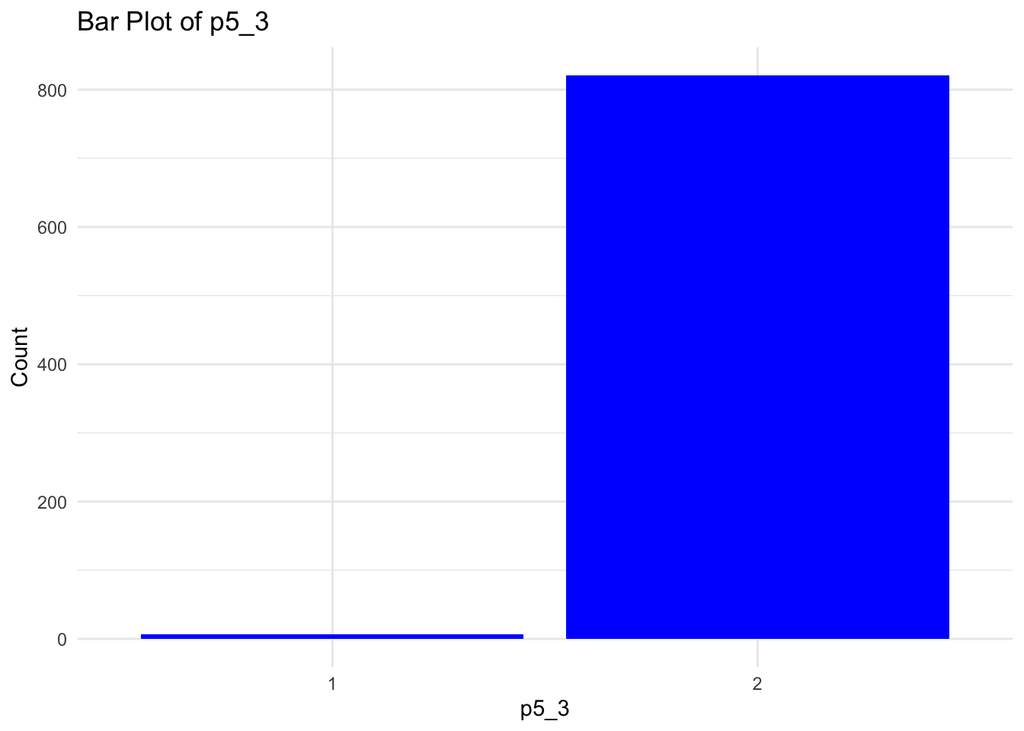

```
##
##
## Analysis for p5_4
##
##   1   2
##  14 814
```

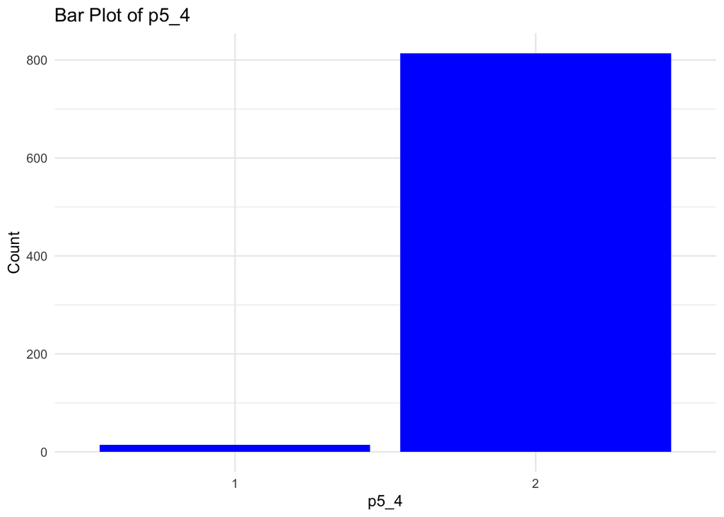

```
##
##
## Analysis for p5_5
##
##   1   2
##  23 805
```

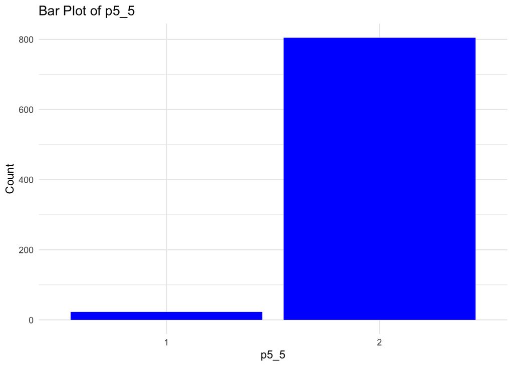

```
##
##
## Analysis for p5_6
##
##   1   2
##  29 799
```

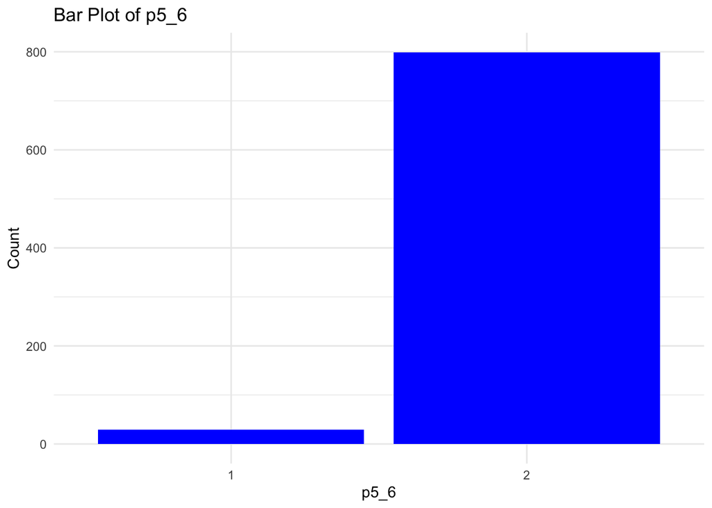

```
##
##
## Analysis for p5_7
##
##   1   2
##  12 816
```

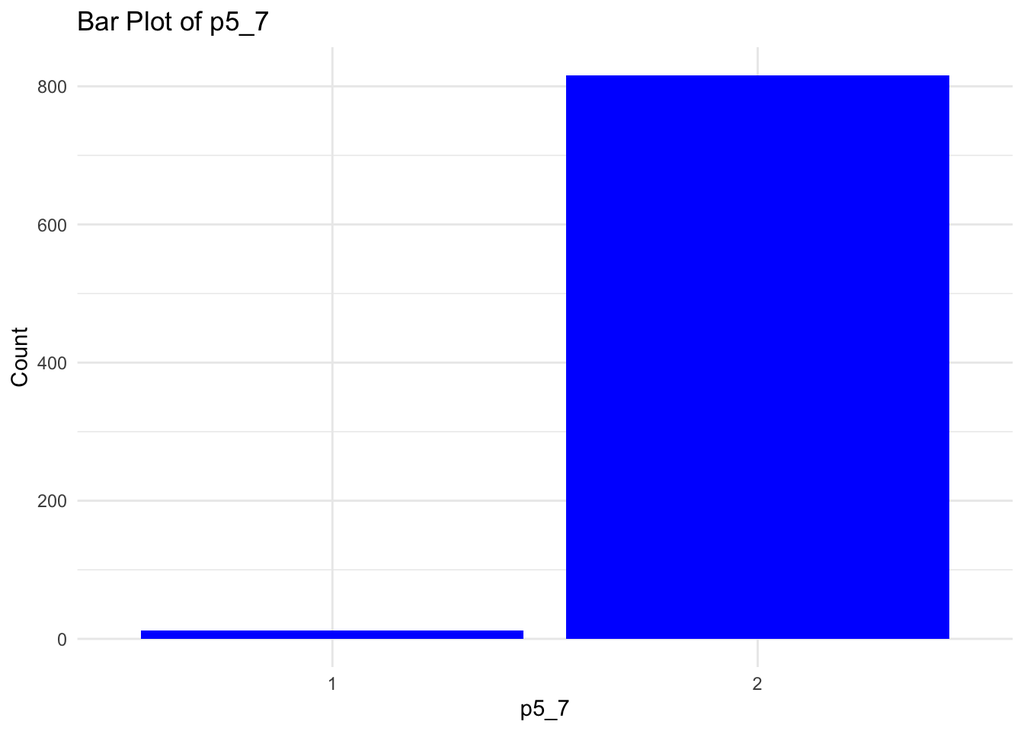

```
##
##
## Analysis for p5_8
##
##   1   2
##  71 757
```

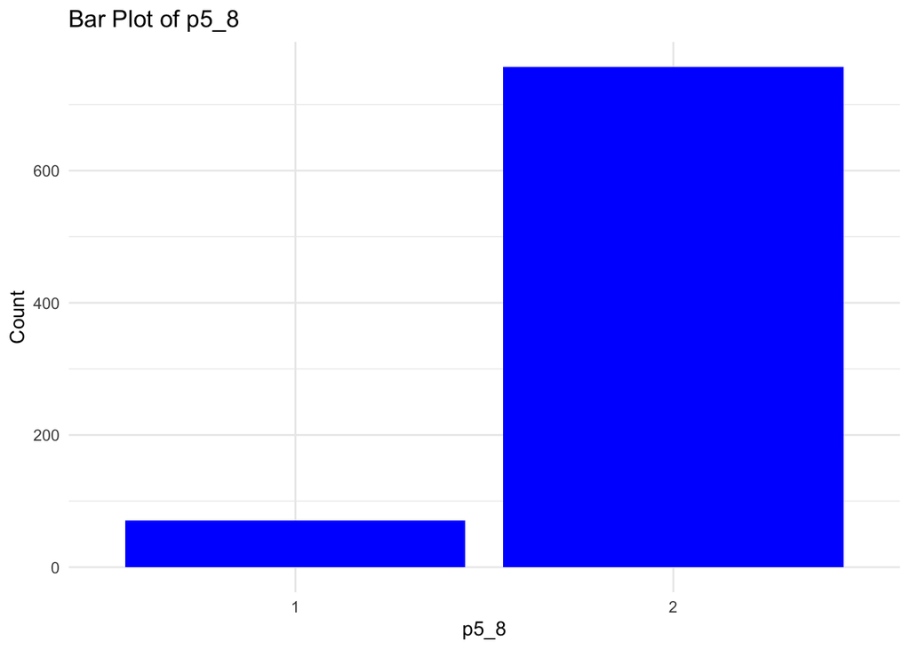

```
##
##
## Analysis for p6_1
##
##   1   2
##  14 814
```

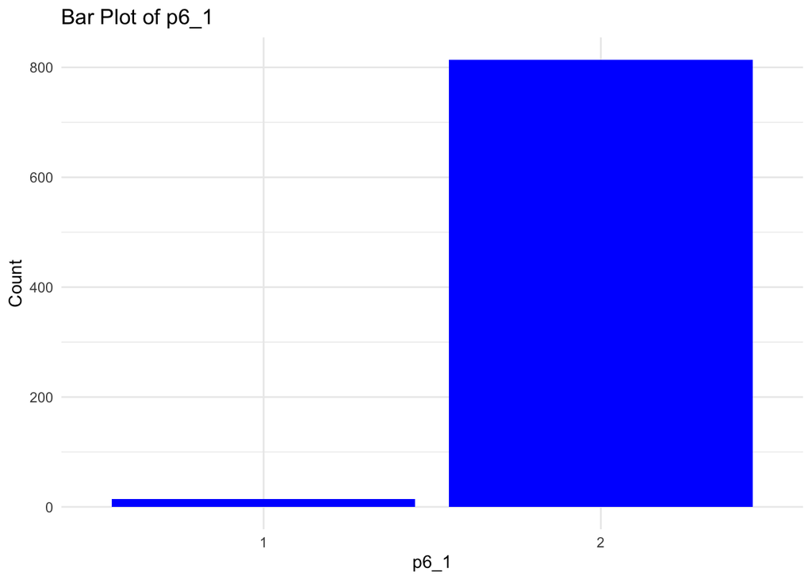

```
##
##
## Analysis for p6_2
##
##   1   2
##  52 776
```

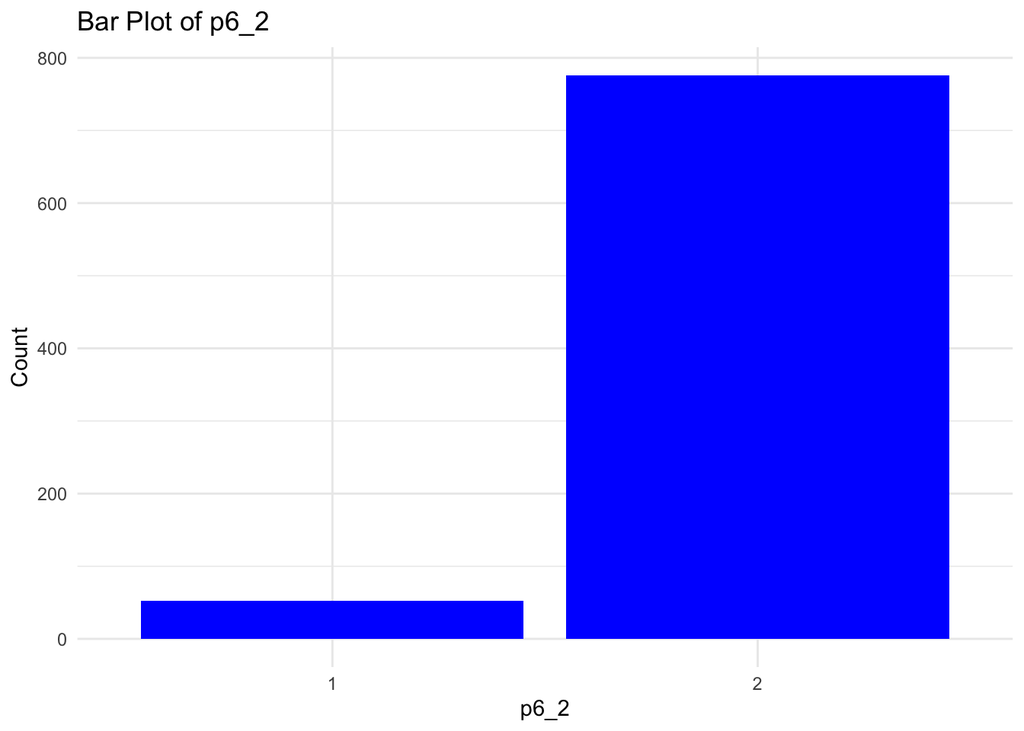

```
##
##
## Analysis for p6_3
##
##   1   2
##   6 822
```

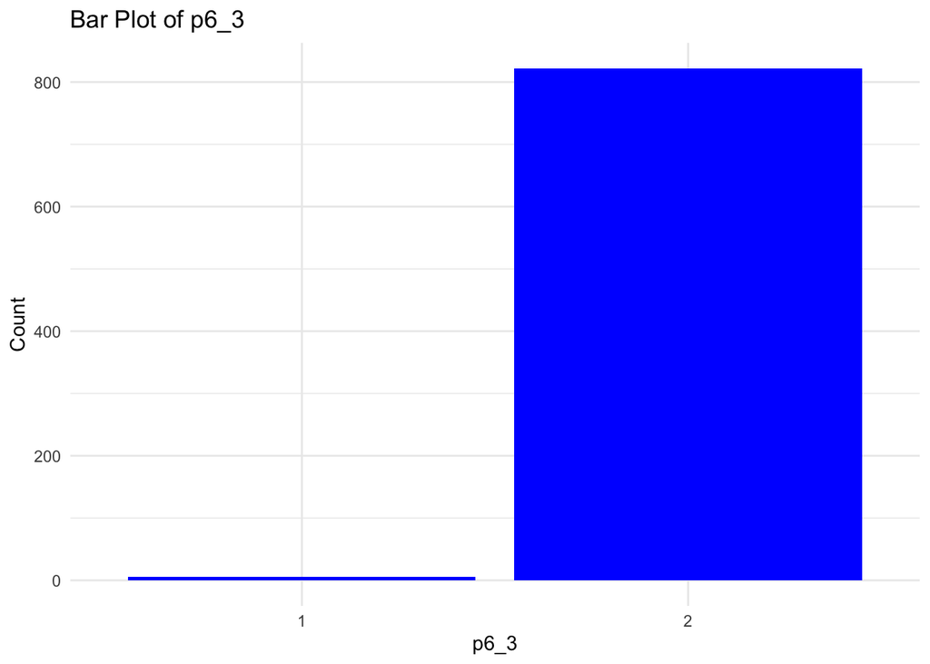

```r
pvictimisation_vars[] <- lapply(pvictimisation_vars,
                                function(x) as.numeric(as.character(x)))

names(pvictimisation_vars)
```

```
##  [1] "p5_1" "p5_2" "p5_3" "p5_4" "p5_5" "p5_6" "p5_7" "p5_8" "p6_1" "p6_2"
## [11] "p6_3"
```

```r
# Apply the recoding: change 1 (Yes) to 1 and 2 (No) to 0 in pvictimisation_vars
pvictimisation_vars[] <- lapply(pvictimisation_vars,
                                function(x) ifelse(x == 1, 1, 0))

# Synthetic index (unweighted): 1 if at least one victimisation reported, 0 if none
pvictimisation_vars$victimized <- ifelse(rowSums(pvictimisation_vars[],
                                                 na.rm = TRUE) > 0, 1, 0)

# Display frequency table of the victimization index
table(pvictimisation_vars$victimized)
```

```
##
##   0   1
## 644 184
```

Although the original approach involved a simple binary indicator distinguishing between individuals who had or had not experienced victimization, I opted for a more nuanced method: constructing a **weighted victimization index** that reflects not only the presence but also the **severity of the offenses**. Each type of past victimization was assigned a weight based on its relative seriousness, following approximate sentencing guidelines from the Spanish Penal Code. For instance, minor property crimes such as theft received lower weights, while offenses involving physical violence or sexual assault were assigned higher values. This procedure results in a **continuous index** that captures cumulative victimization severity.

[output not shown]

```r
# Synthetic index (with weights)
pesos <- c(
  p5_1 = 4,      # Hurto >400€
  p5_2 = 14,     # Robo con violencia
  p5_3 = 14,     # Tirón
  p5_4 = 16,     # Robo domicilio agravado
  p5_5 = 8,      # Robo domicilio leve
  p5_6 = 8,      # Robo móvil
  p5_7 = 8,      # Robo dispositivo
  p5_8 = 4,      # Estafa
  p6_1 = 2.5,    # Lesiones mixtas (≈0.625y)
  p6_2 = 4,      # Amenazas / coacciones
  p6_3 = 10      # Agresión sexual
)

# Recode 1 (Yes) to 1 and 2 (No) to 0 in pvictimisation_vars
pvictimisation_vars[] <- lapply(pvictimisation_vars,
                                function(x) ifelse(x == 1, 1, 0))

# Ensure variables are numeric
pvictimisation_vars[] <- lapply(pvictimisation_vars,
                                function(x) as.numeric(as.character(x)))

# Apply the weights using sweep (more controlled than mapply in this case)
weighted_matrix <- sweep(as.matrix(pvictimisation_vars), 2, pesos[names(pvictimisation_vars)], `*`)

# Compute the weighted sum per row
pvictimisation_vars$victimized_w <- rowSums(weighted_matrix,
                                            na.rm = TRUE)
```

Given the highly skewed distribution of this index—where most individuals report no victimization and only a minority report severe or repeated offenses—I categorized it into four levels: **none, low, moderate, and severe victimization**. This improves interpretability and allows clearer group comparisons in subsequent regression models.

While both the binary and the weighted approaches are methodologically valid, the latter provides a more detailed representation of victimization experiences. It also allows us to explore whether more severe or repeated victimization exerts a stronger influence on perceived insecurity. This distinction is not merely conceptual, as it may affect model performance, explanatory power, and ultimately, the conclusions.

```r
# Categoric past victimization
pvictimisation_vars$victim_cat <- cut(
  pvictimisation_vars$victimized_w,
  breaks = c(-0.01, 0, 8, 16, Inf),
  labels = c("none", "low", "moderate", "severe")
)

table(pvictimisation_vars$victim_cat,
      useNA = "ifany")
```

```
##
##     none      low moderate   severe
##      644      125       39       20
```

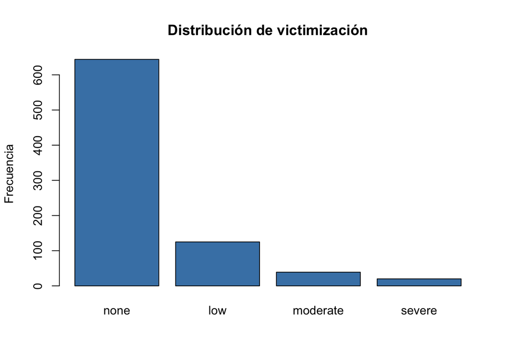

```r
# Visually checking distribution
barplot(table(pvictimisation_vars$victim_cat),
        col = "steelblue",
        main = "Distribución de victimización",
        ylab = "Frecuencia")
```

```r
# Extract new variable.
victimized <- pvictimisation_vars$victim_cat

# Add to pamplonaf
pamplonaf <- cbind(pamplonaf, victimized)
```

## Building the dependent variable: safety perception

The dependent variable in this study aims to capture individuals’ subjective **perception of insecurity in public space**. This construct is multidimensional, encompassing not only how safe people feel in various contexts but also their emotional responses, behavioral adaptations, and evaluations of their local environment. The following items from the questionnaire were selected based on their conceptual relevance to the concept:

- **P7 (situational safety perceptions):** these items ask respondents how safe they feel in specific environments (e.g., at home, in parks, in public transport). Items such as **P7_2 to P7_6** were retained as they directly reflect situational insecurity. **P7_7** and **P7_8** measure perception when seeing a police patrol and when seeing people drinking on the street; both were excluded from the main construct as it relates to institutional presence and social stimuli rather than the respondent’s environment per se. **P7_1** refers specifically to the private domain of the respondent’s home. Since this study focuses on public space and collective urban environments, this item was excluded from the perception index to ensure conceptual coherence, as including it could introduce interpretive inconsistencies in the latent construct.
- **P10 (statements of security and avoidance behaviors):**
  - **P10_1 and P10_2** are retained, as they capture generalized perceptions of safety in the city and neighborhood.
  - **P10_3 and P10_7**, which involve behavioral self-restraint (e.g., avoiding going out or visiting areas), are interpreted as **self-defense strategies** (behaviors likely resulting from prior insecurity). These were excluded to avoid endogeneity and maintain conceptual clarity, since they are also behaviors that agents in the ABM may enact based on model parameters. However, these variables are still included in regression models as **predictors**, in order to assess their statistical association with perceived insecurity and to inform rule development in the ABM.
  - **P10_4 to P10_6**, which capture attitudes towards surveillance technologies, were excluded, as they reflect political or normative beliefs rather than actual insecurity perceptions.
- **P11 (global evaluations of safety):** both P11_1 and P11_2 provide scalar ratings of perceived safety in the respondent’s **neighborhood** and **city**, respectively. These are highly relevant and were included in the composite index.
- **P12 (perceived neighborhood degradation and crime)** reflects the respondent’s perception of environmental disorder and local criminality. While not a direct emotional perception, it represents contextual perception of insecurity and is excluded.
- **P8** (installing a security system) and **P9** (considering relocation) represent self-protective responses to perceived risk. As behavioral outcomes, they were excluded from the CATPCA to avoid conceptual circularity, but are included in regression models to assess their relationship with perceived and contextual insecurity.

```r
perception_vars <- pamplonaf |>
  dplyr::select(p7_2, p7_3,
                p7_4, p7_5, p7_6,
                p10_1, p10_2,
                p11_1, p11_2)

# p13 no se incluyen porque serían incongruentes dentro de un índice de percepción personal o situacional, ya que se refieren a otros barrios, no a la experiencia directa del encuestado, y no necesariamente se refieren a su propio barrio.
# p8 y p9 fuera porque mide una consecuencia de la inseguridad y podría crear endogeneidad.
# p12 mide la evaluación del barrio, que se basa en la percepción, pero no es una medida directa (puedes verlo degradado pero no sentirte inseguro) asi que se usa como predictora en la regresión mejor.

univariate_analysis(perception_vars)
```

```
## Analysis for p7_2
##
##   1   2   3
## 755  68   5
```

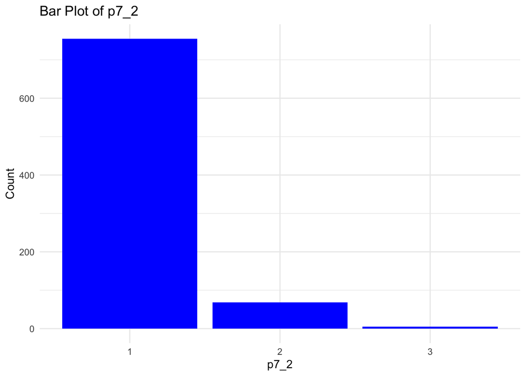

```
##
##
## Analysis for p7_3
##
##   1   2   3
## 627 188  13
```

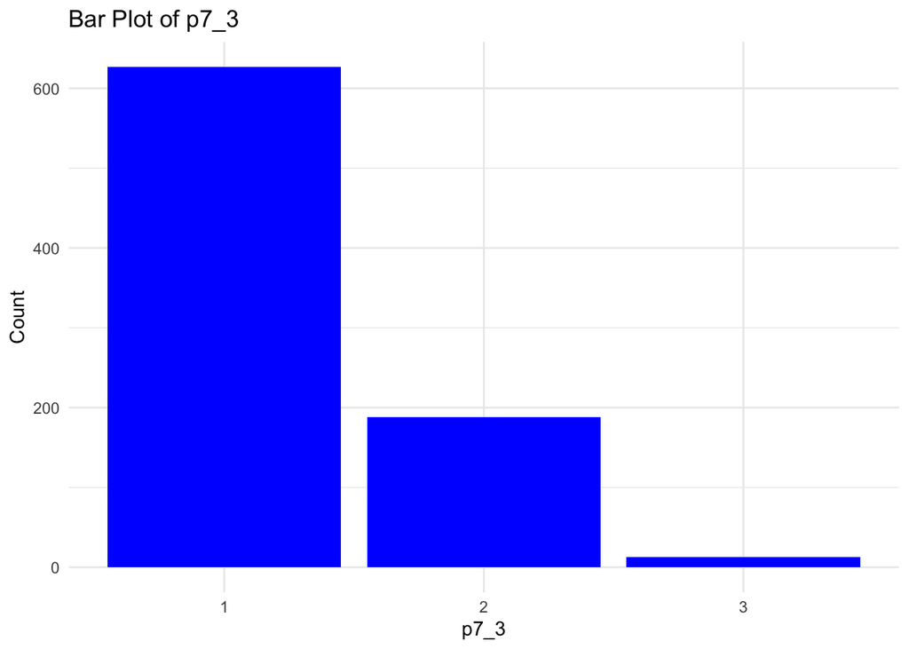

```
##
##
## Analysis for p7_4
##
##   1   2   3
## 319 423  86
```

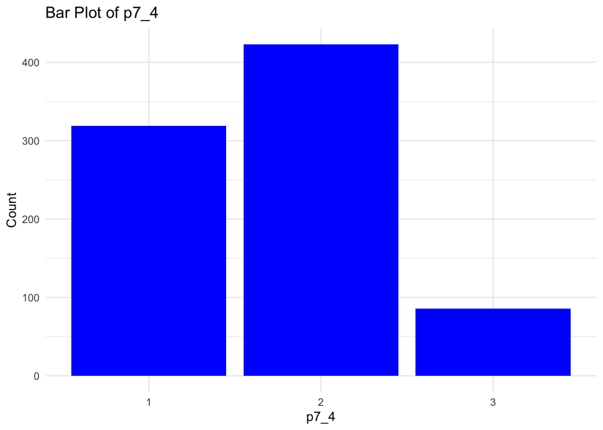

```
##
##
## Analysis for p7_5
##
##   1   2   3
## 417 351  60
```

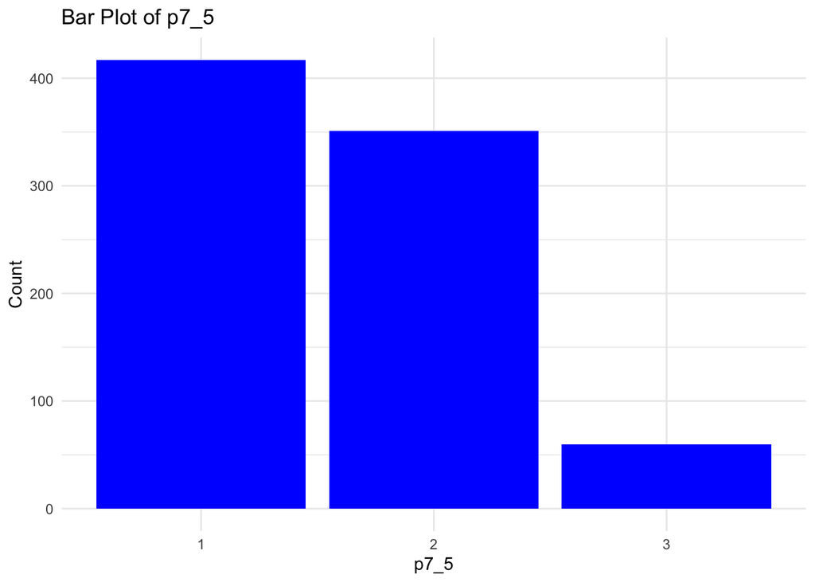

```
##
##
## Analysis for p7_6
##
##   1   2   3
## 713 112   3
```

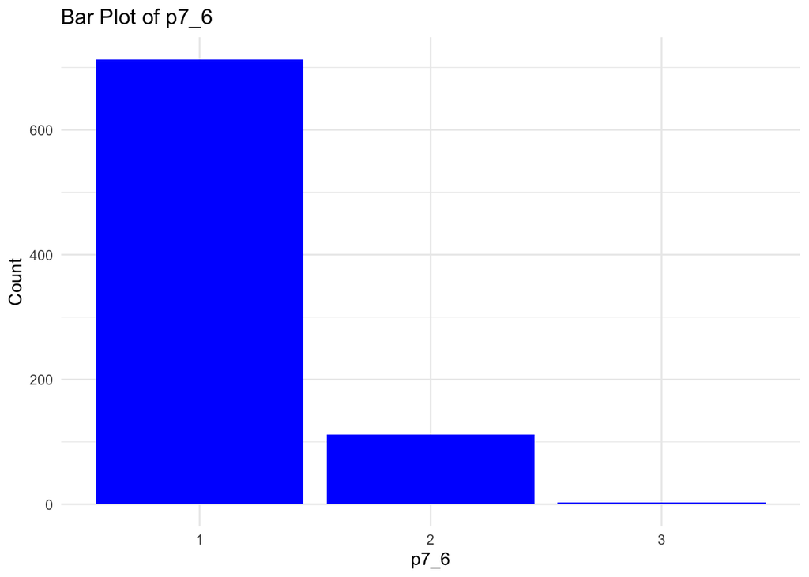

```
##
##
## Analysis for p10_1
##
##   1   2   3   4
##  96 172 300 260
```

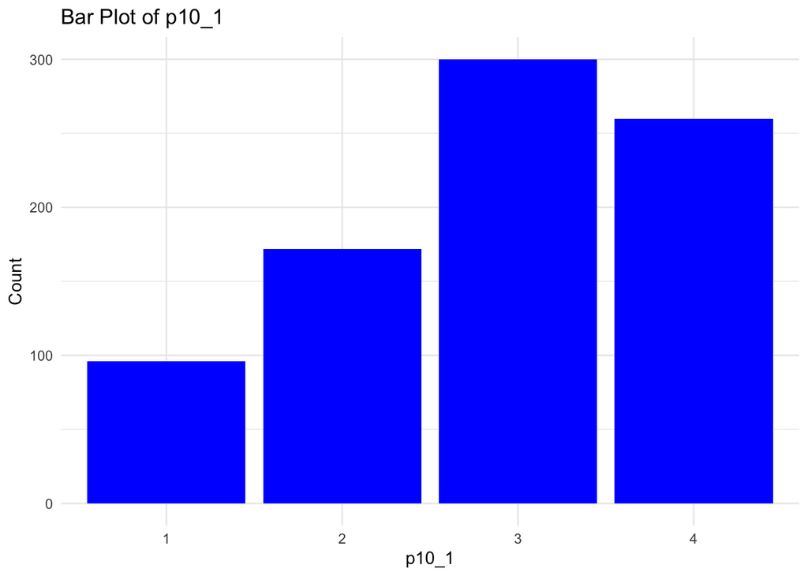

```
##
##
## Analysis for p10_2
##
##   1   2   3   4
##  83 161 289 295
```

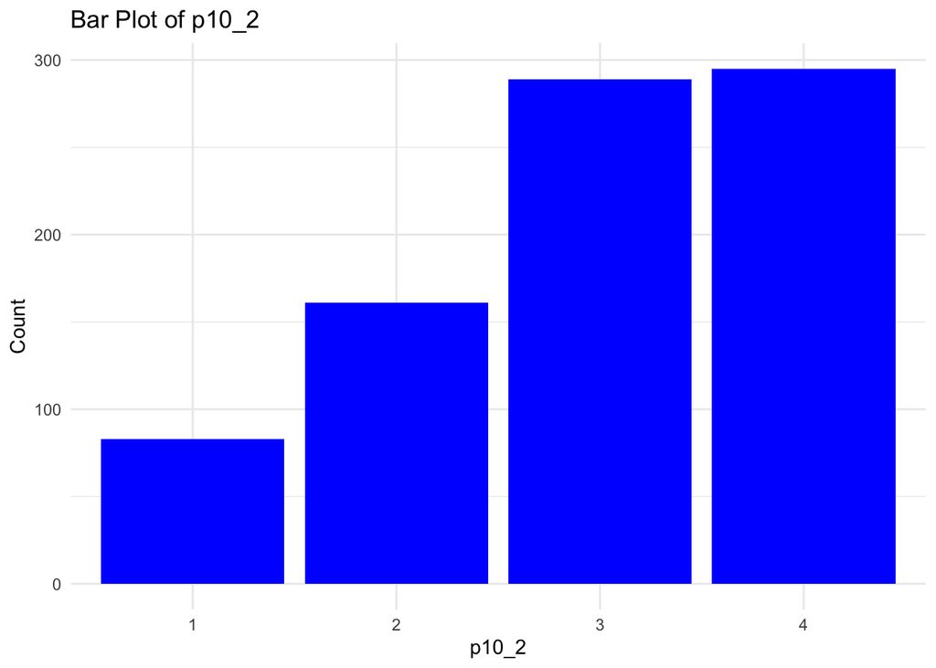

```
##
##
## Analysis for p11_1
##    Min. 1st Qu.  Median    Mean 3rd Qu.    Max.
##   1.000   7.000   8.000   7.615   9.000  10.000
```

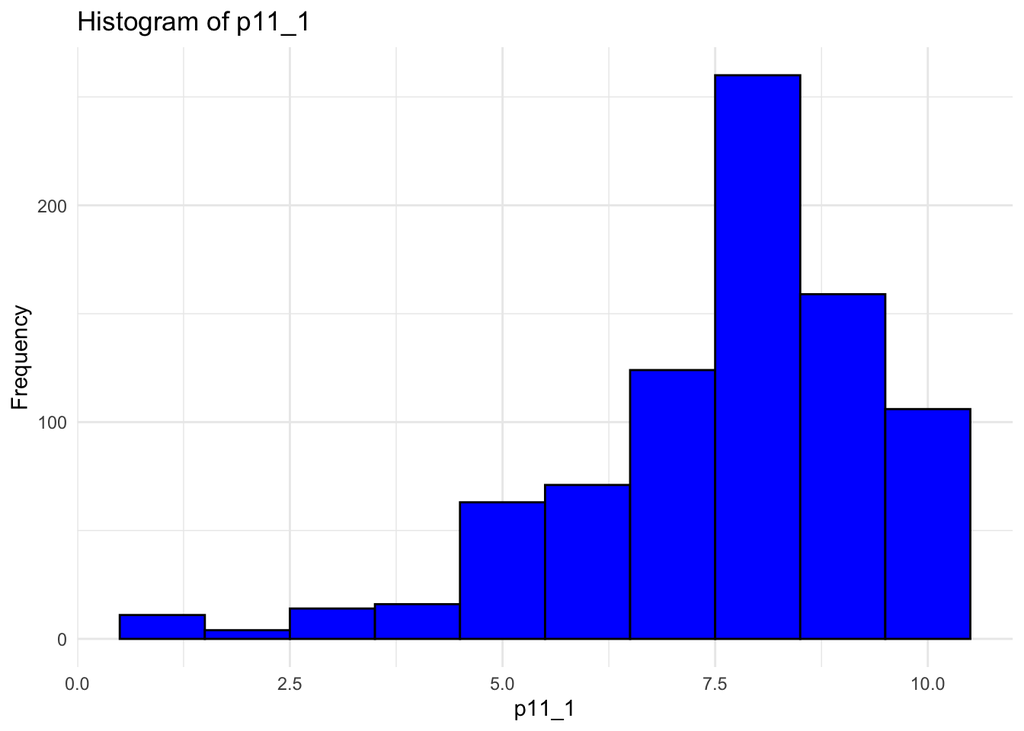

```
##
##
## Analysis for p11_2
##    Min. 1st Qu.  Median    Mean 3rd Qu.    Max.
##    1.00    7.00    8.00    7.49    9.00   10.00
```

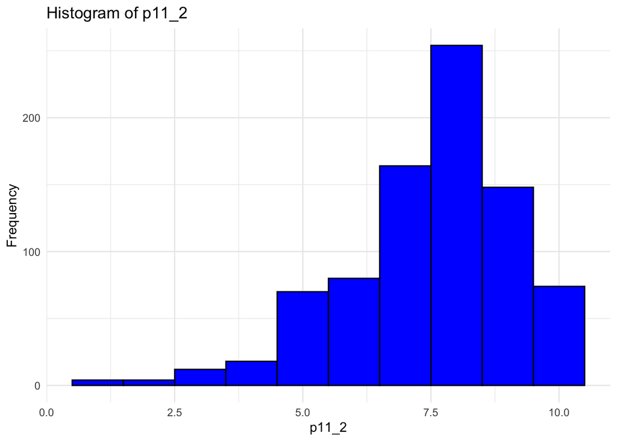

### Recoding P11_1 and P11_2

Due to the highly skewed distribution of responses in questions P11_1 and P11_2 (rating security in one’s neighborhood and city on a scale from 1 to 10), we implemented and compared three different recoding strategies: (1) conceptually adjacent grouping, (2) empirical quartile-based recoding, and (3) ideal fourths for robustness against skewness and outliers. These strategies were evaluated based on their explanatory power within the CATPCA framework. Below, I detail the conceptual rationale, strengths, and limitations of each approach.

1. **Adjacent grouping based on conceptual proximity**

This method involves merging adjacent scale points based on semantic similarity and intuitive interpretation. For instance, very low scores (e.g., 1–4) may be grouped as “insecure,” middle scores (5–7) as “moderate,” and high scores (8–10) as “secure.”

This methods aligns closely with how respondents may mentally categorize their answers, preserves the ordinal nature of the variable while enhancing parsimony and facilitates easier interpretation of results. However, it relies on subjective judgments and theoretical assumptions about what constitutes a meaningful category boundary, and there is the risk of losing explanatory power if conceptually grouped categories do not align well with actual distributional patterns.

```r
perception1 <-  perception_vars

# Grouping adjacent categories
perception1$p11_1r <- ifelse(perception1$p11_1 %in% 1:4, 1,
                                  ifelse(perception1$p11_1 %in% 5:7, 2, 3))

perception1$p11_2r <- ifelse(perception1$p11_2 %in% 1:4, 1,
                                  ifelse(perception1$p11_2 %in% 5:7, 2, 3))
```

```r
# Running CATPCA to test the results
perception1 <-  perception1 |>
  dplyr::select(-p11_1, -p11_2)

fitord <- princals(perception1,
                   ordinal = T,
                   ndim = 3)  ## default is ordinal=TRUE

summary(fitord)
```

```
##
## Loadings (cutoff = 0.1):
##        Comp1  Comp2  Comp3
## p7_3    0.737  0.299
## p7_4    0.771        -0.238
## p7_5    0.729  0.114
## p7_6    0.558  0.516
## p10_1  -0.754  0.401  0.334
## p10_2  -0.740  0.417  0.346
## p11_1r -0.646  0.225 -0.555
## p7_2    0.473  0.673
## p11_2r -0.613  0.190 -0.634
##
## Importance (Variance Accounted For):
##                  Comp1   Comp2   Comp3
## Eigenvalues     4.1142  1.2449  1.0061
## VAF            45.7131 13.8321 11.1787
## Cumulative VAF 45.7100 59.5500 70.7200
```

```r
# CATPCA results: 45.71, 59.55, 70.72 (3 first components)
```

2. **Quartile based encoding**

```r
# Quartile based encoding
perception2 <- perception_vars

perception2$p11_1r <- cut(perception2$p11_1,
                              breaks = quantile(perception2$p11_1, probs = 0:3 / 3),
                              include.lowest = TRUE,
                              labels = c("Bajo", "Medio", "Alto"))
perception2$p11_2r <- cut(perception2$p11_2,
                              breaks = quantile(perception2$p11_2, probs = 0:3 / 3),
                              include.lowest = TRUE,
                              labels = c("Bajo", "Medio", "Alto"))

# checking results
table(perception2$p11_1r)
```

```
##
##  Bajo Medio  Alto
##   303   260   265
```

```r
table(perception2$p11_2r)
```

```
##
##  Bajo Medio  Alto
##   352   254   222
```

```r
perception2 <-  perception2 |>
  dplyr::select(-p11_1, -p11_2)

fitord <- princals(perception2,
                   ordinal = T,
                   ndim = 3)  ## default is ordinal=TRUE

summary(fitord)
```

```
##
## Loadings (cutoff = 0.1):
##        Comp1  Comp2  Comp3
## p7_3    0.712  0.344
## p7_4    0.772        -0.339
## p7_5    0.697  0.227 -0.320
## p7_6    0.533  0.513  0.260
## p10_1  -0.797  0.314  0.232
## p10_2  -0.782  0.314  0.248
## p11_1r -0.672  0.375 -0.448
## p11_2r -0.621  0.435 -0.444
## p7_2    0.448  0.650  0.228
##
## Importance (Variance Accounted For):
##                  Comp1   Comp2   Comp3
## Eigenvalues     4.1584  1.3878  0.8546
## VAF            46.2040 15.4203  9.4957
## Cumulative VAF 46.2000 61.6200 71.1200
```

```r
# CATPCA results: 46.2, 61.62, 71.12 (3 first components)
```

3. **Ideal Fourths (Robust Quartiles)**

The interquartile range (IQR) is a widely used metric for capturing the central dispersion of a distribution and is often employed for data recoding purposes. However, in the presence of **skewed distributions** or **outliers**, the traditional IQR can be insufficient to accurately reflect the central tendency. This is due to its reliance on quartile boundaries that may themselves be distorted by extreme values. To address this limitation, the use of **Ideal Fourths (IF)** is proposed as a more robust alternative. As discussed in Hopkins and Glass (1978), and Wilcox (2017), ideal fourths offer a modified approach to quartile calculation that minimizes the influence of extreme values, providing a more resilient measure of central dispersion.

In the present study, the **perception of insecurity is not evenly distributed**, but rather clustered in the mid to low range of the scale. The Ideal Fourths approach yields **categories that are more representative of the actual dispersion and shape of the data**. Therefore, **recoding via Ideal Fourths** produced a **more skewed distribution**, with a higher concentration of observations in the “Low” and “Medium” categories, and relatively fewer in the “High” category. This reflects the method’s ability to downweight the influence of outliers and capture the core of the distribution more faithfully.

**Cita del artículo**:

> Hopkins, J., & Glass, G. (1978). **Estadística robusta aplicada a las medidas de localización y escala**. *Nota Técnica*. Recuperado de: [ResearchGate](https://www.researchgate.net/publication/343779974_Estadistica_robusta_aplicada_a_las_medidas_de_localizacion_y_escala_Nota_Tecnica#pf5).

```r
perception3 <- perception_vars

# Ideal quartile recoding
# First, we sort the data
p111_sorted <- sort(perception3$p11_1)

# Total number of observations
n <- length(p111_sorted)

# Compute j and h for ideal quartiles (Tukey's rule)
j <- round((n / 4) + (5 / 12))
h <- (n / 4) + (5 / 12) - j

# Calculate the ideal lower and upper quartiles
qi <- (1 - h) * p111_sorted[j] + h * p111_sorted[j + 1]
qs <- (1 - h) * p111_sorted[n - j + 1] + h * p111_sorted[n - j]

# Print the ideal quartile values
cat("Cuartil inferior (qi):", qi, "\n")
```

```
## Cuartil inferior (qi): 7
```

```r
cat("Cuartil superior (qs):", qs, "\n")
```

```
## Cuartil superior (qs): 9
```

```r
# Recode the variable p11_1 using the ideal quartiles
perception3$p11_1r_recoded_ideal <- cut(perception3$p11_1,
                                            breaks = c(min(perception3$p11_1), qi, qs, max(perception3$p11_1)),
                                            include.lowest = TRUE,
                                            labels = c("Bajo", "Medio", "Alto"))

# View the distribution of the new categories
table(perception3$p11_1r_recoded_ideal)
```

```
##
##  Bajo Medio  Alto
##   303   419   106
```

```r
# Inspect values in each category
# Category "Low"
bajo_values <- subset(perception3, p11_1r_recoded_ideal == "Bajo")
summary(bajo_values$p11_1)
```

```
##    Min. 1st Qu.  Median    Mean 3rd Qu.    Max.
##   1.000   5.000   6.000   5.723   7.000   7.000
```

```r
# Category "Medium"
medio_values <- subset(perception3, p11_1r_recoded_ideal == "Medio")
summary(medio_values$p11_1)
```

```
##    Min. 1st Qu.  Median    Mean 3rd Qu.    Max.
##   8.000   8.000   8.000   8.379   9.000   9.000
```

```r
# Category "High"
alto_values <- subset(perception3, p11_1r_recoded_ideal == "Alto")
summary(alto_values$p11_1)
```

```
##    Min. 1st Qu.  Median    Mean 3rd Qu.    Max.
##      10      10      10      10      10      10
```

```r
# Ideal quartile recoding
# First, we sort the data
p112_sorted <- sort(perception3$p11_2)

# Total number of observations
n <- length(p112_sorted)

# Compute j and h for ideal quartiles (Tukey's rule)
j <- round((n / 4) + (5 / 12))
h <- (n / 4) + (5 / 12) - j

# Calculate the ideal lower and upper quartiles
qi2 <- (1 - h) * p112_sorted[j] + h * p112_sorted[j + 1]
qs2 <- (1 - h) * p112_sorted[n - j + 1] + h * p112_sorted[n - j]

# Print the ideal quartile values
cat("Cuartil inferior (qi):", qi2, "\n")
```

```
## Cuartil inferior (qi): 7
```

```r
cat("Cuartil superior (qs):", qs2, "\n")
```

```
## Cuartil superior (qs): 9
```

```r
# Recode the variable p11_2 using the ideal quartiles
perception3$p11_2r_recoded_ideal <- cut(perception3$p11_2,
                                            breaks = c(min(perception3$p11_2), qi2, qs2, max(perception3$p11_2)),
                                            include.lowest = TRUE,
                                            labels = c("Bajo", "Medio", "Alto"))

# View the distribution of the new categories
table(perception3$p11_2r_recoded_ideal)
```

```
##
##  Bajo Medio  Alto
##   352   402    74
```

```r
# Inspect values in each category
# Category "Low"
bajo_values <- subset(perception3, p11_2r_recoded_ideal == "Bajo")
summary(bajo_values$p11_2)
```

```
##    Min. 1st Qu.  Median    Mean 3rd Qu.    Max.
##    1.00    5.00    6.00    5.96    7.00    7.00
```

```r
# Category "Medium"
medio_values <- subset(perception3, p11_2r_recoded_ideal == "Medio")
summary(medio_values$p11_2)
```

```
##    Min. 1st Qu.  Median    Mean 3rd Qu.    Max.
##   8.000   8.000   8.000   8.368   9.000   9.000
```

```r
# Category "High"
alto_values <- subset(perception3, p11_2r_recoded_ideal == "Alto")
summary(alto_values$p11_2)
```

```
##    Min. 1st Qu.  Median    Mean 3rd Qu.    Max.
##      10      10      10      10      10      10
```

```r
perception3 <-  perception3 |>
  dplyr::select(-p11_1, -p11_2)

fitord <- princals(perception3,
                   ordinal = T,
                   ndim = 3)  ## default is ordinal=TRUE

summary(fitord)
```

```
##
## Loadings (cutoff = 0.1):
##                      Comp1  Comp2  Comp3
## p7_3                  0.708  0.354
## p7_4                  0.779        -0.260
## p7_5                  0.703  0.235 -0.195
## p7_6                  0.536  0.485  0.280
## p10_1                -0.793  0.279  0.318
## p10_2                -0.773  0.269  0.358
## p11_1r_recoded_ideal -0.626  0.483 -0.426
## p11_2r_recoded_ideal -0.566  0.497 -0.497
## p7_2                  0.454  0.619  0.280
##
## Importance (Variance Accounted For):
##                  Comp1   Comp2   Comp3
## Eigenvalues     4.0331  1.4349  0.9244
## VAF            44.8122 15.9436 10.2707
## Cumulative VAF 44.8100 60.7600 71.0300
```

```r
# CATPCA results: 44.81, 60.76, 71.03 (3 first components)
```

After carrying out the different analysis, running the CATPCA models and observed the results, it has been proven that the **quartile based encoding was the best performing recode method**:

```r
rm(perception2)

# Quartile based encoding
perception2 <- perception_vars

perception2$p11_1r <- cut(perception2$p11_1,
                              breaks = quantile(perception2$p11_1, probs = 0:3 / 3),
                              include.lowest = TRUE,
                              labels = c("Bajo", "Medio", "Alto"))
perception2$p11_2r <- cut(perception2$p11_2,
                              breaks = quantile(perception2$p11_2, probs = 0:3 / 3),
                              include.lowest = TRUE,
                              labels = c("Bajo", "Medio", "Alto"))

# checking results
table(perception2$p11_1r)
```

```
##
##  Bajo Medio  Alto
##   303   260   265
```

```r
table(perception2$p11_2r)
```

```
##
##  Bajo Medio  Alto
##   352   254   222
```

### Dimensionality reduction: CATPCA

```r
fitord <- princals(perception2,
                   ordinal = T,
                   ndim = 3)  ## default is ordinal = TRUE

summary(fitord)
```

```
##
## Loadings (cutoff = 0.1):
##        Comp1  Comp2  Comp3
## p7_3    0.647  0.435  0.148
## p7_4    0.701  0.327 -0.297
## p7_5    0.619  0.419 -0.163
## p10_1  -0.770         0.459
## p10_2  -0.752         0.479
## p11_1  -0.808  0.351 -0.185
## p11_2  -0.773  0.439 -0.197
## p11_1r -0.794  0.362 -0.193
## p11_2r -0.751  0.461 -0.198
## p7_2    0.364  0.594  0.428
## p7_6    0.462  0.504  0.360
##
## Importance (Variance Accounted For):
##                  Comp1   Comp2   Comp3
## Eigenvalues     5.2422  1.7397  1.0398
## VAF            47.6561 15.8158  9.4526
## Cumulative VAF 47.6600 63.4700 72.9200
```

One of the key methodological decisions in principal component analysis is determining how many components to retain. In this study, the first two components account for approximately **63.4% of the total variance**, while the inclusion of a third component raises that figure to **72.9%**.

**Retaining only two components** provides a more parsimonious model and facilitates interpretation and integration into subsequent models, as we plan on doing with the regressions and the ABM. However, it entails discarding potentially meaningful variation. On the other hand, **retaining three components**, allows for a more nuanced understanding of the underlying structure of perceived insecurity. It distinguishes between different domains of perception (personal, institutional, and environmental) and better reflects the complexity of the phenomenon, though it introduces additional interpretive and computational layers. I have opted to retain only two components, since the total variance they account for is statistically enough and, for the present research, I prioritize a parsimonious model rather than a complex one.

- **Component 1** reflects **general urban insecurity**, particularly in public and semi-public spaces such as commercial areas, solitary streets, and nightlife zones. It also includes general evaluations of security in one’s neighborhood and city. This component represents the core emotional and experiential dimension of perceived insecurity, meaning, how unsafe people feel in the places where they live and move.
- **Component 2** captures a sense of **institutional or service-related insecurity**. It includes feelings of insecurity in public facilities, like community centers, and in public transportation. This dimension likely reflects a breakdown in the implicit trust citizens place in infrastructure and public institutions as protectors of safety.

The numerical **loadings** associated with each variable in the CATPCA output indicate the **strength and direction of the association** between that variable and a given component, and they provide both directional and magnitude information. Loadings above **±0.70** are considered strong contributors to the component, loadings between ±0.40 and ±0.69 are considered moderate, and loadings between ±0.25 and ±0.39 may still be interpretable if theoretically meaningful.

**Component 1 (general urban insecurity)** is anchored by both **specific spatial perceptions** (isolated streets and parks, commercial areas, and nightlife zones) and **generalized urban insecurity**. The inverse loadings from p10_1, p10_2, p11_1r, and p11_2r (which are inverse because the item is framed in terms of **feeling safe**) indicate that **higher scores on this component correspond to stronger feelings of insecurity** in both local and city-level settings.

**Component 2 (institutional and service-based insecurity)** reflects insecurity in contexts where safety is expected by design, such as public buildings (libraries, sport centers, etc.) and public transport, places that usually should convey more protection, possibly due to past incidents, social cues, or poor maintenance. The weak-moderate cross-loading variables, such as the ones referred to the safety feeling in the city and the neighborhood, add context but is less distinctive.

> Although the original security evaluation items (p11_1 and p11_2) showed strong and expected negative loadings in Component 1 they also displayed moderate positive loadings in Component 2. This apparent inconsistency in direction does not indicate a problem with the recoding or the conceptual structure of the model. Rather, it reflects a common feature of CATPCA: variables may load differently across orthogonal components depending on how their variance aligns with distinct latent dimensions. In this case, p11_1 and p11_2 are not dominant in Component 2, but share a minor portion of their variance with the insecurity expressed in institutional spaces. This can occur for at least two reasons: first, individuals who feel unsafe in public services may not necessarily rate their city or neighborhood as unsafe overall; and second, the opposite may also be true: some individuals may report positive global evaluations of their neighborhood or city while still experiencing insecurity in specific institutional settings, possibly due to personal experiences in those spaces. The moderate positive loadings of these items thus reflect a weak but statistically detectable pattern of association, which does not undermine the overall interpretation of Component 2 as focused on situational insecurity in environments expected to offer protection and order.

```r
# Checking component loadings
fitord$loadings
```

```
##                D1          D2         D3
## p7_2    0.3644208  0.59374318  0.4282124
## p7_3    0.6466582  0.43497272  0.1483918
## p7_4    0.7005958  0.32742443 -0.2965440
## p7_5    0.6192583  0.41872061 -0.1632005
## p7_6    0.4617123  0.50418956  0.3601067
## p10_1  -0.7701058 -0.02085101  0.4590116
## p10_2  -0.7516187 -0.02823208  0.4794308
## p11_1  -0.8078119  0.35104989 -0.1849435
## p11_2  -0.7733742  0.43948071 -0.1969098
## p11_1r -0.7940255  0.36154129 -0.1931554
## p11_2r -0.7513734  0.46145262 -0.1982531
```

The **biplot** is a two-dimensional representation of the relationships between the original variables and the first two principal components extracted by CATPCA. It offers a geometric visualization of the multivariate data structure, enabling us to assess how variables relate to the underlying dimensions, to one another, and to the total explained variance. In the plot below we can see:

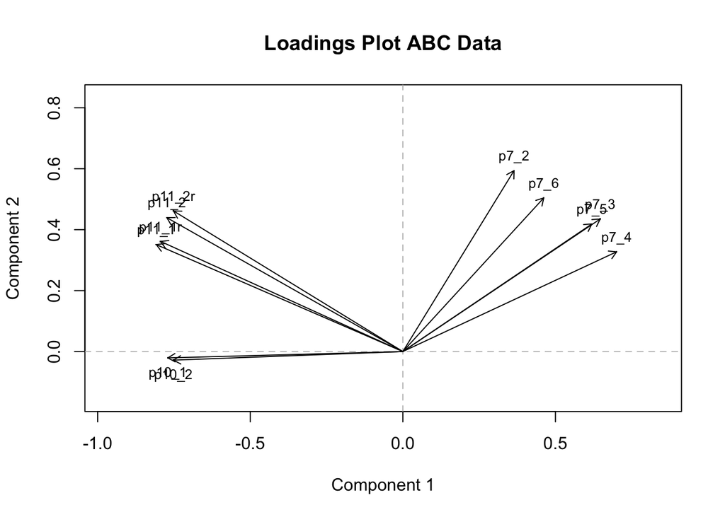

```r
# Loadings plot or biplot
plot(fitord, "loadplot",
     main = "Loadings Plot ABC Data")  ## aspect ratio = 1
```

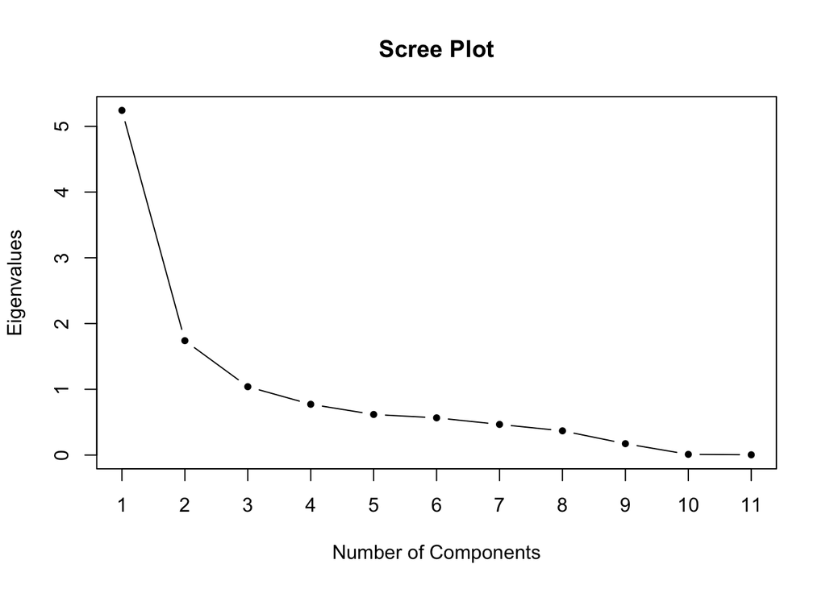

```r
# Screeplot
plot(fitord, "screeplot")
```

Together, the scree plot and biplot offer a cross-validation: while the scree plot justifies keeping only two components, the biplot shows that these two components already capture distinct conceptual dimensions (urban spatial insecurity and institutional/service insecurity).

# Building linear regression models

As stated earlier, I chose the first two components.

```r
# Extract component scores.
component_scores <- fitord$objects[, 1:2]

# Rename columns for clarity.
colnames(component_scores) <- c("gen_ins", "inst_ins")

# Add to pamplonaf
pamplonaf <- cbind(pamplonaf, component_scores)
  # pamplonaf <- pamplonaf |> dplyr::select(-gen_ins, -inst_ins)

pampre <- pamplonaf |>
  dplyr::select(-p5_1, -p5_2, -p5_3,
                -p5_4, -p5_5, -p5_6,
                -p5_7, -p5_8,
                -p6_1, -p6_2, -p6_3,
                -p7_2, -p7_3,
                -p7_4, -p7_5, -p7_6,
                -p10_1, -p10_2,
                -p11_1, -p11_2) |>
  mutate(crime_index = as.numeric(crime_index))
```

After extracting the component scores from the CATPCA, it was important to examine the relationship between the resulting dimensions. Since Principal Components Analysis (including its categorical variant) produces orthogonal components by design, we expected the new variables to be uncorrelated. To confirm this, I computed the pairwise Pearson correlations between the first two CATPCA components. The results are shown in the following correlation matrix.

The near-zero correlations among the components confirm their **orthogonality**, validating their use as independent dimensions in further analyses.

```r
cor(pampre[, c("gen_ins", "inst_ins")], use = "complete.obs")
```

```
##               gen_ins     inst_ins
## gen_ins  1.000000e+00 1.501751e-17
## inst_ins 1.501751e-17 1.000000e+00
```

Given that these components represent distinct yet potentially related aspects of the underlying constructs, it is appropriate to use them simultaneously as dependent variables in a **multivariate multiple regression framework**. This approach allows me to assess how a set of predictors influences each component, while also testing for overall effects across the multivariate outcome space.

## Processing predictors before the regressions

Before running the multiple regression analysis, I recoded the sociodemographic variables (income, education, and employment) to reduce the number of categories. This ensures model stability and improve interpretability, as categorical predictors with many levels can lead to sparse data in some categories, inflating standard errors and reducing statistical power.

```r
# recoding INCOME, EDUCATION, EMPLOYMENT to reduce the number of categories
pampre <- pampre |>
  # EDUCATION: categories 3 and 4 are both secundary education, collapsed into one cat.
  mutate(education = case_when(education %in% c("1", "2") ~ "1",
    education %in% c("3", "4") ~ "2",
    education == "5" ~ "3",
    TRUE ~ education  # Keep all other values unchanged
  )) |>
  mutate(education = as.ordered(education))

pampre <- pampre |>
  # EMPLOYMENT: categories 3 and 4 are both secundary employment, collapsed into one cat.
  mutate(employment = case_when(employment %in% c("1", "2") ~ "1",
    employment %in% c("3", "4") ~ "2",
    employment %in% c("6", "7", "8") ~ "3",
    TRUE ~ employment  # Keep all other values unchanged
  )) |>
  mutate(employment = as.ordered(employment))

pampre <- pampre |>
  # INCOME
  mutate(income = case_when(income %in% c("1", "2") ~ "1",
    income %in% c("3", "4") ~ "2",
    income %in% c("5", "6", "7") ~ "3",
    income %in% c("8", "9", "10") ~ "4",
    TRUE ~ income  # Keep all other values unchanged
  )) |>
  mutate(income = as.ordered(income))
```

While developing the model in GAMA, I noticed that the shapefile used to represent Pamplona (downloaded directly from the official website of the Pamplona city center) included only 13 neighborhoods, whereas the survey data referenced 14. The neighborhood Azpilagaña was missing from the shapefile so, due to geographical proximity, it was merged with Milagrosa-Arrosadia in all the variables related to neighborhood identification (`barrio`, `p13a`, and `p13b`).

```r
# Combine neighborhoods 8 and 9
pampre <- pampre %>%
  mutate(
    barrio = case_when(
                    barrio %in% c("8", "9") ~ "8",
                     barrio == "10" ~ "9",
                     barrio == "11" ~ "10",
                      barrio == "12" ~ "11",
                      barrio == "13" ~ "12",
                     barrio == "14" ~ "13",
                      TRUE ~ barrio),
    p13a = case_when(p13a %in% c("8", "9") ~ "8",
                     p13a == "10" ~ "9",
                      p13a == "11" ~ "10",
                      p13a == "12" ~ "11",
                      p13a == "13" ~ "12",
                     p13a == "14" ~ "13",
                      TRUE ~ p13a),
    p13b = case_when(p13b %in% c("8", "9") ~ "8",
                     p13b == "10" ~ "9",
                     p13b == "11" ~ "10",
                     p13b == "12" ~ "11",
                     p13b == "13" ~ "12",
                     p13b == "14" ~ "13",
                      TRUE ~ p13b),
    barrio = factor(barrio, levels = as.character(1:13)),
    p13a = factor(p13a, levels = as.character(1:13)),
    p13b = factor(p13b, levels = as.character(1:13)))
```

Now, I ensure that each variable is appropriately encoded according to its measurement level. Ordinal variables, such as attitudes and sociodemographic indicators like education and income, are converted into ordered factors. Binary variables are recoded into a 0/1 format. Continuous variables are standardized using Z-scores, allowing for comparability across predictors with different scales and improving model convergence.

```r
# Converting ordinal variables to ordered factors
make_ordered <- function(data, vars) {
  for (var in vars) {
    data[[var]] <- as.ordered(data[[var]])
  }
  return(data)
}

pampre <- make_ordered(pampre, c("p7_1", "p7_7", "p7_8",
                                 "p10_3", "p10_4", "p10_5", "p10_6", "p10_7",
                                 "p12", "p15", "p19",
                                 "employment", "education", "income",
                                 "victimized"))

# Re-encodes binary variables to 0/1. This recodes 1 to 1 and 2 to 0, so maybe consider changing this
recode_binary <- function(data, vars, value_to_keep = 1, new_value = 1, other_value = 0) {
  for (var in vars) {
    data[[var]] <- ifelse(data[[var]] == value_to_keep, new_value, other_value)
  }
  return(data)
}

pampre <- recode_binary(pampre, c("gender", "nationality",
                                         "p8", "p9","p16"))

# Standardizes numeric variables using Z-scores
pampre$crime_index_z <- scale(pampre$crime_index)
pampre$agez <- scale(pampre$age)
pampre$agez <- as.numeric(pampre$agez)

pampre$p14z <- scale(pampre$p14) # es una escala del 1 al 10 pero como no la trato como ordinal (no sé si debería, la trato como numérica y la escalo)
pampre$gen_ins1 <- scale(pampre$gen_ins)
pampre$gen_ins1 <- as.numeric(pampre$gen_ins1)

# Cleaning up the dataset by removing unstandardized columns
pampre <- pampre |>
  dplyr::select(-crime_index, -p14)
```

## Multivariate regression

To ensure analytical clarity and theoretical coherence, the independent variables in this model are introduced in blocks, based on their conceptual function and proximity to the dependent variables. This approach aligns with best practices in multivariate modeling, particularly when the regression model serves as a foundation for rule-based simulations in agent-based models (ABMs).

### Building the model

Age, gender, education level, income, employment status, nationality and neighborhood are introduced first. These variables reflect relatively stable characteristics of individuals and are going to be used as **agent attributes** in ABM environments. They help account for basic heterogeneity in perception patterns and are essential for establishing baseline variation.

> hacer las dos pruebas. para hacer las tres a la vez (no multivariante): https://library.virginia.edu/data/articles/getting-started-with-multivariate-multiple-regression

```r
modelo_mv <- lm(cbind(gen_ins1, inst_ins) ~ agez + gender + education + income + employment + nationality + barrio, data = pampre)

# Wilks & Pillai tests are robust and measure if there is a significant global effect. If it is, individual effects can be assessed.
summary(manova(modelo_mv), test = "Wilks")
```

```
##              Df   Wilks approx F num Df den Df    Pr(>F)
## agez          1 0.97554  10.0652      2    803 4.816e-05 ***
## gender        1 0.93630  27.3139      2    803 3.340e-12 ***
## education     2 0.99353   1.3043      4   1606  0.266218
## income        3 0.97591   3.2832      6   1606  0.003257 **
## employment    3 0.98794   1.6289      6   1606  0.135311
## nationality   1 0.96765  13.4222      2    803 1.846e-06 ***
## barrio       12 0.95978   1.3877     24   1606  0.100134
## Residuals   804
## ---
## Signif. codes:  0 '***' 0.001 '**' 0.01 '*' 0.05 '.' 0.1 ' ' 1
```

```r
summary(manova(modelo_mv), test = "Pillai")
```

```
##              Df   Pillai approx F num Df den Df    Pr(>F)
## agez          1 0.024456  10.0652      2    803 4.816e-05 ***
## gender        1 0.063696  27.3139      2    803 3.340e-12 ***
## education     2 0.006466   1.3039      4   1608  0.266381
## income        3 0.024145   3.2749      6   1608  0.003323 **
## employment    3 0.012078   1.6283      6   1608  0.135484
## nationality   1 0.032349  13.4222      2    803 1.846e-06 ***
## barrio       12 0.040610   1.3886     24   1608  0.099685 .
## Residuals   804
## ---
## Signif. codes:  0 '***' 0.001 '**' 0.01 '*' 0.05 '.' 0.1 ' ' 1
```

```r
summary(modelo_mv)
```

```
## Response gen_ins1 :
##
## Call:
## lm(formula = gen_ins1 ~ agez + gender + education + income +
##     employment + nationality + barrio, data = pampre)
##
## Residuals:
##      Min       1Q   Median       3Q      Max
## -2.13736 -0.73511 -0.00439  0.69322  2.56550
##
## Coefficients:
##                Estimate Std. Error t value Pr(>|t|)
## (Intercept)  -3.725e-02  1.378e-01  -0.270   0.7869
## agez         -1.616e-03  5.421e-02  -0.030   0.9762
## gender       -4.871e-01  7.044e-02  -6.915 9.53e-12 ***
## education.L  -2.460e-02  7.642e-02  -0.322   0.7476
## education.Q  -5.552e-02  6.002e-02  -0.925   0.3552
## income.L     -2.048e-01  1.015e-01  -2.018   0.0439 *
## income.Q     -1.451e-02  7.618e-02  -0.190   0.8490
## income.C     -9.385e-06  6.309e-02   0.000   0.9999
## employment.L -1.216e-01  1.115e-01  -1.091   0.2755
## employment.Q -4.120e-02  1.011e-01  -0.407   0.6838
## employment.C -1.447e-03  8.021e-02  -0.018   0.9856
## nationality   2.928e-01  9.531e-02   3.072   0.0022 **
## barrio2       3.214e-02  1.531e-01   0.210   0.8338
## barrio3       2.508e-02  1.688e-01   0.149   0.8819
## barrio4       2.169e-02  1.522e-01   0.143   0.8867
## barrio5       2.219e-01  1.717e-01   1.292   0.1966
## barrio6       1.146e-01  1.470e-01   0.780   0.4357
## barrio7      -2.241e-01  1.652e-01  -1.356   0.1753
## barrio8       1.097e-01  1.460e-01   0.751   0.4526
## barrio9       2.674e-01  1.780e-01   1.502   0.1335
## barrio10      7.610e-03  1.566e-01   0.049   0.9612
## barrio11     -1.749e-01  2.657e-01  -0.658   0.5105
## barrio12     -1.370e-01  1.839e-01  -0.745   0.4566
## barrio13     -1.300e-01  1.932e-01  -0.673   0.5014
## ---
## Signif. codes:  0 '***' 0.001 '**' 0.01 '*' 0.05 '.' 0.1 ' ' 1
##
## Residual standard error: 0.9657 on 804 degrees of freedom
```

[output cut: 31 more lines]

```
## barrio5      -0.042291   0.171420  -0.247 0.805198
## barrio6       0.007842   0.146744   0.053 0.957394
## barrio7      -0.145379   0.164893  -0.882 0.378228
## barrio8       0.233072   0.145712   1.600 0.110095
## barrio9      -0.177838   0.177689  -1.001 0.317205
## barrio10     -0.097969   0.156285  -0.627 0.530927
## barrio11      0.107021   0.265222   0.404 0.686677
## barrio12     -0.030198   0.183567  -0.165 0.869373
## barrio13      0.110473   0.192897   0.573 0.567006
## ---
## Signif. codes:  0 '***' 0.001 '**' 0.01 '*' 0.05 '.' 0.1 ' ' 1
##
## Residual standard error: 0.964 on 804 degrees of freedom
## Multiple R-squared:  0.0976, Adjusted R-squared:  0.07179
## F-statistic: 3.781 on 23 and 804 DF,  p-value: 8.106e-09
```

**Experiential variables.**

Such as past victimization or self-protection behaviors.

```r
modelo_mv <- lm(cbind(gen_ins, inst_ins) ~ agez + gender + education + income + employment + nationality + barrio + victimized + p10_3 + p12 + p15 + p16 + p13a + p13b + p18 + p19 + p14z + p7_7 + p8 + p9, data = pampre)

summary(modelo_mv)
```

```
## Response gen_ins :
##
## Call:
## lm(formula = gen_ins ~ agez + gender + education + income + employment +
##     nationality + barrio + victimized + p10_3 + p12 + p15 + p16 +
##     p13a + p13b + p18 + p19 + p14z + p7_7 + p8 + p9, data = pampre)
##
## Residuals:
##      Min       1Q   Median       3Q      Max
## -1.90036 -0.50780 -0.01484  0.47630  2.15855
##
## Coefficients:
##              Estimate Std. Error t value Pr(>|t|)
## (Intercept)   0.04938    0.51137   0.097 0.923100
## agez          0.05573    0.05299   1.052 0.293253
## gender       -0.43254    0.06014  -7.192 1.55e-12 ***
## education.L  -0.02779    0.06376  -0.436 0.663067
## education.Q  -0.01744    0.04982  -0.350 0.726391
## income.L     -0.18149    0.08560  -2.120 0.034314 *
## income.Q      0.02851    0.06354   0.449 0.653767
## income.C     -0.03857    0.05216  -0.740 0.459791
## employment.L -0.10254    0.09480  -1.082 0.279795
## employment.Q -0.10559    0.08497  -1.243 0.214374
## employment.C  0.02711    0.06693   0.405 0.685587
## nationality   0.08734    0.08400   1.040 0.298776
## barrio2       0.12761    0.14517   0.879 0.379655
## barrio3       0.11436    0.15427   0.741 0.458742
## barrio4       0.01811    0.14356   0.126 0.899632
## barrio5       0.02486    0.15214   0.163 0.870272
## barrio6       0.10595    0.13261   0.799 0.424568
## barrio7       0.05651    0.15290   0.370 0.711773
## barrio8       0.40111    0.13386   2.996 0.002821 **
## barrio9       0.01056    0.15476   0.068 0.945610
## barrio10      0.31933    0.15813   2.019 0.043791 *
## barrio11     -0.13309    0.22330  -0.596 0.551339
## barrio12      0.25694    0.18051   1.423 0.155031
## barrio13      0.02249    0.17407   0.129 0.897218
## victimized.L  0.38404    0.13199   2.910 0.003725 **
## victimized.Q  0.10034    0.11775   0.852 0.394402
## victimized.C  0.14305    0.10694   1.338 0.181414
```

[output cut: 140 more lines]

```
## p19.Q         0.6346268  0.3202939   1.981 0.047912 *
## p19.C         0.4802681  0.2350397   2.043 0.041366 *
## p19^4         0.1944155  0.1509489   1.288 0.198158
## p19^5         0.1988050  0.0953526   2.085 0.037411 *
## p14z          0.1423003  0.0388435   3.663 0.000266 ***
## p7_7.L        0.2597588  0.2186663   1.188 0.235239
## p7_7.Q       -0.2213226  0.1510977  -1.465 0.143404
## p8            0.0953193  0.1088683   0.876 0.381556
## p9            0.0380358  0.1679021   0.227 0.820847
## ---
## Signif. codes:  0 '***' 0.001 '**' 0.01 '*' 0.05 '.' 0.1 ' ' 1
##
## Residual standard error: 0.9478 on 751 degrees of freedom
## Multiple R-squared:  0.1853, Adjusted R-squared:  0.1028
## F-statistic: 2.247 on 76 and 751 DF,  p-value: 4.411e-08
```

**Contextual variables.**

Such as trust in institutions or perceived environmental degradation, which represent broader cognitive evaluations or interpretations of one’s environment. **While they may not be directly simulated in the ABM, they are essential for capturing higher-order cognitive processing and may inform the probabilistic decision rules governing agent behavior.**

```r
# Final theoretical adjusted model
modelo_mv <- lm(cbind(gen_ins, inst_ins) ~ agez + gender + education + income + employment + nationality + barrio + victimized + p7_1 + p7_8 + p10_3 + p10_4 + p10_5 + p10_6 + p12 + p15 + p16 + p13a + p13b + p18 + p19 + p14z + p7_7 + p8 + p9, data = pampre)

summary(modelo_mv)
```

```
## Response gen_ins :
##
## Call:
## lm(formula = gen_ins ~ agez + gender + education + income + employment +
##     nationality + barrio + victimized + p7_1 + p7_8 + p10_3 +
##     p10_4 + p10_5 + p10_6 + p12 + p15 + p16 + p13a + p13b + p18 +
##     p19 + p14z + p7_7 + p8 + p9, data = pampre)
##
## Residuals:
##      Min       1Q   Median       3Q      Max
## -1.92445 -0.45898 -0.01937  0.43070  2.15735
##
## Coefficients:
##               Estimate Std. Error t value Pr(>|t|)
## (Intercept)   0.462883   0.510351   0.907 0.364709
## agez          0.023844   0.049345   0.483 0.629094
## gender       -0.332951   0.056432  -5.900 5.53e-09 ***
## education.L   0.010980   0.059632   0.184 0.853960
## education.Q  -0.030041   0.045770  -0.656 0.511815
## income.L     -0.151218   0.079198  -1.909 0.056603 .
## income.Q      0.046911   0.058510   0.802 0.422950
## income.C     -0.051501   0.048168  -1.069 0.285325
## employment.L -0.031434   0.087254  -0.360 0.718756
## employment.Q -0.125703   0.078548  -1.600 0.109952
## employment.C  0.042480   0.061631   0.689 0.490871
## nationality   0.163924   0.077928   2.104 0.035757 *
## barrio2       0.099523   0.134256   0.741 0.458753
## barrio3       0.167598   0.143126   1.171 0.241982
## barrio4       0.023862   0.132219   0.180 0.856828
## barrio5       0.096591   0.140871   0.686 0.493135
## barrio6       0.136326   0.122823   1.110 0.267384
## barrio7       0.077007   0.140699   0.547 0.584324
## barrio8       0.288623   0.123618   2.335 0.019821 *
## barrio9       0.072835   0.143045   0.509 0.610783
## barrio10      0.310717   0.146288   2.124 0.034002 *
## barrio11      0.042850   0.207060   0.207 0.836108
## barrio12      0.277078   0.165672   1.672 0.094859 .
## barrio13      0.082372   0.160655   0.513 0.608297
## victimized.L  0.324928   0.122108   2.661 0.007960 **
## victimized.Q  0.083211   0.109063   0.763 0.445730
```

[output cut: 167 more lines]

```
## p19.Q         0.509548   0.309631   1.646 0.100259
## p19.C         0.392416   0.226974   1.729 0.084244 .
## p19^4         0.164682   0.145443   1.132 0.257886
## p19^5         0.143328   0.092611   1.548 0.122139
## p14z          0.138134   0.039210   3.523 0.000453 ***
## p7_7.L        0.272455   0.212064   1.285 0.199274
## p7_7.Q       -0.153170   0.146280  -1.047 0.295394
## p8            0.052214   0.105239   0.496 0.619940
## p9           -0.043613   0.162318  -0.269 0.788246
## ---
## Signif. codes:  0 '***' 0.001 '**' 0.01 '*' 0.05 '.' 0.1 ' ' 1
##
## Residual standard error: 0.9068 on 738 degrees of freedom
## Multiple R-squared:  0.2672, Adjusted R-squared:  0.1788
## F-statistic: 3.023 on 89 and 738 DF,  p-value: 3.806e-16
```

#### Evaluating other models

```r
# Model formula for gen_ins
form_gen <- gen_ins ~ agez + gender + education + income + employment + nationality + barrio + victimized + p7_1 + p7_8 + p10_3 + p10_4 + p10_5 + p10_6 + p12 + p15 + p16 + p13a + p13b + p18 + p19 + p14z + p7_7 + p8 + p9

# Store original model matrix columns
original_gen <- lm(form_gen, data = pampre)

ols_step_forward_p(original_gen) # adj R2 0.503. 19 vars. gender included
```

```
##
##
##                                Stepwise Summary
## -----------------------------------------------------------------------------
## Step    Variable         AIC         SBC         SBIC        R2       Adj. R2
## -----------------------------------------------------------------------------
##  0      Base Model     2353.762    2363.200       2.499    0.00000    0.00000
##  1      p7_8           2118.133    2137.009    -235.179    0.25129    0.24948
##  2      p14z           2050.368    2073.963    -303.186    0.31179    0.30929
##  3      gender         2007.516    2035.830    -346.221    0.34808    0.34491
##  4      p12            1894.823    1937.294    -462.117    0.43514    0.43032
##  5      p8             1880.875    1928.065    -476.081    0.44592    0.44051
##  6      p9             1870.564    1922.473    -486.393    0.45410    0.44809
##  7      nationality    1861.369    1917.997    -495.554    0.46143    0.45484
##  8      p10_3          1849.186    1919.971    -511.505    0.47313    0.46471
##  9      p7_1           1844.048    1924.271    -518.533    0.47891    0.46928
##  10     p15            1836.780    1935.879    -531.487    0.48843    0.47640
##  11     p10_6          1831.954    1945.210    -540.050    0.49507    0.48127
##  12     victimized     1827.354    1954.768    -548.337    0.50150    0.48596
##  13     p13b           1821.751    2001.074    -572.986    0.51784    0.49590
##  14     p10_4          1820.683    2014.163    -577.715    0.52194    0.49828
##  15     p16            1820.548    2018.747    -577.673    0.52317    0.49894
##  16     p13a           1823.598    2078.425    -595.620    0.53508    0.50389
##  17     employment     1825.664    2094.648    -597.221    0.53729    0.50432
##  18     income         1826.294    2109.435    -600.165    0.54028    0.50561
## -----------------------------------------------------------------------------
##
## Final Model Output
## ------------------
##
##                            Model Summary
## --------------------------------------------------------------------
## R                       0.735       RMSE                      0.678
## R-Squared               0.540       MSE                       0.460
## Adj. R-Squared          0.506       Coef. Var          4.372584e+18
## Pred R-Squared           -Inf       AIC                    1826.294
## MAE                     0.543       SBC                    2109.435
## --------------------------------------------------------------------
##  RMSE: Root Mean Square Error
##  MSE: Mean Square Error
```

[output cut: 63 more lines]

```
##        p13a6    -0.531         0.174       -0.081    -3.042    0.002    -0.873    -0.188
##        p13a7    -0.375         0.162       -0.062    -2.312    0.021    -0.693    -0.057
##        p13a8    -0.103         0.099       -0.029    -1.048    0.295    -0.297     0.090
##        p13a9    -0.256         0.325       -0.020    -0.789    0.430    -0.894     0.381
##       p13a10    -0.168         0.118       -0.039    -1.427    0.154    -0.400     0.063
##       p13a11     0.085         0.741        0.003     0.115    0.909    -1.370     1.540
##       p13a12     0.060         0.115        0.015     0.516    0.606    -0.167     0.286
##       p13a13    -0.370         0.196       -0.049    -1.888    0.059    -0.755     0.015
## employment.L     0.003         0.078        0.001     0.032    0.974    -0.151     0.156
## employment.Q    -0.100         0.067       -0.047    -1.482    0.139    -0.232     0.032
## employment.C     0.065         0.058        0.032     1.125    0.261    -0.048     0.178
##     income.L    -0.142         0.073       -0.059    -1.959    0.050    -0.284     0.000
##     income.Q     0.034         0.057        0.015     0.591    0.555    -0.078     0.145
##     income.C    -0.055         0.047       -0.031    -1.186    0.236    -0.147     0.036
## -----------------------------------------------------------------------------------------
```

```r
ols_step_forward_aic(original_gen) # adj R2 0.497. 14 vars. gender included
```

```
##
##
##                                Stepwise Summary
## -----------------------------------------------------------------------------
## Step    Variable         AIC         SBC         SBIC        R2       Adj. R2
## -----------------------------------------------------------------------------
##  0      Base Model     2353.762    2363.200       2.499    0.00000    0.00000
##  1      p7_8           2118.133    2137.009    -235.179    0.25129    0.24948
##  2      p12            1982.812    2015.846    -374.285    0.36877    0.36493
##  3      p14z           1933.829    1971.581    -423.246    0.40646    0.40213
##  4      gender         1894.823    1937.294    -462.117    0.43514    0.43032
##  5      p10_3          1878.458    1935.086    -482.411    0.45020    0.44347
##  6      p15            1867.724    1943.228    -499.029    0.46250    0.45324
##  7      p8             1855.852    1936.075    -510.785    0.47143    0.46166
##  8      p9             1846.747    1931.689    -519.767    0.47847    0.46818
##  9      p13b           1840.002    1976.854    -545.914    0.49626    0.47926
##  10     p7_1           1834.555    1980.844    -553.126    0.50198    0.48388
##  11     p10_6          1829.900    1990.346    -561.463    0.50835    0.48856
##  12     victimized     1826.275    2000.878    -568.746    0.51403    0.49255
##  13     nationality    1821.751    2001.074    -572.986    0.51784    0.49590
##  14     p10_4          1820.683    2014.163    -577.715    0.52194    0.49828
##  15     p16            1820.548    2018.747    -577.673    0.52317    0.49894
## -----------------------------------------------------------------------------
##
## Final Model Output
## ------------------
##
##                            Model Summary
## --------------------------------------------------------------------
## R                       0.723       RMSE                      0.691
## R-Squared               0.523       MSE                       0.477
## Adj. R-Squared          0.499       Coef. Var          4.401981e+18
## Pred R-Squared          0.471       AIC                    1820.548
## MAE                     0.553       SBC                    2018.747
## --------------------------------------------------------------------
##  RMSE: Root Mean Square Error
##  MSE: Mean Square Error
##  MAE: Mean Absolute Error
##  AIC: Akaike Information Criteria
##  SBC: Schwarz Bayesian Criteria
```

[output cut: 42 more lines]

```
##       p13b13     0.001         0.447        0.000     0.002    0.998    -0.877     0.879
##       p7_1.L     0.356         0.375        0.058     0.950    0.342    -0.380     1.093
##       p7_1.Q    -0.065         0.236       -0.017    -0.274    0.784    -0.528     0.398
##      p10_6.L    -0.107         0.061       -0.054    -1.764    0.078    -0.226     0.012
##      p10_6.Q    -0.163         0.057       -0.081    -2.857    0.004    -0.276    -0.051
##      p10_6.C    -0.093         0.054       -0.045    -1.736    0.083    -0.198     0.012
## victimized.L     0.265         0.119        0.080     2.229    0.026     0.032     0.498
## victimized.Q     0.053         0.106        0.021     0.502    0.616    -0.155     0.261
## victimized.C     0.098         0.098        0.034     1.005    0.315    -0.094     0.290
##  nationality     0.185         0.071        0.072     2.589    0.010     0.045     0.325
##      p10_4.L    -0.086         0.087       -0.036    -0.989    0.323    -0.256     0.084
##      p10_4.Q     0.175         0.074        0.084     2.380    0.018     0.031     0.319
##      p10_4.C     0.003         0.065        0.001     0.042    0.966    -0.124     0.129
##          p16     0.106         0.074        0.038     1.425    0.154    -0.040     0.252
## -----------------------------------------------------------------------------------------
```

```r
ols_step_backward_aic(original_gen) # adj R2 0.50. 10 vars. gender NOT included
```

```
##
##
##                                Stepwise Summary
## ----------------------------------------------------------------------------
## Step    Variable        AIC         SBC         SBIC        R2       Adj. R2
## ----------------------------------------------------------------------------
##  0      Full Model    1862.328    2291.758    -609.123    0.55447    0.50074
##  1      barrio        1850.506    2223.308    -600.078    0.54787    0.50145
##  2      p19           1841.661    2190.868    -601.479    0.54724    0.50406
##  3      p18           1837.203    2158.095    -596.525    0.54310    0.50347
##  4      p10_5         1833.605    2140.341    -596.486    0.54177    0.50398
##  5      education     1830.555    2127.853    -597.821    0.54124    0.50471
##  6      p7_7          1828.030    2115.890    -598.619    0.54043    0.50512
##  7      p13a          1826.250    2057.482    -579.181    0.52793    0.49948
##  8      income        1824.162    2041.237    -577.537    0.52569    0.49904
##  9      employment    1822.495    2025.413    -575.456    0.52320    0.49833
##  10     agez          1820.548    2018.747    -577.552    0.52317    0.49894
## ----------------------------------------------------------------------------
##
## Final Model Output
## ------------------
##
##                            Model Summary
## --------------------------------------------------------------------
## R                       0.723       RMSE                      0.691
## R-Squared               0.523       MSE                       0.477
## Adj. R-Squared          0.499       Coef. Var          4.401981e+18
## Pred R-Squared          0.471       AIC                    1820.548
## MAE                     0.553       SBC                    2018.747
## --------------------------------------------------------------------
##  RMSE: Root Mean Square Error
##  MSE: Mean Square Error
##  MAE: Mean Absolute Error
##  AIC: Akaike Information Criteria
##  SBC: Schwarz Bayesian Criteria
##
##                                ANOVA
## --------------------------------------------------------------------
##                Sum of
##               Squares         DF    Mean Square      F         Sig.
```

[output cut: 37 more lines]

```
##        p13b2     0.117         0.438        0.022     0.268    0.789    -0.743     0.978
##        p13b3     0.254         0.423        0.094     0.601    0.548    -0.576     1.084
##        p13b4     0.607         0.529        0.047     1.148    0.251    -0.431     1.646
##        p13b5     0.160         0.422        0.070     0.380    0.704    -0.668     0.988
##        p13b6     0.431         0.424        0.155     1.016    0.310    -0.402     1.263
##        p13b7    -0.585         0.591       -0.035    -0.989    0.323    -1.745     0.576
##        p13b8    -0.302         0.587       -0.018    -0.514    0.608    -1.455     0.851
##        p13b9     0.270         0.423        0.115     0.639    0.523    -0.560     1.100
##       p13b10     0.257         0.441        0.046     0.584    0.559    -0.607     1.122
##       p13b11     0.016         0.427        0.004     0.038    0.970    -0.822     0.854
##       p13b13     0.001         0.447        0.000     0.002    0.998    -0.877     0.879
##         p14z    -0.206         0.028       -0.206    -7.232    0.000    -0.262    -0.150
##           p8     0.246         0.078        0.080     3.143    0.002     0.092     0.399
##           p9     0.272         0.121        0.061     2.239    0.025     0.034     0.510
## -----------------------------------------------------------------------------------------
```

```r
# Model formula for inst_ins
form_inst <- inst_ins ~ agez + gender + education + income + employment + nationality + barrio + victimized + p7_1 + p7_8 + p10_3 + p10_4 + p10_5 + p10_6 + p12 + p15 + p16 + p13a + p13b + p18 + p19 + p14z + p7_7 + p8 + p9

# Store original model matrix columns
original_inst <- lm(form_inst, data = pampre)

ols_step_forward_p(original_inst) #  adj R2 0.188. 11 vars. gender included
```

```
##
##
##                                Stepwise Summary
## -----------------------------------------------------------------------------
## Step    Variable         AIC         SBC         SBIC        R2       Adj. R2
## -----------------------------------------------------------------------------
##  0      Base Model     2353.762    2363.200       3.581    0.00000    0.00000
##  1      nationality    2320.390    2334.547     -29.980    0.04182    0.04066
##  2      p7_8           2279.273    2302.868     -73.070    0.09263    0.08933
##  3      agez           2269.501    2297.815     -82.921    0.10544    0.10110
##  4      p14z           2262.453    2295.486     -90.027    0.11517    0.10978
##  5      p7_1           2250.993    2293.464    -103.414    0.13153    0.12412
##  6      p7_7           2243.325    2295.234    -112.998    0.14369    0.13426
##  7      p12            2233.274    2299.341    -126.825    0.16012    0.14776
##  8      p10_6          2224.249    2304.472    -139.569    0.17523    0.15999
##  9      victimized     2217.470    2311.850    -150.044    0.18786    0.16979
##  10     income         2209.805    2318.342    -161.316    0.20115    0.18034
##  11     gender         2207.838    2321.095    -163.106    0.20497    0.18324
##  12     employment     2209.283    2336.696    -165.445    0.20933    0.18469
##  13     barrio         2215.488    2399.530    -180.532    0.22614    0.18990
##  14     p13a           2217.568    2458.237    -199.481    0.24636    0.19890
## -----------------------------------------------------------------------------
##
## Final Model Output
## ------------------
##
##                            Model Summary
## --------------------------------------------------------------------
## R                       0.496       RMSE                      0.868
## R-Squared               0.246       MSE                       0.754
## Adj. R-Squared          0.199       Coef. Var          9.149638e+17
## Pred R-Squared           -Inf       AIC                    2217.568
## MAE                     0.690       SBC                    2458.237
## --------------------------------------------------------------------
##  RMSE: Root Mean Square Error
##  MSE: Mean Square Error
##  MAE: Mean Absolute Error
##  AIC: Akaike Information Criteria
##  SBC: Schwarz Bayesian Criteria
##
```

[output cut: 50 more lines]

```
##     barrio12    -0.154         0.198       -0.034    -0.776    0.438    -0.543     0.235
##     barrio13     0.019         0.196        0.004     0.095    0.924    -0.366     0.403
##        p13a2     0.021         0.137        0.007     0.154    0.877    -0.248     0.291
##        p13a3     0.183         0.159        0.044     1.155    0.249    -0.128     0.495
##        p13a4     0.171         0.100        0.078     1.701    0.089    -0.026     0.367
##        p13a5     0.842         0.916        0.029     0.919    0.358    -0.955     2.639
##        p13a6     0.323         0.231        0.050     1.399    0.162    -0.130     0.777
##        p13a7     0.624         0.226        0.103     2.763    0.006     0.181     1.068
##        p13a8    -0.111         0.140       -0.032    -0.788    0.431    -0.386     0.165
##        p13a9     0.723         0.420        0.056     1.722    0.085    -0.101     1.547
##       p13a10     0.320         0.191        0.075     1.680    0.093    -0.054     0.694
##       p13a11    -1.469         0.948       -0.051    -1.550    0.122    -3.330     0.392
##       p13a12     0.098         0.164        0.024     0.597    0.550    -0.224     0.420
##       p13a13     0.219         0.261        0.029     0.839    0.402    -0.293     0.731
## -----------------------------------------------------------------------------------------
```

```r
ols_step_forward_aic(original_inst) #  adj R2 0.188 11 vars. gender included
```

```
##
##
##                                Stepwise Summary
## -----------------------------------------------------------------------------
## Step    Variable         AIC         SBC         SBIC        R2       Adj. R2
## -----------------------------------------------------------------------------
##  0      Base Model     2353.762    2363.200       3.581    0.00000    0.00000
##  1      p7_8           2303.524    2322.400     -48.756    0.06341    0.06113
##  2      nationality    2279.273    2302.868     -73.070    0.09263    0.08933
##  3      agez           2269.501    2297.815     -82.921    0.10544    0.10110
##  4      p7_1           2258.784    2296.536     -95.630    0.12120    0.11478
##  5      p12            2246.762    2298.671    -111.530    0.14012    0.13066
##  6      p10_6          2236.868    2302.934    -125.250    0.15647    0.14405
##  7      victimized     2230.614    2310.837    -135.320    0.16886    0.15351
##  8      income         2223.527    2317.907    -146.145    0.18190    0.16369
##  9      p14z           2218.153    2317.252    -151.329    0.18915    0.17008
##  10     p7_7           2209.805    2318.342    -161.316    0.20115    0.18034
##  11     gender         2207.838    2321.095    -163.106    0.20497    0.18324
## -----------------------------------------------------------------------------
##
## Final Model Output
## ------------------
##
##                            Model Summary
## --------------------------------------------------------------------
## R                       0.453       RMSE                      0.892
## R-Squared               0.205       MSE                       0.795
## Adj. R-Squared          0.183       Coef. Var          9.238596e+17
## Pred R-Squared          0.148       AIC                    2207.838
## MAE                     0.705       SBC                    2321.095
## --------------------------------------------------------------------
##  RMSE: Root Mean Square Error
##  MSE: Mean Square Error
##  MAE: Mean Absolute Error
##  AIC: Akaike Information Criteria
##  SBC: Schwarz Bayesian Criteria
##
##                                ANOVA
## -------------------------------------------------------------------
##                Sum of
```

[output cut: 20 more lines]

```
##        p12.C     0.003         0.098        0.002     0.034    0.973    -0.189     0.195
##      p10_6.L    -0.080         0.068       -0.040    -1.173    0.241    -0.214     0.054
##      p10_6.Q     0.168         0.066        0.084     2.548    0.011     0.039     0.297
##      p10_6.C     0.180         0.068        0.086     2.658    0.008     0.047     0.312
## victimized.L     0.517         0.148        0.156     3.480    0.001     0.225     0.808
## victimized.Q     0.311         0.134        0.124     2.312    0.021     0.047     0.575
## victimized.C     0.150         0.123        0.052     1.214    0.225    -0.092     0.392
##     income.L    -0.033         0.086       -0.014    -0.388    0.698    -0.201     0.135
##     income.Q     0.257         0.070        0.119     3.663    0.000     0.119     0.394
##     income.C    -0.022         0.058       -0.013    -0.379    0.705    -0.137     0.092
##         p14z     0.136         0.036        0.136     3.782    0.000     0.065     0.207
##       p7_7.L     0.283         0.200        0.074     1.416    0.157    -0.109     0.676
##       p7_7.Q    -0.151         0.140       -0.056    -1.082    0.280    -0.426     0.123
##       gender     0.132         0.067        0.066     1.966    0.050     0.000     0.264
## -----------------------------------------------------------------------------------------
```

```r
ols_step_backward_aic(original_inst) #  adj R2 0.188 14 vars. gender NOT included
```

```
##
##
##                                Stepwise Summary
## ----------------------------------------------------------------------------
## Step    Variable        AIC         SBC         SBIC        R2       Adj. R2
## ----------------------------------------------------------------------------
##  0      Full Model    2274.400    2703.830    -197.051    0.26716    0.17878
##  1      p13b          2257.192    2634.713    -195.319    0.26290    0.18614
##  2      p18           2249.287    2598.494    -193.853    0.25925    0.18861
##  3      p15           2244.271    2574.602    -193.325    0.25657    0.18997
##  4      p19           2239.239    2545.975    -190.852    0.25210    0.19043
##  5      p10_3         2235.023    2527.602    -191.412    0.25049    0.19186
##  6      education     2231.099    2514.240    -193.606    0.25042    0.19388
##  7      p10_5         2228.206    2497.190    -192.810    0.24760    0.19400
##  8      p10_4         2223.321    2478.147    -193.989    0.24659    0.19604
##  9      p13a          2221.178    2419.376    -174.819    0.22643    0.18712
##  10     barrio        2214.927    2356.497    -159.676    0.20967    0.18198
##  11     p8            2212.948    2349.799    -161.767    0.20965    0.18298
##  12     p16           2210.976    2343.108    -163.845    0.20963    0.18397
##  13     p9            2209.283    2336.696    -165.639    0.20933    0.18469
##  14     employment    2207.838    2321.095    -163.240    0.20497    0.18324
## ----------------------------------------------------------------------------
##
## Final Model Output
## ------------------
##
##                            Model Summary
## --------------------------------------------------------------------
## R                       0.453       RMSE                      0.892
## R-Squared               0.205       MSE                       0.795
## Adj. R-Squared          0.183       Coef. Var          9.238596e+17
## Pred R-Squared          0.148       AIC                    2207.838
## MAE                     0.705       SBC                    2321.095
## --------------------------------------------------------------------
##  RMSE: Root Mean Square Error
##  MSE: Mean Square Error
##  MAE: Mean Absolute Error
##  AIC: Akaike Information Criteria
##  SBC: Schwarz Bayesian Criteria
##
```

[output cut: 23 more lines]

```
## victimized.C     0.150         0.123        0.052     1.214    0.225    -0.092     0.392
##       p7_1.L    -0.273         0.470       -0.044    -0.582    0.561    -1.195     0.648
##       p7_1.Q    -0.644         0.298       -0.165    -2.163    0.031    -1.228    -0.060
##       p7_8.L     0.672         0.097        0.286     6.897    0.000     0.480     0.863
##       p7_8.Q     0.200         0.065        0.123     3.071    0.002     0.072     0.329
##      p10_6.L    -0.080         0.068       -0.040    -1.173    0.241    -0.214     0.054
##      p10_6.Q     0.168         0.066        0.084     2.548    0.011     0.039     0.297
##      p10_6.C     0.180         0.068        0.086     2.658    0.008     0.047     0.312
##        p12.L    -0.271         0.164       -0.085    -1.656    0.098    -0.592     0.050
##        p12.Q     0.128         0.136        0.064     0.946    0.344    -0.138     0.394
##        p12.C     0.003         0.098        0.002     0.034    0.973    -0.189     0.195
##         p14z     0.136         0.036        0.136     3.782    0.000     0.065     0.207
##       p7_7.L     0.283         0.200        0.074     1.416    0.157    -0.109     0.676
##       p7_7.Q    -0.151         0.140       -0.056    -1.082    0.280    -0.426     0.123
## -----------------------------------------------------------------------------------------
```

### Cross validation

Although the analysis incorporates classical explanatory tools the core objective of this study is **exploratory and predictive** rather than strictly confirmatory. While explanatory models aim primarily to estimate unbiased effects and test hypotheses about variable relationships, predictive models focus on minimizing error in future observations. This work, which sits at the intersection of these two goals, benefits substantially from integrating cross-validation into the analytical workflow. **Cross-validation (CV) serves to evaluate how well a model trained on one subset of data generalizes to unseen data**.

Here, we have already estimated the final coefficients using linear regression models, which tell the direction and strength of associations between predictors and the outcomes and are supported by inferential tools like p-values and confidence intervals (including robust and bootstrap-adjusted versions, which will be used later on). However, **these statistics alone do not tell how well the model will perform outside the sample used to fit it**. This is where cross-validation becomes essential: it helps **ensure that the patterns captured are not the result of overfitting**, which is particularly important given the relatively high number of predictors and the presence of many categorical variables. Even when multicollinearity and residual diagnostics are within acceptable thresholds (which they are, as is also later assessed in the Final Model section), a model might still “memorize” noise specific to the sample. This would artificially inflate R² and make coefficients appear more stable than they actually are.

This first code chunk defines a function `get_rare_levels()` that identifies levels within categorical variables that occur very infrequently (in this case, fewer than or equal to 2 times). These rare levels can cause instability in model training and prediction, particularly during resampling procedures like cross-validation, as they may appear only in training or only in testing subsets, leading to **rank-deficient fits** or **missing factor levels**. The function iterates over all variables and collects the problematic levels.

Once the rare levels are identified, the rows from the dataset that include these rare categories are **filtered out**. This ensures that the subsequent data split does not produce training and testing sets with incompatible factor structures, which could prevent model fitting or yield misleading results. After filtering, the data is cleaned again using `droplevels()` to eliminate unused factor levels, ensuring that only meaningful levels are retained, as failure to remove orphaned levels can affect model interpretation and prediction.

```r
# Function to identify rare levels in all factor/character variables
get_rare_levels <- function(data, threshold = 2) {
  rare_levels <- list()

  for (var in names(data)) {
    if (is.factor(data[[var]]) || is.character(data[[var]])) {
      level_counts <- table(data[[var]])
      rare <- names(level_counts[level_counts <= threshold])
      if (length(rare) > 0) {
        rare_levels[[var]] <- rare
      }
    }
  }

  return(rare_levels)
}

# Identifying rare levels
rare_levels_full <- get_rare_levels(pampre, threshold = 2)

# Delete rows with rare levels
rows_to_keep <- rep(TRUE, nrow(pampre))

for (var in names(rare_levels_full)) {
  rows_to_keep <- rows_to_keep & !(pampre[[var]] %in% rare_levels_full[[var]])
}

pampre_filtered <- pampre[rows_to_keep, ]

# Deleting categories with rare levels
pampre_filtered[] <- lapply(pampre_filtered, function(x) {
  if (is.factor(x)) droplevels(x) else x
})
```

Then, the function `get_empty_levels()` is defined to check whether any factor levels present in the training data are completely absent in the testing data. This verification is crucial after the training/testing split because it confirms that all categories expected by the model are represented when making predictions. If any level is missing in the testing set, the model would not be able to generate predictions for those observations, again leading to errors or unreliable estimates.

```r
# Function to verify empty levels in the test
get_empty_levels <- function(train, test) {
  vars <- names(train)
  empty_in_test <- list()

  for (var in vars) {
    if (is.factor(train[[var]])) {
      test_levels <- unique(test[[var]])
      missing <- setdiff(levels(train[[var]]), test_levels)
      if (length(missing) > 0) {
        empty_in_test[[var]] <- missing
      }
    }
  }

  return(empty_in_test)
}
```

The third chunk implements a function called `repeat_split()`, which tries up to 100 times to randomly split the dataset into training and testing sets (80/20) while avoiding any imbalanced distribution of categorical levels. Each attempt sets a new random seed to ensure diverse partitions. This process is designed to protect the validity of cross-validation: without balanced splits, performance metrics may be biased by artificial distributional differences.

```r
repeat_split <- function(data, response, p = 0.80, max_tries = 100, seed = 123) {
  set.seed(seed)  # Setting an external seed to ensure reproducibility

  for (i in 1:max_tries) {
    current_seed <- seed + i
    set.seed(current_seed)

    in_train <- createDataPartition(data[[response]], p = p, list = FALSE)
    train <- data[in_train, ]
    test  <- data[-in_train, ]

    missing_levels <- get_empty_levels(train, test)

    if (length(missing_levels) == 0) {
      message("✅ Successful split on try ", i, " (seed = ", current_seed, ")")
      return(list(train = train, test = test, seed = current_seed, attempt = i))
    }
  }
  stop("❌ Could not create a balanced split after ", max_tries, " attempts.")
}

# Fixed seed
split_result <- repeat_split(pampre_filtered, response = "gen_ins", seed = 123)
```

```
## ✅ Successful split on try 18 (seed = 141)
```

```r
training <- split_result$train
testing  <- split_result$test

get_empty_levels(training, testing)
```

```
## list()
```

Then, the cross-validation is carried out: it sets up a 5-fold, 3-repeat cross-validation strategy. The models being compared include a full model (with all theoretically relevant variables) and a forward-selected model chosen earlier, each applied separately to `gen_ins` and `inst_ins`. A **linear regression (lm)** is applied. Even though CV is implemented separately for each dependent variable in this stage (due to the lack of native multivariate CV procedures en the `caret` package), this is statistically justified: the goal is not to predict a multivariate outcome per se, but to **ensure that both individual outcome models perform reliably** and are grounded in a consistent and interpretable predictor structure.

After training, predictions are generated on the test set for each of the four models. The `postResample()` function then calculates three key performance metrics: **Root Mean Square Error (RMSE)**, **R-squared (coefficient of determination)**, and **Mean Absolute Error (MAE)**. These metrics give a tangible measure of how well each model predicts out-of-sample responses. RMSE penalizes large errors, MAE reflects average absolute deviation, and R-squared gives a sense of the proportion of variance explained in the test set.

```r
set.seed(123)

# CV control
ctrl <- trainControl(method = "repeatedcv", number = 5, repeats = 3)

# gen_ins models
model_gen_full <- gen_ins ~ agez + gender + education + income + employment + nationality + barrio + victimized + p7_1 + p7_8 + p10_3 + p10_4 + p10_5 + p10_6 + p12 + p15 + p16 + p13a + p13b + p18 + p19 + p14z + p7_7 + p8 + p9

model_gen_forward <- gen_ins ~ agez + gender  + income + nationality + employment + victimized + p7_1 + p7_8 + p10_3 + p10_4 + p10_6 + p12 + p15 + p16 + p13a + p13b + p14z + p7_7 + p8 + p9

# inst_ins models
model_inst_full = inst_ins ~ agez + gender + education + income + employment + nationality + barrio + victimized + p7_1 + p7_8 + p10_3 + p10_4 + p10_5 + p10_6 + p12 + p15 + p16 + p13a + p13b + p18 + p19 + p14z + p7_7 + p8 + p9

model_inst_forward <- inst_ins ~ agez + gender  + income + nationality + employment + victimized + p7_1 + p7_8 + p10_3 + p10_4 + p10_6 + p12 + p15 + p16 + p13a + p13b + p14z + p7_7 + p8 + p9

# Training the models
gen_model_full     <- train(model_gen_full, data = training, method = "lm", trControl = ctrl, preProc = c("center", "scale", "zv"))
gen_model_forward  <- train(model_gen_forward, data = training, method = "lm", trControl = ctrl, preProc = c("center", "scale", "zv"))
inst_model_full    <- train(model_inst_full, data = training, method = "lm", trControl = ctrl, preProc = c("center", "scale", "zv"))
inst_model_forward <- train(model_inst_forward, data = training, method = "lm", trControl = ctrl, preProc = c("center", "scale", "zv"))

# Predictions
test_results <- data.frame(
  gen_ins  = testing$gen_ins,
  inst_ins = testing$inst_ins
)

test_results$gen_pred_full     <- predict(gen_model_full, testing)
test_results$gen_pred_forward  <- predict(gen_model_forward, testing)
test_results$inst_pred_full    <- predict(inst_model_full, testing)
test_results$inst_pred_forward <- predict(inst_model_forward, testing)

# Testing the model
gen_full_perf     <- postResample(test_results$gen_pred_full,     test_results$gen_ins)
gen_forward_perf  <- postResample(test_results$gen_pred_forward,  test_results$gen_ins)
inst_full_perf    <- postResample(test_results$inst_pred_full,    test_results$inst_ins)
inst_forward_perf <- postResample(test_results$inst_pred_forward, test_results$inst_ins)
```

```r
# DF with results
results_table <- data.frame(
  Model = c("gen_full", "gen_forward", "inst_full", "inst_forward"),
  RMSE = c(gen_full_perf["RMSE"], gen_forward_perf["RMSE"],
           inst_full_perf["RMSE"], inst_forward_perf["RMSE"]),
  Rsquared = c(gen_full_perf["Rsquared"], gen_forward_perf["Rsquared"],
               inst_full_perf["Rsquared"], inst_forward_perf["Rsquared"]),
  MAE = c(gen_full_perf["MAE"], gen_forward_perf["MAE"],
          inst_full_perf["MAE"], inst_forward_perf["MAE"])
)

print(results_table)
```

```
##          Model      RMSE  Rsquared       MAE
## 1     gen_full 0.7468163 0.4290789 0.5744655
## 2  gen_forward 0.7058910 0.4884637 0.5642372
## 3    inst_full 0.9725676 0.1576672 0.7794214
## 4 inst_forward 0.9505879 0.1722070 0.7677676
```

### Final Model

```r
modelo_mv <- lm(cbind(gen_ins, inst_ins) ~ agez + gender  + income + nationality + employment + victimized + p7_1 + p7_8 + p10_3 + p10_4 + p10_6 + p12 + p15 + p16 + p13a + p13b + p14z + p7_7 + p8 + p9, data = pampre)

summary(modelo_mv)
```

```
## Response gen_ins :
##
## Call:
## lm(formula = gen_ins ~ agez + gender + income + nationality +
##     employment + victimized + p7_1 + p7_8 + p10_3 + p10_4 + p10_6 +
##     p12 + p15 + p16 + p13a + p13b + p14z + p7_7 + p8 + p9, data = pampre)
##
## Residuals:
##      Min       1Q   Median       3Q      Max
## -1.86511 -0.46376 -0.01126  0.45439  2.28598
##
## Coefficients:
##               Estimate Std. Error t value Pr(>|t|)
## (Intercept)   0.487687   0.485154   1.005 0.315108
## agez          0.015820   0.045433   0.348 0.727791
## gender       -0.331499   0.054212  -6.115 1.54e-09 ***
## income.L     -0.142125   0.072851  -1.951 0.051434 .
## income.Q      0.030440   0.056964   0.534 0.593240
## income.C     -0.054780   0.046683  -1.173 0.240981
## nationality   0.172675   0.075080   2.300 0.021722 *
## employment.L -0.007187   0.085216  -0.084 0.932811
## employment.Q -0.111319   0.075691  -1.471 0.141784
## employment.C  0.060661   0.059719   1.016 0.310054
## victimized.L  0.295110   0.119359   2.472 0.013635 *
## victimized.Q  0.073266   0.106622   0.687 0.492192
## victimized.C  0.118348   0.098357   1.203 0.229250
## p7_1.L        0.278998   0.374674   0.745 0.456717
## p7_1.Q       -0.130630   0.236695  -0.552 0.581184
## p7_8.L        0.645167   0.078725   8.195 1.05e-15 ***
## p7_8.Q       -0.136053   0.052280  -2.602 0.009437 **
## p10_3.L       0.184226   0.053688   3.431 0.000633 ***
## p10_3.Q      -0.069247   0.054297  -1.275 0.202576
## p10_3.C       0.098245   0.054169   1.814 0.070121 .
## p10_4.L      -0.081586   0.089249  -0.914 0.360932
## p10_4.Q       0.175147   0.074576   2.349 0.019099 *
## p10_4.C      -0.002970   0.065570  -0.045 0.963883
## p10_6.L      -0.084463   0.061548  -1.372 0.170371
## p10_6.Q      -0.171657   0.057670  -2.977 0.003007 **
## p10_6.C      -0.091799   0.054272  -1.691 0.091158 .
## p12.L         0.645792   0.131681   4.904 1.15e-06 ***
```

[output cut: 109 more lines]

```
## p13b9         0.081034   0.552694   0.147 0.883473
## p13b10        0.277564   0.576452   0.482 0.630296
## p13b11       -0.011112   0.556786  -0.020 0.984082
## p13b13       -0.147139   0.583188  -0.252 0.800876
## p14z          0.121492   0.038366   3.167 0.001603 **
## p7_7.L        0.303893   0.210212   1.446 0.148684
## p7_7.Q       -0.103933   0.144652  -0.719 0.472665
## p8            0.035825   0.102787   0.349 0.727529
## p9           -0.048678   0.159345  -0.305 0.760079
## ---
## Signif. codes:  0 '***' 0.001 '**' 0.01 '*' 0.05 '.' 0.1 ' ' 1
##
## Residual standard error: 0.9098 on 766 degrees of freedom
## Multiple R-squared:  0.2343, Adjusted R-squared:  0.1733
## F-statistic: 3.843 on 61 and 766 DF,  p-value: < 2.2e-16
```

The multivariate tests (Wilks’ Lambda and Pillai’s Trace) assess whether each independent variable has a **statistically significant effect on the system of dependent variables** (`gen_ins` (general insecurity) and `inst_ins` (institutional insecurity)). Unlike univariate regressions, these tests consider the **correlation structure between the dependent variables** and provide a more global assessment. In both tests, almost all variables exhibit statistically significant multivariate effects, except for `employment`, `p10_4` (opinion on security cameras), `p16` (past experience of neighborhood conflicts) and `p9` (changing neighborhoods for safety). On variable, `p13b` (rating of the most insecure neighborhoods) was significant only at p < 0.1.

These tests confirm that the selected variables **jointly explain variation across both dimensions of perceived insecurity**, justifying the use of multivariate regression over separate univariate models.

```r
# Wilks & Pillai tests are robust and measure if there is a significant global effect. If it is, individual effects can be assessed.
summary(manova(modelo_mv), test = "Wilks")
```

```
##              Df   Wilks approx F num Df den Df    Pr(>F)
## agez          1 0.97136   11.280      2    765 1.486e-05 ***
## gender        1 0.88128   51.527      2    765 < 2.2e-16 ***
## income        3 0.96048    5.193      6   1530 2.666e-05 ***
## nationality   1 0.95609   17.566      2    765 3.476e-08 ***
## employment    3 0.98662    1.723      6   1530 0.1118488
## victimized    3 0.86245   19.583      6   1530 < 2.2e-16 ***
## p7_1          2 0.92489   15.229      4   1530 3.237e-12 ***
## p7_8          2 0.67969   81.457      4   1530 < 2.2e-16 ***
## p10_3         3 0.96106    5.115      6   1530 3.265e-05 ***
## p10_4         3 0.99657    0.439      6   1530 0.8531013
## p10_6         3 0.96482    4.607      6   1530 0.0001203 ***
## p12           3 0.82819   25.204      6   1530 < 2.2e-16 ***
## p15           4 0.97001    2.934      8   1530 0.0029564 **
## p16           1 0.99627    1.431      2    765 0.2397665
## p13a         12 0.94246    1.917     24   1530 0.0048638 **
## p13b         11 0.96011    1.430     22   1530 0.0892649 .
## p14z          1 0.93553   26.360      2    765 8.497e-12 ***
## p7_7          2 0.98676    2.558      4   1530 0.0371182 *
## p8            1 0.98557    5.599      2    765 0.0038550 **
## p9            1 0.99539    1.772      2    765 0.1707172
## Residuals   766
## ---
## Signif. codes:  0 '***' 0.001 '**' 0.01 '*' 0.05 '.' 0.1 ' ' 1
```

```r
summary(manova(modelo_mv), test = "Pillai")
```

```
##              Df  Pillai approx F num Df den Df    Pr(>F)
## agez          1 0.02864   11.280      2    765 1.486e-05 ***
## gender        1 0.11872   51.527      2    765 < 2.2e-16 ***
## income        3 0.03975    5.177      6   1532 2.777e-05 ***
## nationality   1 0.04391   17.566      2    765 3.476e-08 ***
## employment    3 0.01341    1.724      6   1532 0.1117209
## victimized    3 0.13866   19.021      6   1532 < 2.2e-16 ***
## p7_1          2 0.07535   14.995      4   1532 5.001e-12 ***
## p7_8          2 0.32705   74.873      4   1532 < 2.2e-16 ***
## p10_3         3 0.03904    5.084      6   1532 3.535e-05 ***
## p10_4         3 0.00344    0.439      6   1532 0.8528269
## p10_6         3 0.03535    4.594      6   1532 0.0001242 ***
## p12           3 0.17195   24.018      6   1532 < 2.2e-16 ***
## p15           4 0.03011    2.927      8   1532 0.0030179 **
## p16           1 0.00373    1.431      2    765 0.2397665
## p13a         12 0.05787    1.902     24   1532 0.0053574 **
## p13b         11 0.04016    1.427     22   1532 0.0905952 .
## p14z          1 0.06447   26.360      2    765 8.497e-12 ***
## p7_7          2 0.01325    2.553      4   1532 0.0373988 *
## p8            1 0.01443    5.599      2    765 0.0038550 **
## p9            1 0.00461    1.772      2    765 0.1707172
## Residuals   766
## ---
## Signif. codes:  0 '***' 0.001 '**' 0.01 '*' 0.05 '.' 0.1 ' ' 1
```

#### Global tests (MANOVA)

Overall, the **model for `gen_ins`** is stronger, both in explanatory power and coherence, suggesting that emotional and spatial insecurity is more systematically shaped by the covariates used in these models. **Victimization, p7_8, and p14z** are consistent and strong predictors across both models, and the **differences between models justify the decision to treat these two components separately** rather than collapsing them into a single index.

```r
summary(modelo_mv)
```

```
## Response gen_ins :
##
## Call:
## lm(formula = gen_ins ~ agez + gender + income + nationality +
##     employment + victimized + p7_1 + p7_8 + p10_3 + p10_4 + p10_6 +
##     p12 + p15 + p16 + p13a + p13b + p14z + p7_7 + p8 + p9, data = pampre)
##
## Residuals:
##      Min       1Q   Median       3Q      Max
## -1.86511 -0.46376 -0.01126  0.45439  2.28598
##
## Coefficients:
##               Estimate Std. Error t value Pr(>|t|)
## (Intercept)   0.487687   0.485154   1.005 0.315108
## agez          0.015820   0.045433   0.348 0.727791
## gender       -0.331499   0.054212  -6.115 1.54e-09 ***
## income.L     -0.142125   0.072851  -1.951 0.051434 .
## income.Q      0.030440   0.056964   0.534 0.593240
## income.C     -0.054780   0.046683  -1.173 0.240981
## nationality   0.172675   0.075080   2.300 0.021722 *
## employment.L -0.007187   0.085216  -0.084 0.932811
## employment.Q -0.111319   0.075691  -1.471 0.141784
## employment.C  0.060661   0.059719   1.016 0.310054
## victimized.L  0.295110   0.119359   2.472 0.013635 *
## victimized.Q  0.073266   0.106622   0.687 0.492192
## victimized.C  0.118348   0.098357   1.203 0.229250
## p7_1.L        0.278998   0.374674   0.745 0.456717
## p7_1.Q       -0.130630   0.236695  -0.552 0.581184
## p7_8.L        0.645167   0.078725   8.195 1.05e-15 ***
## p7_8.Q       -0.136053   0.052280  -2.602 0.009437 **
## p10_3.L       0.184226   0.053688   3.431 0.000633 ***
## p10_3.Q      -0.069247   0.054297  -1.275 0.202576
## p10_3.C       0.098245   0.054169   1.814 0.070121 .
## p10_4.L      -0.081586   0.089249  -0.914 0.360932
## p10_4.Q       0.175147   0.074576   2.349 0.019099 *
## p10_4.C      -0.002970   0.065570  -0.045 0.963883
## p10_6.L      -0.084463   0.061548  -1.372 0.170371
## p10_6.Q      -0.171657   0.057670  -2.977 0.003007 **
## p10_6.C      -0.091799   0.054272  -1.691 0.091158 .
## p12.L         0.645792   0.131681   4.904 1.15e-06 ***
```

[output cut: 109 more lines]

```
## p13b9         0.081034   0.552694   0.147 0.883473
## p13b10        0.277564   0.576452   0.482 0.630296
## p13b11       -0.011112   0.556786  -0.020 0.984082
## p13b13       -0.147139   0.583188  -0.252 0.800876
## p14z          0.121492   0.038366   3.167 0.001603 **
## p7_7.L        0.303893   0.210212   1.446 0.148684
## p7_7.Q       -0.103933   0.144652  -0.719 0.472665
## p8            0.035825   0.102787   0.349 0.727529
## p9           -0.048678   0.159345  -0.305 0.760079
## ---
## Signif. codes:  0 '***' 0.001 '**' 0.01 '*' 0.05 '.' 0.1 ' ' 1
##
## Residual standard error: 0.9098 on 766 degrees of freedom
## Multiple R-squared:  0.2343, Adjusted R-squared:  0.1733
## F-statistic: 3.843 on 61 and 766 DF,  p-value: < 2.2e-16
```

#### Multicollinearity

To assess multicollinearity among the independent variables included in the regression models predicting the two CATPCA components (`gen_ins` and `inst_ins`), we computed **Generalized Variance Inflation Factors (GVIFs)** following the method proposed by Fox and Monette (1992). This extension of traditional VIF diagnostics is particularly suited to models that include categorical variables with multiple degrees of freedom, such as `barrio` or grouped attitudinal scales.

Given the role of this model in generating behaviorally meaningful coefficients for agent-based simulation, maintaining low multicollinearity is crucial to ensure both **numerical stability and interpretability**. Based on these results, no predictors were excluded on the basis of multicollinearity.

It is important to note that VIFs are computed once per model and depend solely on the relationships among the independent variables; they do not need to be recalculated for each dependent variable, nor is it necessary to run VIFs for each possible subset of predictors. That is why we decided to compute VIF only for `gen_ins`.

```r
# multicollinearity
car::vif(lm(gen_ins ~ agez + gender + education + income + employment + nationality + barrio + victimized + p7_1 + p7_8 + p10_3 + p10_4 + p10_5 + p10_6 + p12 + p15 + p16 + p13a + p13b + p18 + p19 + p14z + p7_7 + p8 + p9, data = pampre))
```

```
##                  GVIF Df GVIF^(1/(2*Df))
## agez         4.028488  1        2.007109
## gender       1.318389  1        1.148211
## education    1.913183  2        1.176086
## income       2.196537  3        1.140135
## employment   4.276200  3        1.274020
## nationality  1.538147  1        1.240220
## barrio      53.971655 12        1.180792
## victimized   1.603149  3        1.081838
## p7_1         1.355214  2        1.078952
## p7_8         1.586427  2        1.122290
## p10_3        1.736212  3        1.096311
## p10_4        9.149641  3        1.446219
## p10_5        8.771147  3        1.436072
## p10_6        2.583593  3        1.171397
## p12          2.119528  3        1.133374
## p15          3.020286  4        1.148169
## p16          1.252176  1        1.119007
## p13a        39.230374 12        1.165201
## p13b         3.749841 11        1.061919
## p18          3.334809  6        1.105578
## p19          1.966156  5        1.069946
## p14z         1.546387  1        1.243538
## p7_7         1.555268  2        1.116738
## p8           1.194513  1        1.092938
## p9           1.335023  1        1.155432
```

#### Residual distribution

Given the large sample size (n = 828), and the general robustness of linear models to mild normality violations, especially in estimation contexts, we consider these deviations non-critical. However, to ensure the robustness of our inference under non-normal and potentially heteroscedastic residuals, we estimated both **heteroscedasticity-consistent standard errors (HC1)** and **percentile bootstrap confidence intervals**. Robust standard errors provide adjusted t-values and p-values commonly used in regression diagnostics, while the bootstrap approach offers empirical confidence intervals that do not rely on parametric assumptions. The convergence between both methods (in terms of direction, magnitude, and significance) reinforces the stability of the estimates and their suitability for rule-based simulation in ABM.

```r
# residual distribution
MVN::mvn(residuals(modelo_mv),
         mvnTest = "royston")
```

```
## $multivariateNormality
##      Test        H      p value MVN
## 1 Royston 35.49444 1.961011e-08  NO
##
## $univariateNormality
##               Test  Variable Statistic   p value Normality
## 1 Anderson-Darling  gen_ins     0.4301  0.3073      YES
## 2 Anderson-Darling inst_ins     2.2737  <0.001      NO
##
## $Descriptives
##            n          Mean   Std.Dev      Median       Min      Max       25th
## gen_ins  828 -3.218038e-17 0.6777249 -0.01126168 -1.865115 2.285984 -0.4637635
## inst_ins 828 -5.041592e-17 0.8755711 -0.04720778 -1.896942 3.992867 -0.5760336
##               75th      Skew   Kurtosis
## gen_ins  0.4543903 0.1938377 -0.1023606
## inst_ins 0.4914321 0.5542595  0.7052713
```

> Each coefficient was interpreted in terms of its estimated effect size and direction, statistical significance under heteroscedasticity-consistent standard errors (HC1), and the extent to which the estimate was supported by percentile bootstrap confidence intervals. A coefficient was considered robust if it remained significant (p < .05) under HC1, and if the 95% bootstrap interval excluded zero and contained the point estimate. Goodness-of-fit metrics such as R² and the F-statistic were extracted from the conventional `lm()` summary, and used descriptively, as they are unaffected by variance adjustments or bootstrapping.

```r
# Get robust standard errors
coeftest(modelo_mv,
         vcov = vcovHC(modelo_mv, type = "HC1"))
```

```
##
## t test of coefficients:
##
##                         Estimate Std. Error t value  Pr(>|t|)
## gen_ins:(Intercept)    0.4876871  0.2964102  1.6453 0.1003158
## gen_ins:agez           0.0158195  0.0469985  0.3366 0.7365129
## gen_ins:gender        -0.3314991  0.0559084 -5.9293 4.600e-09 ***
## gen_ins:income.L      -0.1421249  0.0769900 -1.8460 0.0652755 .
## gen_ins:income.Q       0.0304400  0.0603427  0.5045 0.6140895
## gen_ins:income.C      -0.0547799  0.0466649 -1.1739 0.2408003
## gen_ins:nationality    0.1726753  0.0771302  2.2388 0.0254585 *
## gen_ins:employment.L  -0.0071867  0.0859914 -0.0836 0.9334161
## gen_ins:employment.Q  -0.1113190  0.0747827 -1.4886 0.1370133
## gen_ins:employment.C   0.0606612  0.0592257  1.0242 0.3060459
## gen_ins:victimized.L   0.2951101  0.1306418  2.2589 0.0241684 *
## gen_ins:victimized.Q   0.0732662  0.1195397  0.6129 0.5401226
## gen_ins:victimized.C   0.1183484  0.1095423  1.0804 0.2803083
## gen_ins:p7_1.L         0.2789983  0.1638965  1.7023 0.0891079 .
## gen_ins:p7_1.Q        -0.1306297  0.1244996 -1.0492 0.2943994
## gen_ins:p7_8.L         0.6451670  0.0908158  7.1041 2.772e-12 ***
## gen_ins:p7_8.Q        -0.1360531  0.0555869 -2.4476 0.0146056 *
## gen_ins:p10_3.L        0.1842261  0.0543202  3.3915 0.0007308 ***
## gen_ins:p10_3.Q       -0.0692466  0.0523069 -1.3239 0.1859475
## gen_ins:p10_3.C        0.0982448  0.0538700  1.8237 0.0685812 .
## gen_ins:p10_4.L       -0.0815862  0.1027675 -0.7939 0.4275048
## gen_ins:p10_4.Q        0.1751473  0.0797567  2.1960 0.0283896 *
## gen_ins:p10_4.C       -0.0029701  0.0635540 -0.0467 0.9627382
## gen_ins:p10_6.L       -0.0844626  0.0641450 -1.3167 0.1883181
## gen_ins:p10_6.Q       -0.1716570  0.0581523 -2.9519 0.0032552 **
## gen_ins:p10_6.C       -0.0917992  0.0511375 -1.7951 0.0730248 .
## gen_ins:p12.L          0.6457915  0.1199909  5.3820 9.799e-08 ***
## gen_ins:p12.Q         -0.1425764  0.0969959 -1.4699 0.1419935
## gen_ins:p12.C          0.0035318  0.0732949  0.0482 0.9615802
## gen_ins:p15.L          0.0889902  0.1200905  0.7410 0.4589049
## gen_ins:p15.Q          0.2531554  0.1073768  2.3576 0.0186422 *
## gen_ins:p15.C         -0.0697565  0.0740783 -0.9417 0.3466642
## gen_ins:p15^4          0.0602922  0.0644202  0.9359 0.3496083
## gen_ins:p16            0.0848681  0.0752286  1.1281 0.2596157
## gen_ins:p13a2         -0.1731819  0.0895339 -1.9343 0.0534491 .
## gen_ins:p13a3         -0.0621862  0.1143542 -0.5438 0.5867351
```

[output cut: 75 more lines]

```
## inst_ins:p13b5         0.1498199  0.2483615  0.6032 0.5465320
## inst_ins:p13b6         0.0167473  0.2529987  0.0662 0.9472398
## inst_ins:p13b7        -0.1148711  0.7124128 -0.1612 0.8719451
## inst_ins:p13b8        -0.1684263  0.5509653 -0.3057 0.7599213
## inst_ins:p13b9         0.0810344  0.2522084  0.3213 0.7480713
## inst_ins:p13b10        0.2775640  0.3073141  0.9032 0.3667074
## inst_ins:p13b11       -0.0111123  0.2517243 -0.0441 0.9648005
## inst_ins:p13b13       -0.1471388  0.3076027 -0.4783 0.6325444
## inst_ins:p14z          0.1214917  0.0426344  2.8496 0.0044947 **
## inst_ins:p7_7.L        0.3038934  0.2140442  1.4198 0.1560816
## inst_ins:p7_7.Q       -0.1039329  0.1532351 -0.6783 0.4978129
## inst_ins:p8            0.0358255  0.1062138  0.3373 0.7359861
## inst_ins:p9           -0.0486776  0.1903567 -0.2557 0.7982372
## ---
## Signif. codes:  0 '***' 0.001 '**' 0.01 '*' 0.05 '.' 0.1 ' ' 1
```

```r
table(pampre$victimized)
```

```
##
##     none      low moderate   severe
##      644      125       39       20
```

```r
library(boot)

# Define model formula
form_gen <- gen_ins ~ agez + gender + education + income + employment + nationality + barrio +
  victimized + p7_1 + p7_8 + p10_3 + p10_4 + p10_5 + p10_6 +
  p12 + p15 + p16 + p13a + p13b + p18 + p19 + p14z + p7_7 + p8 + p9

# Store original model matrix columns
original_fit <- lm(form_gen, data = pampre)
coef_names <- names(coef(original_fit))

# Bootstrap function
boot_fn <- function(data, indices) {
  d <- data[indices, ]
  fit <- try(lm(form_gen, data = d), silent = TRUE)

  if (inherits(fit, "try-error")) {
    return(rep(NA, length(coef_names)))  # Fill with NAs if it breaks
  }

  coefs <- coef(fit)
  full_coefs <- setNames(rep(NA, length(coef_names)), coef_names)
  full_coefs[names(coefs)] <- coefs
  return(full_coefs)
}

# Run bootstrap
set.seed(123)
results <- boot(data = pampre, statistic = boot_fn, R = 5000)

# Check names to confirm index
names(results$t0)
```

```
##  [1] "(Intercept)"  "agez"         "gender"       "education.L"  "education.Q"
##  [6] "income.L"     "income.Q"     "income.C"     "employment.L" "employment.Q"
## [11] "employment.C" "nationality"  "barrio2"      "barrio3"      "barrio4"
## [16] "barrio5"      "barrio6"      "barrio7"      "barrio8"      "barrio9"
## [21] "barrio10"     "barrio11"     "barrio12"     "barrio13"     "victimized.L"
## [26] "victimized.Q" "victimized.C" "p7_1.L"       "p7_1.Q"       "p7_8.L"
## [31] "p7_8.Q"       "p10_3.L"      "p10_3.Q"      "p10_3.C"      "p10_4.L"
## [36] "p10_4.Q"      "p10_4.C"      "p10_5.L"      "p10_5.Q"      "p10_5.C"
## [41] "p10_6.L"      "p10_6.Q"      "p10_6.C"      "p12.L"        "p12.Q"
## [46] "p12.C"        "p15.L"        "p15.Q"        "p15.C"        "p15^4"
## [51] "p16"          "p13a2"        "p13a3"        "p13a4"        "p13a5"
## [56] "p13a6"        "p13a7"        "p13a8"        "p13a9"        "p13a10"
## [61] "p13a11"       "p13a12"       "p13a13"       "p13b2"        "p13b3"
## [66] "p13b4"        "p13b5"        "p13b6"        "p13b7"        "p13b8"
## [71] "p13b9"        "p13b10"       "p13b11"       "p13b13"       "p182"
## [76] "p183"         "p184"         "p185"         "p186"         "p187"
## [81] "p19.L"        "p19.Q"        "p19.C"        "p19^4"        "p19^5"
## [86] "p14z"         "p7_7.L"       "p7_7.Q"       "p8"           "p9"
```

```r
# Get bootstrap CI for gender (or any other variable)
boot.ci(results, type = "perc", index = which(names(results$t0) == "gender"))
```

```
## BOOTSTRAP CONFIDENCE INTERVAL CALCULATIONS
## Based on 5000 bootstrap replicates
##
## CALL :
## boot.ci(boot.out = results, type = "perc", index = which(names(results$t0) ==
##     "gender"))
##
## Intervals :
## Level     Percentile
## 95%   (-0.4474, -0.2185 )
## Calculations and Intervals on Original Scale
```

# GAMA MODELING

The following elements are specific to the development of the agent-based model (ABM) in GAMA. They include key preparatory steps such as creating a stratified sample to reflect the demographic composition of the agents, fixing and cleaning the Pamplona shapefile (.shp) to ensure accurate spatial representation of neighbourhood boundaries, and computing a composite safety score for each neighbourhood based on survey data.

## Creating a stratified sample

```r
# Testing if they have the same order
all(pamplonaf$edad == pampre$edad)  # O cualquier otra variable común
```

```
## [1] TRUE
```

```r
# Adding p10_1 and p10_2
pampre$p10_1 <- pamplonaf$p10_1
pampre$p10_2 <- pamplonaf$p10_2

# creating IDs for traceability
pampre$id <- paste0("agent_", 1:nrow(pampre))
```

```r
rm(agents)
set.seed(123)  # Set seed for reproducibility

# Prepare a sample of agents from the survey data
agents <- pampre %>%
  mutate(p14z = as.numeric(p14z)) |>
  dplyr::select(gender, nationality, victimized, barrio, gen_ins,
                p7_8, age, p10_1, p10_2, id) |>
  mutate(gen_ins = (gen_ins - min(gen_ins, na.rm = TRUE)) /
                   (max(gen_ins, na.rm = TRUE) - min(gen_ins, na.rm = TRUE))) |>  # Normalización 0–1
  dplyr::mutate(barrio_res = case_when(  # Replace barrio IDs with descriptive names
                                    barrio == "1" ~ "Iturrama",
                                    barrio == "2" ~ "San Juan/Donibane",
                                    barrio == "3" ~ "Casco Viejo/Alde Zaharra",
                                    barrio == "4" ~ "Ensanche/Zabalgunea",
                                    barrio == "5" ~ "Milagrosa-Arrosadia",
                                    barrio == "6" ~ "Rochapea/Arrotxapea",
                                    barrio == "7" ~ "Mendillorri",
                                    barrio == "8" ~ "Ermitaga�a-Mendebaldea",
                                    barrio == "9" ~ "San Jorge-Sanduzelai",
                                    barrio == "10" ~ "Txantrea",
                                    barrio == "11" ~ "Etxabakoitz",
                                    barrio == "12" ~ "Lezkairu",
                                    barrio == "13" ~ "Buztintxuri-Euntzetxiki"
                                  ),
                barrio_res = as.factor(barrio_res)) |>
  group_by(gender, barrio_res) %>% # Stratify by gender and neighborhood
  sample_frac(0.2) |>  # Sample 20% of each group
  ungroup() |>
  dplyr::select(-barrio)
```

### Extracting the parameters

In agent-based modeling, initializing agents with realistic and heterogeneous behavioral parameters is essential for capturing individual-level variability. Initially, I considered assigning each agent a predicted value of the `gen_ins` index based on a linear regression model, where each agent’s perception of unsafety would be computed from the fixed coefficients of sociodemographic predictors (e.g., gender, age).

However, this approach only provides the population mean prediction, neglecting the uncertainty and heterogeneity present in the real data. Given the presence of heteroscedasticity in the residuals (as indicated by diagnostic tests), I opted for a more statistically sound method by leveraging bootstrapped coefficient distributions. This approach preserves the empirical variation of each coefficient and allows me to sample individualized parameters for agents from these distributions. It avoids the unrealistic assumption of homoscedastic and normally distributed errors, thereby providing a richer and more robust initialization of agent-specific values in the simulation.

```r
assign_effect <- function(var_name, condition_value, agent_var, agents_df, results_obj, n_agents, seed = 123) {
  # Get index of the variable in results$t0
  var_index <- which(names(results_obj$t0) == var_name)

  # Extract and clean bootstrap values
  bootstrap_vals <- na.omit(results_obj$t[, var_index])

  # Set seed for reproducibility
  set.seed(seed)

  # Sample one value per agent (optional use)
  sampled_effects <- sample(bootstrap_vals, size = n_agents, replace = TRUE)

  # Assign effect only where condition is met
  effect <- ifelse(
    agents_df[[agent_var]] == condition_value,
    sample(bootstrap_vals, size = nrow(agents_df), replace = TRUE),
    0
  )

  return(effect)
}
```

```r
n_agents <- 167

# Gender
agents$gender_effect <- assign_effect("gender", "1", "gender", agents, results, n_agents)

# Nationality
agents$nationality_effect <- assign_effect("nationality", "1", "nationality", agents, results, n_agents)

# Previous victimization
agents$victimized_effect <- assign_effect("victimized.L", "low", "victimized", agents, results, n_agents)

# P_7_8, encontrarse gente haciendo botellón
agents$p7_8_effect <- assign_effect("p7_8.L", "2", "p7_8", agents, results, n_agents)
```

#### Walking alone at night

Now, I construct an individual-level sensitivity index related to perceived insecurity when walking alone at night in dark areas. This variable is derived from the first component used in the CATPCA, where negative loadings indicate increased perceived insecurity. For interpretative consistency within the ABM, I invert the original signs, transforming them into positive weights so that higher values reflect greater sensitivity to darkness.

The responses to items p10_1 and p10_2—both ordinal variables measured on a four-point Likert scale—are rescaled onto a [0,1] interval, assuming a roughly **interval-like interpretation** of ordinal distances. Each item is then **weighted** according to its loading from the CATPCA model, and a **small individual error term** is incorporated (normally distributed with mean 0 and SD 0.025) to represent **unobserved heterogeneity** in agent-level sensitivity. The final index is a **linear combination** of the two weighted and perturbed components, yielding a continuous measure of perceived vulnerability to darkness.

```r
set.seed(123)  # Set seed for reproducibility

# Loadings from CATPCA (originally negative; signs inverted to indicate increasing insecurity)
weight_p10_1 <- 0.770
weight_p10_2 <- 0.752

agents <- agents %>%
  mutate(
    # Recode p10_1 responses to a normalized scale from 0.0 (not afraid) to 1.0 (very afraid)
    p10_1_scaled = case_when(
      p10_1 == "4" ~ 0.0,
      p10_1 == "3" ~ 0.33,
      p10_1 == "2" ~ 0.66,
      p10_1 == "1" ~ 1.0,
      TRUE ~ NA_real_
    ),
    # Recode p10_2 responses similarly
    p10_2_scaled = case_when(
      p10_2 == "4" ~ 0.0,
      p10_2 == "3" ~ 0.33,
      p10_2 == "2" ~ 0.66,
      p10_2 == "1" ~ 1.0,
      TRUE ~ NA_real_
    ),

    # Compute item-specific sensitivity with added random noise (normally distributed error)
    darksens_b = p10_1_scaled * weight_p10_1 + rnorm(n(), 0, 0.025),
    darksens_c = p10_2_scaled * weight_p10_2 + rnorm(n(), 0, 0.025),

    # Aggregate total sensitivity index
    darksens = darksens_b + darksens_c
  )


# Export to CSV, ready to use in GAMA
readr::write_csv(agents, "gama_agents.csv")
```

### Creating the crime index proxy

#### Composite safety score for each neighborhood

Now, I calculate a **composite safety score** for each neighborhood based on survey responses to two questions: which neighborhood is perceived as the safest (`p13a`) and which as the most unsafe (`p13b`). Since each respondent picked **only one barrio**, I treat the **number of times each barrio was chosen** as a proxy for positive perception (p13a) or a proxy for negative perception (`p13b`). Then, these counts can be normalized into proportions or scores, creating the composite score:

$Safety Score= \frac{\text{Votes}_\text{safe}}{\text{Total Votes}} - \frac{\text{Votes}_\text{unsafe}}{\text{Total Votes}}$

The resulting score reflects overall public perception, with higher values indicating barrios perceived as safer.

```r
# Creating a tibble for all categories
categorias <- tibble(p13b = factor(as.character(1:13),
                                   levels = as.character(1:13)))
categorias1 <- tibble(p13a = factor(as.character(1:13),
                                    levels = as.character(1:13)))

# Counting data
count_unsafe <- pampre |>
  dplyr::select(p13b) |>
  group_by(p13b) |>
  summarise(casos_p13b = n(),
            .groups = "drop")

count_safe <- pampre |>
  dplyr::select(p13a) |>
  group_by(p13a) |>
  summarise(casos_p13a = n(),
            .groups = "drop")

# Left_join to ensure all categories are present
votes_unsafe <- categorias |>
  left_join(count_unsafe, by = "p13b") |>
  mutate(casos_p13b = replace_na(casos_p13b, 0)) |>
  arrange(p13b) |> pull()

votes_safe <- categorias1 |>
  left_join(count_safe, by = "p13a") |>
  mutate(casos_p13a = replace_na(casos_p13a, 0)) |>
  arrange(p13a) |> pull()


# Normalize by total responses (or use raw counts if sample size constant)
total_votes_safe <- sum(votes_safe)
total_votes_unsafe <- sum(votes_unsafe)

safe_prop <- votes_safe / total_votes_safe
unsafe_prop <- votes_unsafe / total_votes_unsafe

# Composite score: higher = safer
composite_score <- safe_prop - unsafe_prop

# Create data frame for mapping
barrio_scores <- data.frame(
  barrio_id = 1:13,
  votes_safe = votes_safe,
  votes_unsafe = votes_unsafe,
  safe_prop = safe_prop,
  unsafe_prop = unsafe_prop,
  safety_score = composite_score
)
```

```r
# Add the crime_index column to pamplonaf
crime_index <- sample(pamplonaf$crime_index,
                      size = 13)

barrio_scores <-  barrio_scores |>
  dplyr::mutate(real_crime_proxy = safety_score * crime_index,
                crime_index = crime_index,
                barrio_id = case_when(  # Replace barrio IDs with descriptive names
                                    barrio_id == "1" ~ "Iturrama",
                                    barrio_id == "2" ~ "San Juan/Donibane",
                                    barrio_id == "3" ~ "Casco Viejo/Alde Zaharra",
                                    barrio_id == "4" ~ "Ensanche/Zabalgunea",
                                    barrio_id == "5" ~ "Milagrosa-Arrosadia",
                                    barrio_id == "6" ~ "Rochapea/Arrotxapea",
                                    barrio_id == "7" ~ "Mendillorri",
                                    barrio_id == "8" ~ "Ermitaga�a-Mendebaldea",
                                    barrio_id == "9" ~ "San Jorge-Sanduzelai",
                                    barrio_id == "10" ~ "Txantrea",
                                    barrio_id == "11" ~ "Etxabakoitz",
                                    barrio_id == "12" ~ "Lezkairu",
                                    barrio_id == "13" ~ "Buztintxuri-Euntzetxiki"
                                  ))

barrio_scores <- barrio_scores |>
  mutate(
    real_crime_proxy_scaled = (real_crime_proxy - min(real_crime_proxy)) /
                              (max(real_crime_proxy) - min(real_crime_proxy))
  )

barrio_clean <- barrio_scores |>
  dplyr::select(barrio_id, safety_score, real_crime_proxy, real_crime_proxy_scaled)


# readr::write_csv(barrio_clean, "gama_barrio.csv")
```

## Fixing the .shp file

The spatial data used in this simulation model comes from an `.osm` (OpenStreetMap) file obtained via the Google Street Maps API. This `.osm` file was first processed using **QGIS**, where the relevant **layers were extracted and exported as separate shapefiles**, specifically, buildings and roads. Once this was accomplished, I used R to clean and classify building data for better integration with the simulation. The aim is to **improve realism** in the model (e.g., residents live in actual residences, work in real workplaces) and enable functionalities like placing “botelloneros” in parks.

In addition, the neighborhood boundaries shapefile was obtained from the official website of the Pamplona City Council.

### Neighborhoods’ limits

In this case, I opted to merge the neighborhoods of Azpilagaña and Milagrosa-Arrosadia from the shapefile used in the GAMA simulation model, as only one of them was included in the survey dataset. To ensure alignment between the spatial and survey data, I combined the missing neighborhood with an adjacent one that was present in the database. The decision was primarily based on **geographical proximity**, which ensures spatial continuity in the model. Additionally, I conducted a check of basic **sociodemographic indicators available at the official Pamplona’s website** (such as age structure, educational attainment, migrant presence, and gender distribution). While indicators like youth population and the proportion of residents without formal education might suggest closer alignment with a different neighboring area, the overall profile across variables confirmed that Azpilagaña and Milagrosa-Arrosadia are more similar to each other than to the next alternative.

```r
# Reading the shapefile containing neighborhood boundaries
shp <- st_read("NO USO/URBA_Pol_Barrios/URBA_Pol_Barrios.shp")
# Creating a new grouping variable to merge selected neighborhoods
shp <- shp |>
  mutate(grupo = if_else(ID %in% c(0, 9),
                         "fusionado",
                         as.character(ID)))

# Group by the new variable and merge geometries, keeping relevant attributes
shp_union <- shp |>
  group_by(grupo) |>
  summarise(across(where(~!inherits(.x, "sfc")), first),
            .groups = "drop",
            geometry = st_union(geometry))

# Keeping the rest of the shapefile and merge it with the new grouped area
shp_rest <- shp[!shp$ID %in% c(0, 9), ]

shp_final <- rbind(shp_rest, shp_union) |>
  distinct(ID,
           .keep_all = T) |>
  arrange(ID) |>
  mutate(BARRIO = case_when(BARRIO == "Azpilagaña" ~ "Milagrosa-Arrosadia",
                            TRUE ~ BARRIO)) |>
  dplyr::select(-grupo)

# Saving the updated shapefile with the merged neighborhood, ready to use in GAMA
# st_write(shp_final, "pamplona_barrios.shp")
```

### Building types

This chunk imports the building shapefile and classifies each polygon into one of three functional categories: “residence”, “leisure”, or “work_place”.

```r
# Reading the shapefile containing buildings
edificios <- st_read("NO USO/edif2.shp")
# Creating a new grouping variable to classify buildings by type
edificios <- edificios |>
  mutate(bldng_t = case_when(buildng %in% c("apartments", "residential", "house",
                                            "semidetached_house", "detached") ~ "residence",
                             buildng %in% c("terrace", "greenhouse", "commercial",
                                            "religious", "church", "public",
                                            "civic", "chapel", "cathedral",
                                            "stadium") ~ "leisure",
                             buildng %in% c("industrial", "hotel", "hospital", "office",
                                            "college", "warehouse", "government",
                                            "kindergarten", "university",
                                            "fire_station", "townhall") ~ "work_place",
                             TRUE ~ buildng))

# Saving the updated shapefile with the buildings
# st_write(edificios, "edificios.shp", append = FALSE)
```

### Parks and squares: “parques”

I filter out buildings whose names indicate that they are parks or public squares. These areas are essential in the simulation as they are used to place nightlife groups (botelloneros).

```r
# Reading the shapefile containing parks
parques <- st_read("NO USO/edif2.shp")
# Creating a new grouping variable to define parks
parques <- parques |>
  filter(str_detect(name, "Plaza|Parque")) |>
  mutate(building_type = "parque")

# Saving the updated shapefile with the parks
# st_write(parques, "parques.shp", append = FALSE)
```

### Lightning scores per neighborhood

Here I construct a neighborhood-level lighting intensity index for Pamplona, in order to quantify how much lighting is present in each neighborhood, not just by counting the number of streetlights but by taking into account their electric power.

After arranging each streetlight to its corresponding neighborhood, I sum the power (`POTENCIA`) of all lamps within each neighborhood, giving a total light output per neighborhood (`pot_total`). Then, I normalize by area (in square kilometers) to get a lighting density per km² (`lum_por_km2`), which allows for comparability across neighborhoods of different sizes. Finally, a min-max normalization is applied to obtain an index (`lum_index_norm`) ranging from 0 to 1. The normalized lighting index is particularly appropriate in modeling frameworks where the relative spatial distribution of illumination is more meaningful than absolute power values. Moreover, its use in an ABM as mine, where I study perceived insecurity in public spaces, this standardized index facilitates comparative analysis across neighborhoods.

```r
# Load streetlight and neighborhood shapefiles
farolas <- st_read("NO USO/ALUM_Pto_PuntosLuz/ALUM_Pto_PuntosLuz.shp")
barrios <- st_read("data for GAMA/osm and shapefiles/pamplona_barrios/pamplona_barrios.shp")
# Check and align Coordinate Reference Systems (CRS)
st_crs(farolas)
```

```
## Coordinate Reference System:
##   User input: ETRS89 / UTM zone 30N
##   wkt:
## PROJCRS["ETRS89 / UTM zone 30N",
##     BASEGEOGCRS["ETRS89",
##         DATUM["European Terrestrial Reference System 1989",
##             ELLIPSOID["GRS 1980",6378137,298.257222101,
##                 LENGTHUNIT["metre",1]]],
##         PRIMEM["Greenwich",0,
##             ANGLEUNIT["degree",0.0174532925199433]],
##         ID["EPSG",4258]],
##     CONVERSION["UTM zone 30N",
##         METHOD["Transverse Mercator",
##             ID["EPSG",9807]],
##         PARAMETER["Latitude of natural origin",0,
##             ANGLEUNIT["degree",0.0174532925199433],
##             ID["EPSG",8801]],
##         PARAMETER["Longitude of natural origin",-3,
##             ANGLEUNIT["degree",0.0174532925199433],
##             ID["EPSG",8802]],
##         PARAMETER["Scale factor at natural origin",0.9996,
##             SCALEUNIT["unity",1],
##             ID["EPSG",8805]],
##         PARAMETER["False easting",500000,
##             LENGTHUNIT["metre",1],
##             ID["EPSG",8806]],
##         PARAMETER["False northing",0,
##             LENGTHUNIT["metre",1],
##             ID["EPSG",8807]]],
##     CS[Cartesian,2],
##         AXIS["(E)",east,
##             ORDER[1],
##             LENGTHUNIT["metre",1]],
##         AXIS["(N)",north,
##             ORDER[2],
##             LENGTHUNIT["metre",1]],
##     USAGE[
##         SCOPE["Engineering survey, topographic mapping."],
##         AREA["Europe between 6°W and 0°W: Faroe Islands offshore; Ireland - offshore; Jan Mayen - offshore; Norway including Svalbard - offshore; Spain - mainland - onshore and offshore."],
##         BBOX[35.26,-6,80.49,0.01]],
##     USAGE[
##         SCOPE["Pan-European conformal mapping at scales larger than 1:500,000."],
##         AREA["Europe between 6°W and 0°W and approximately 35°15'N to 80°30'N."],
##         BBOX[35.26,-6.01,80.49,0]],
##     ID["EPSG",25830]]
```

```r
st_crs(barrios)
```

```
## Coordinate Reference System:
##   User input: ETRS89 / UTM zone 30N
##   wkt:
## PROJCRS["ETRS89 / UTM zone 30N",
##     BASEGEOGCRS["ETRS89",
##         DATUM["European Terrestrial Reference System 1989",
##             ELLIPSOID["GRS 1980",6378137,298.257222101,
##                 LENGTHUNIT["metre",1]]],
##         PRIMEM["Greenwich",0,
##             ANGLEUNIT["degree",0.0174532925199433]],
##         ID["EPSG",4258]],
##     CONVERSION["UTM zone 30N",
##         METHOD["Transverse Mercator",
##             ID["EPSG",9807]],
##         PARAMETER["Latitude of natural origin",0,
##             ANGLEUNIT["degree",0.0174532925199433],
##             ID["EPSG",8801]],
##         PARAMETER["Longitude of natural origin",-3,
##             ANGLEUNIT["degree",0.0174532925199433],
##             ID["EPSG",8802]],
##         PARAMETER["Scale factor at natural origin",0.9996,
##             SCALEUNIT["unity",1],
##             ID["EPSG",8805]],
##         PARAMETER["False easting",500000,
##             LENGTHUNIT["metre",1],
##             ID["EPSG",8806]],
##         PARAMETER["False northing",0,
##             LENGTHUNIT["metre",1],
##             ID["EPSG",8807]]],
##     CS[Cartesian,2],
##         AXIS["(E)",east,
##             ORDER[1],
##             LENGTHUNIT["metre",1]],
##         AXIS["(N)",north,
##             ORDER[2],
##             LENGTHUNIT["metre",1]],
##     USAGE[
##         SCOPE["Engineering survey, topographic mapping."],
##         AREA["Europe between 6°W and 0°W: Faroe Islands offshore; Ireland - offshore; Jan Mayen - offshore; Norway including Svalbard - offshore; Spain - mainland - onshore and offshore."],
##         BBOX[35.26,-6,80.49,0.01]],
##     USAGE[
##         SCOPE["Pan-European conformal mapping at scales larger than 1:500,000."],
##         AREA["Europe between 6°W and 0°W and approximately 35°15'N to 80°30'N."],
##         BBOX[35.26,-6.01,80.49,0]],
##     ID["EPSG",25830]]
```

```r
# Transform the streetlights layer to match the CRS of neighborhoods
farolas <- st_transform(farolas, st_crs(barrios))

# Perform spatial join to assign each lamp to its corresponding neighborhood polygon
farolas_por_barrio <- st_join(farolas, barrios, left = FALSE)

# Count the number of lamps per neighborhood
conteo_farolas <- farolas_por_barrio |>
  count(BARRIO)

# Calculate area (in km2) for each neighborhood
barrios_area <- barrios |>
  mutate(area_km2 = as.numeric(st_area(geometry)) / 1e6)

# For each neighborhood:
lum_area <- farolas_por_barrio |>
  group_by(BARRIO) |>
  # sum the power of all lamps (`pot_total`)
  summarise(pot_total = sum(POTENCIA, na.rm = TRUE)) |>
  # join with the area data
  st_join(barrios_area |>
            dplyr::select(BARRIO, area_km2), by = "BARRIO") |>
  # compute lighting per km2
  mutate(lum_por_km2 = pot_total / area_km2,
         # normalize it between 0 and 1
         lum_index_norm = (lum_por_km2 - min(lum_por_km2)) / (max(lum_por_km2) - min(lum_por_km2)))
```

# STOCHASTIC ANALYSIS

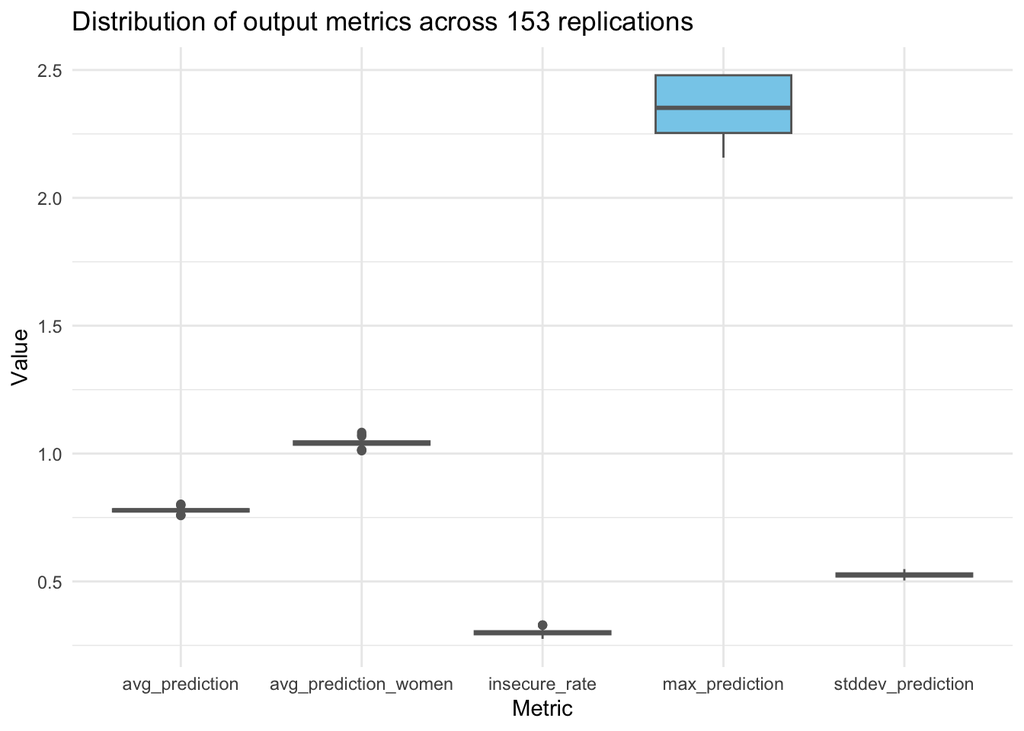

```r
stoch <- read.csv("Thesis GAMA/models/Results/stochanalysis.csv", sep = ";")


# Visualizar distribuciones con boxplots
stoch_long <- stoch %>%
  dplyr::select(-X) |>
  pivot_longer(cols = everything(), names_to = "variable", values_to = "value")

ggplot(stoch_long, aes(x = variable, y = value)) +
  geom_boxplot(fill = "skyblue", color = "gray40") +
  theme_minimal() +
  labs(title = "Distribution of output metrics across 153 replications",
       x = "Metric", y = "Value")
```

```r
# Calcular media, sd e IC al 95% para cada métrica
stoch_summary <- stoch_long %>%
  group_by(variable) %>%
  summarise(
    mean = mean(value),
    sd = sd(value),
    n = n(),
    se = sd / sqrt(n),
    CI_lower = mean - 1.96 * se,
    CI_upper = mean + 1.96 * se
  )

print(stoch_summary)
```

```
## # A tibble: 5 × 7
##   variable              mean      sd     n       se CI_lower CI_upper
##   <chr>                <dbl>   <dbl> <int>    <dbl>    <dbl>    <dbl>
## 1 avg_prediction       0.778 0.00756   153 0.000611    0.777    0.780
## 2 avg_prediction_women 1.04  0.0122    153 0.000985    1.04     1.04
## 3 insecure_rate        0.300 0.0117    153 0.000948    0.298    0.302
## 4 max_prediction       2.36  0.121     153 0.00977     2.34     2.38
## 5 stddev_prediction    0.525 0.00842   153 0.000681    0.524    0.527
```

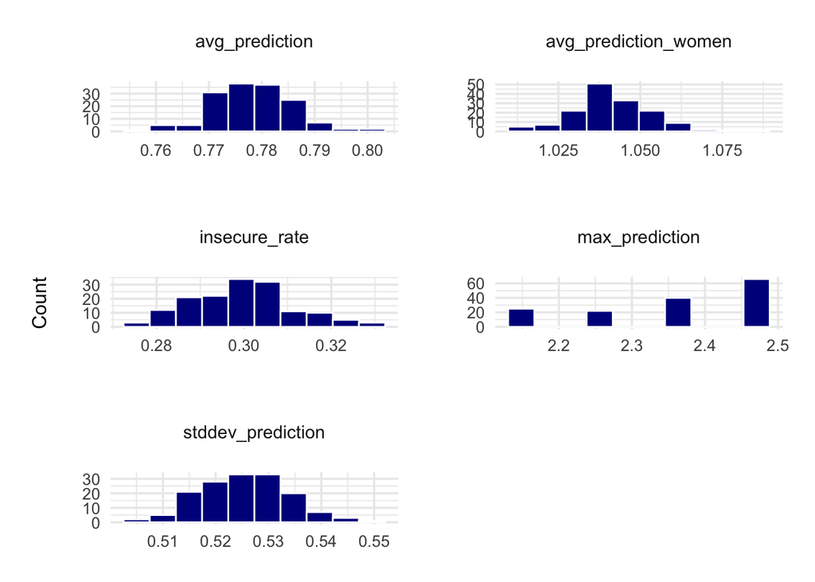

```r
# Suponiendo que tu dataframe se llama `stoch` y tiene una fila por repetición
df_long_hist <- stoch %>%
    dplyr::select(-X) |>
  pivot_longer(
    cols = everything(),
    names_to = "metric",
    values_to = "value"
  )
ggplot(df_long_hist, aes(x = value)) +
  geom_histogram(bins = 10, fill = "darkblue", color = "white") +
  facet_wrap(~ metric, scales = "free", nrow = 3, ncol = 2) +
  labs(x = NULL, y = "Count") +
  theme_minimal(base_size = 14) +
  theme(
    plot.margin = margin(t = 20, r = 20, b = 20, l = 20),
    strip.text = element_text(margin = margin(b = 20)),
    panel.spacing = unit(1.5, "cm"),
    axis.title.y = element_text(size = 12, margin = margin(r =20)),
    axis.title.x = element_text(size = 12, margin = margin(t = 20)),
    axis.text.x = element_text(size = 10),
    axis.text.y = element_text(size = 10))
```

Each panel shows the evolution of the cumulative mean for a specific output. The vertical red line indicates the 80th replication, after which all variables show minimal variation, suggesting convergence.

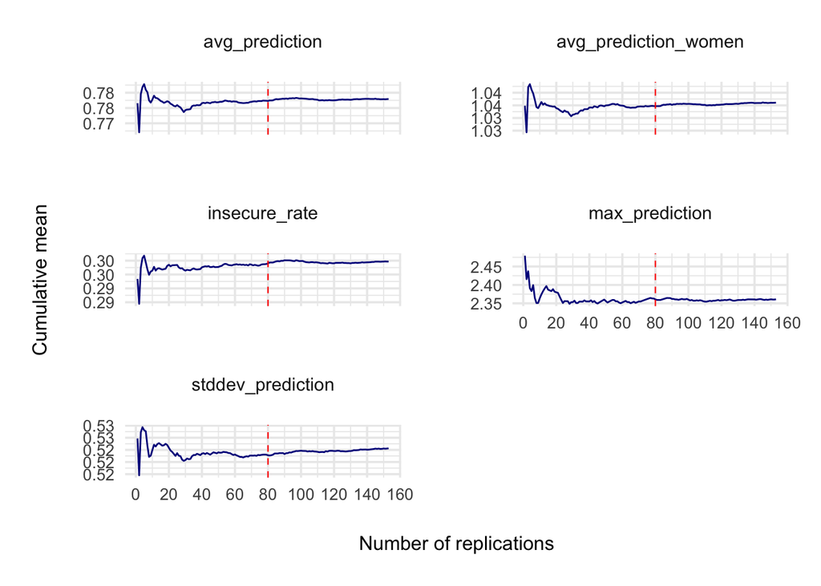

```r
# Suponiendo que tu data frame se llama `df` y no incluye la columna 'X'
df_long <- stoch %>%
  dplyr::select(-X) |>
  mutate(replication = row_number()) %>%  # crea columna con el número de réplica
  pivot_longer(cols = -replication, names_to = "metric", values_to = "value") %>%
  group_by(metric) %>%
  mutate(cum_mean = cummean(value))  # calcula la media acumulada por métrica

ggplot(df_long, aes(x = replication, y = cum_mean)) +
  geom_line(color = "darkblue") +
    geom_vline(xintercept = 80, color = "red", linetype = "dashed", linewidth = 0.4) +  # línea roja vertical

  facet_wrap(~ metric, nrow = 3, ncol = 2, scales = "free_y") +
  scale_x_continuous(breaks = seq(0, 160, 20)) +
  scale_y_continuous(labels = scales::number_format(accuracy = 0.01)) +
  labs(
    x = "Number of replications",
    y = "Cumulative mean"
  ) +
  theme_minimal(base_size = 14) +
  theme(
    plot.margin = margin(t = 20, r = 20, b = 20, l = 20),
    strip.text = element_text(margin = margin(b = 20)),
    panel.spacing = unit(1.5, "cm"),  # aquí sí verás el cambio
    axis.title.y = element_text(size = 12, margin = margin(r =20)),
    axis.title.x = element_text(size = 12, margin = margin(t = 20)),
    axis.text.x = element_text(size = 10),
    axis.text.y = element_text(size = 10))
```

# SENSITIVITY ANALYSIS

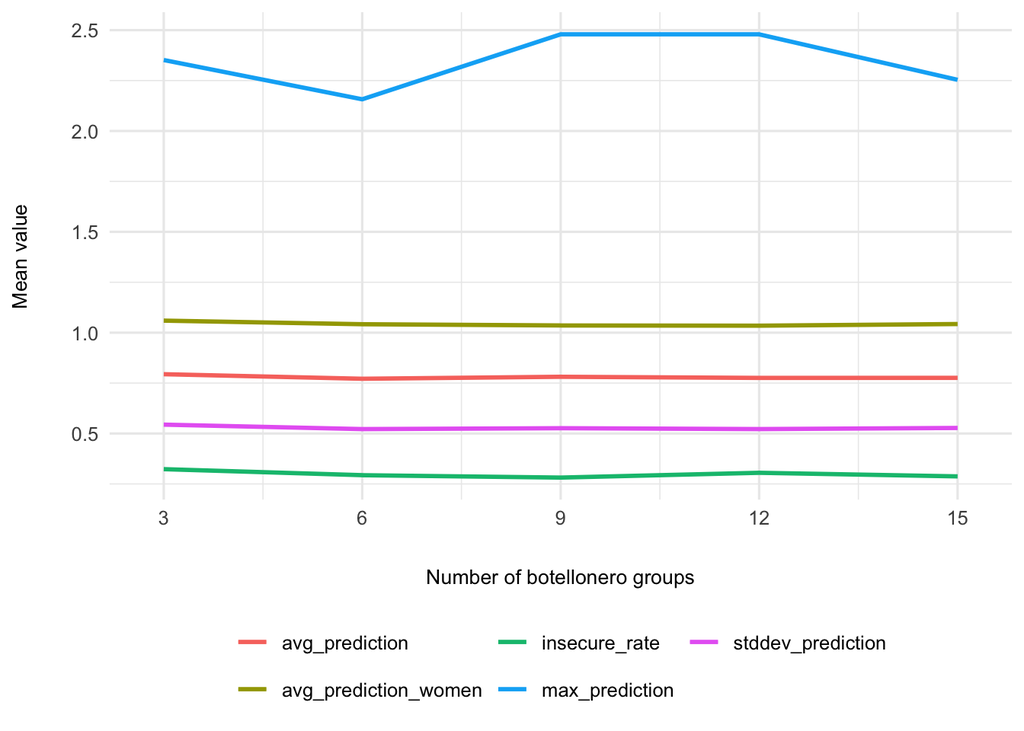

```r
bot0 <- read.csv("Thesis GAMA/models/sens_botellon_summary0.csv")
bot1 <- read.csv("Thesis GAMA/models/sens_botellon_summary1.csv")
bot2 <- read.csv("Thesis GAMA/models/sens_botellon_summary2.csv")
bot3 <- read.csv("Thesis GAMA/models/sens_botellon_summary3.csv")
bot4 <- read.csv("Thesis GAMA/models/sens_botellon_summary4.csv")

bot <- bind_rows(bot0, bot1, bot2, bot3, bot4)

# Renombrar columnas si es necesario
colnames(bot) <- c("nb_grupos_botellon", "insecure_rate", "avg_prediction", "stddev_prediction", "max_prediction", "avg_prediction_women")

# Transformar a formato largo
bot <- pivot_longer(
  bot,
  cols = -nb_grupos_botellon,
  names_to = "variable",
  values_to = "value"
)

# Gráfico combinado con todas las métricas
ggplot(bot, aes(x = nb_grupos_botellon, y = value, color = variable)) +
  stat_summary(fun = mean, geom = "line", size = 1) +
  stat_summary(fun.data = mean_cl_normal, geom = "errorbar", width = 0.4, alpha = 0.4) +
  scale_y_continuous(breaks = seq(0, 3.5, by = 0.5)) +
  scale_x_continuous(breaks = seq(0, 15, by = 3)) +
  labs(
    x = "Number of botellonero groups",
    y = "Mean value",
    color = NULL) +
  theme_minimal(base_size = 12) +
  theme(
  legend.position = "bottom",
  legend.box = "horizontal",
  axis.title.x = element_text(size = 10, margin = margin(t = 20)),
  axis.title.y = element_text(size = 10, margin = margin(r = 20))

) +
guides(color = guide_legend(nrow = 2))
```

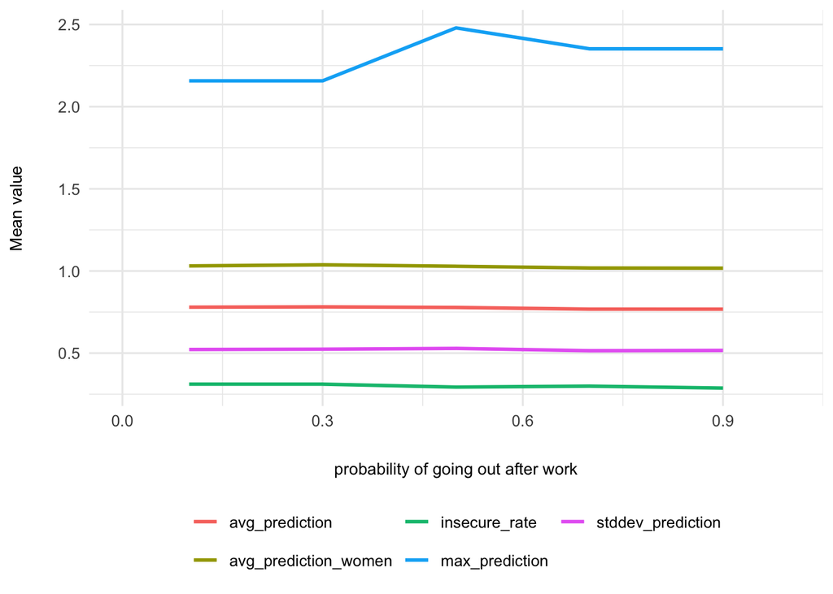

```r
ocio0 <- read.csv("Thesis GAMA/models/sens_ocio_summary0.csv")
ocio1 <- read.csv("Thesis GAMA/models/sens_ocio_summary1.csv")
ocio2 <- read.csv("Thesis GAMA/models/sens_ocio_summary2.csv")
ocio3 <- read.csv("Thesis GAMA/models/sens_ocio_summary3.csv")
ocio4 <- read.csv("Thesis GAMA/models/sens_ocio_summary4.csv")

ocio <- bind_rows(ocio0, ocio1, ocio2, ocio3, ocio4)

# Renombrar columnas si es necesario
colnames(ocio) <- c("probabilidad_ocio_fuera", "insecure_rate", "avg_prediction", "stddev_prediction", "max_prediction", "avg_prediction_women")

# Transformar a formato largo
ocio <- pivot_longer(
  ocio,
  cols = -probabilidad_ocio_fuera,
  names_to = "variable",
  values_to = "value"
)

# Gráfico combinado con todas las métricas
ggplot(ocio, aes(x = probabilidad_ocio_fuera, y = value, color = variable)) +
  stat_summary(fun = mean, geom = "line", size = 1) +
  stat_summary(fun.data = mean_cl_normal, geom = "errorbar", width = 0.4, alpha = 0.4) +
  scale_y_continuous(breaks = seq(0, 3.5, by = 0.5)) +
  scale_x_continuous(breaks = seq(0, 0.9, by = 0.3),  limits = c(0, 1)) +
  labs(
    x = "probability of going out after work",
    y = "Mean value",
    color = NULL) +
  theme_minimal(base_size = 12) +
  theme(
  legend.position = "bottom",
  legend.box = "horizontal",
  axis.title.x = element_text(size = 10, margin = margin(t = 20)),
  axis.title.y = element_text(size = 10, margin = margin(r = 20))

) +
guides(color = guide_legend(nrow = 2))
```